# FarmHack 2023: Crushable Depth

**Capstone Project, CSE 9099**

## Table of Contents:

1. Introduction  
   1.1 PostgreSQL Database  
   1.2 Python Connection  
   1.3 Hardware  
   1.4 Quick Reference: Project Structure
2. Libraries and Setup
3. Iterative Imputation  
   3.1 Imputation Test  
   3.2 Database Push Test  
   3.3 Full Imputation  
   3.4 Training Data Imputation  
   3.5 Testing Data Imputation
4. Problem Deep Dive  
   4.1 Methods for Multiple Multivariate Time Series Forecasting  
   4.2 DeepAR: Probabilistic Forecasting with Autoregressive Recurrent Networks  
   4.3 Probabilistic Demand Forecasting at Scale  
   4.4 Deep Space State Models for Time Series Forecasting  
   4.5 Deep Transformer Models for Time Series Forecasting: The Influenza Prevalence Case  
   4.6 Detour: The Current State of Our Plan  
   4.7 Temporal Fusion Transformers for Interpretable Multi-horizon Time Series Forecasting  
   4.8 Further Readings
5. Practical Limitations of Forecasting with the Temporal Fusion Transformer  
   5.1 PyTorch Forecasting: Encoders Issue  
   5.2 PyTorch Forecasting: Base Model Issue  
   5.3 PyTorch Forecasting: NaNLabelEncoder() Necessity  
   5.4 PyTorch Forecasting: Target Presence within Test  
   5.5 Data Extraction and Modelling  
   5.6 GPU Limitations  
   5.7 GPU Training Speeds
6. Training the TFT  
   6.1 Utility Functions: Data Fetch  
   6.2 Utility Functions: Model Initialisation  
   6.3 Utility Functions: Model Inspection  
   6.4 Setup: Database Loop  
   6.5 TFT Training Loop
7. Forecasting with the TFT  
   7.1 Utility Functions: Test Data Fetch  
   7.2 Prediction Loop  
   7.3 De-duplicating Test Farms  
   7.4 Final Predictions Merge
8. Concluding Thoughts
9. Future Scope and Recommendations  
   9.1 Iterable Streaming Dataset  
   9.2 Time Series Dissection: Clustering, Classification, Seasonality and Outlier Detection  
   9.3 Dynamic Time Warping  
   9.4 Longest Common Subsequences  
   9.5 Singular Value Similarity  
   9.6 Seasonality

## Introduction

A new fast food chain has been witnessing rapid expansion over the past couple of years. They are now trying to optimise their supply chain to ensure that there is no shortage of ingredients. For this, they’ve tasked their data science team to come up with a model of their current pipeline that could predict the output of each food processing farm over the next few years. These predictions could further increase the efficiency of their current supply chain management systems. As a member of the data scientist team, you are expected to utilise your skills at machine learning to predict the output of the food processing farms for the next year. Facilitating this are 5 datasets that the company has provided access to you for:

- `train_data.csv`, which contains the time series of each food processing farm along with that farm's ID, the ingredient type they are producing, and the yield in tonnes.
- `farm_data.csv`, which contains the farm's ID, its year of founding and incorporation, the number of processing plants it has, the area of the farm (in $m^2$), the farm's parent company, and the farm's geographical location that has been anonymised.
- `train_weather.csv`, which contains a time series of the weather at each farm from its location.

The other two datasets are `test_data.csv` and `test_weather.csv`. Right off the bat we can see that we have a multivariate time series modelling task on our hands, the difference from a normal version of this problem is the fact that we have *multiple* different time series to deal with in a multivariate fashion. The problem is therefore very involved, and the datasets are relatively large (combined, they size up to over 2GB). Keeping this in mind, the way the entire pipeline for this project has been structured is as follows:

[figure not shown]

*FarmHack 2023 Data Pipeline*

### PostgreSQL Database

Owing to the size of the datasets, the iterative fashion of data wrangling, the necessity of joins, and the requirements that all of all this data management remain consistently and easily accessible, the decision was taken to setup a PostgreSQL database to store the datasets and manipulate them in a much, much easier fashion than through pure Python. The advantages of this method include, but are not limited to:

- Direct database-style operations and querying.
- Complete freedom from in-memory operations since databases are stored on disk.
- Parallel operations with introspective query plans (contrasted against the GIL).
- Extremely structured, straightforward and understandable approach to data management.
- Dataset indexing for slightly increased performance during filter operations.
- Very easy to prepare data for more advanced analytics and modelling.

The success, benefits and implications of this decision cannot be overstated. 90% of the entire data wrangling pipeline, from inspection through to data preparation for modelling was carried out purely in the PostgreSQL database, with the exception of advanced missing data imputation and the final modelling. The accompanying SQL script file along with a backup of the database (with reserved permissions) is contained within the archive this notebook should exist in. Finally, the database was stored on one highly capable and performant NVMe SSD.

### Python Connection

Of course, not all operations could be carried out directly within the database for two reasons:

- Although PostgreSQL ships with native support for direct within-database programming via C and procedural support via PL/Python, pointing the Python interpreter used to the one installed via Mamba was more work than necessary for the project.
- Point (1) notwithstanding, using Python directly within the database - especially for ML/AI purposes - is a surefire way to completely shred the transistors on a storage device due to the repeated iterations involved. Such algorithms perform better when run from memory.

Therefore, the Python-PostgreSQL connector Psycopg2 was used to associate this Python session with the database instance to facilitate the absolute bare minimum amount of memory involvement. When an advanced operation was required, the database was connected to via Psycopg2 and queries were run that fetched only the bare minimum appropriate amount of data relevant to the job at hand. In most cases this was done iteratively, looping through different reasons for access; and functionally, so that the dataframe object doesn't have too long of a shelf life in-memory. The chosen workflow proved to be quite supportive of what the project required and might also be scalable to larger individual projects of similar natures.

### Hardware

While this kind of an approach is reproducible on a laptop, the speed of opereations are far from acceptable for obvious reasons. The hardware involved also matters, and in this case the computer is a personal desktop machine, custom-built and upgraded by hand very lovingly and passionately over years. The quick reference specifications are as follows:

| Component | Description |
| --- | --- |
| CPU | AMD Ryzen 5 5600X |
| GPU | AMD RX 6600 |
| Baseboard | ASUS Prime B550M-A |
| RAM | 48GB DDR4 3200MT/s |
| OS | Arch Linux 6.1.12 |
| Storage | 5.5GB NVMe + SSD + HDD |

[figure not shown]

*Operational Hardware, Built not Bought*

More information along with a detailed breakdown of system components and package environments should have accompanied this notebook under a folder named `sysinfo`. Additionally, anticipating this question in advance: the first incarnation of this build came around in 2013, and yes, the oldest surviving component in the build is the PSU.

### Quick Reference: Notebook Structure

The structure that this notebook has assumed begins with a section on null imputation, where we introduce the idea of iterating over a query loop, pulling out the minimum necessary data from the database, then imputing any missing values. This is then followed by a section on a deep dive into the practicalities of our problem at hand and a review of the research done for such kinds of projects. Finally, the notebook ends with a section on data modelling with ML/AI techniques. Each section involves multiple links to various other resources referred to during that section's progression. Inline links are usually news articles, contextual or concluding thoughts on a certain problem and are not very long reads. Aggregated sources and references that follow a section heading are resources that were extensively referred to and researched for that section, and usually also contain information on the implications of certain decisions that contribute to the overall project.

Some final thoughts: this notebook is text-heavy. The only reason is because most of the heavy lifting of data wrangling was performed directly in the PostgreSQL database; the associated SQL script file has also been sufficiently commented in order to maintain a coherent flow of thought and work. Additionally, it's very important to note that the GPU this notebook uses is not officially supported to AMD; binaries for AMD's HPC libraries had to be compiled from source. There are also a few source Python scripts for Pytorch that had to be edited due to obsolesence, and which should be included as a part of the archive. In conclusion, this project was 100% enjoyable and worth doing all over again from scratch! Let's get to it.

Sources:

- [PostgreSQL](https://www.postgresql.org/)
- [PsycoPG](https://www.psycopg.org/docs/)
- [Phoronix: AMD Ryzen 5 5600X](https://www.phoronix.com/review/amd-ryzen-5600x)
- [Phoronix: AMD RDNA2 RX 6600](https://www.phoronix.com/review/radeon-rx6600-linux)
- [AMD: Radeon Open Compute (ROCm) Solutions](https://www.amd.com/en/graphics/servers-solutions-rocm)
- [Arch Linux](https://archlinux.org/)
- [Arch Linux: ROCm-Arch](https://github.com/rocm-arch/rocm-arch)
- [Mesa3D Graphics Drivers](https://mesa3d.org/)
- [Mamba Documentation](https://mamba.readthedocs.io/en/latest/)
- [Pytorch](https://pytorch.org/)
- [Pytorch-ROCm](https://pytorch.org/blog/pytorch-for-amd-rocm-platform-now-available-as-python-package/)
- [Pytorch Lightning](https://www.pytorchlightning.ai/)
- [Pytorch Forecasting](https://pytorch-forecasting.readthedocs.io/en/stable/)
- [Scikit-Learn](https://scikit-learn.org/stable/index.html)

*Rahul Singh, February 2023.*

# Libraries and Setup

(Back to top)

A small note: this notebook is being run after updating NumPy, which follows a week after [Intel publishing a new AVX-512 sorting library](https://github.com/intel/x86-simd-sort) and [NumPy switching to it for 10~17x faster sorts](https://github.com/numpy/numpy/pull/22315/). Further reading [at Phoronix](https://www.phoronix.com/news/Intel-AVX-512-Quicksort-Numpy). Additionally, the following environment variables need to be set *before* the Python kernel is launched: `export HSA_OVERRIDE_GFX_VERSION=10.3.0`, since this is [post-ROCm](https://pytorch.org/blog/pytorch-for-amd-rocm-platform-now-available-as-python-package/) and we're using RDNA2, so we need to have ensured that bash is aware of this. The specific version required for the GPU generation can be gleaned from `rocminfo` or `clinfo`, especially if the card is detected by AMD utilities, since Pytorch simply interfaces with them.

```python
# general imports
import itertools
import matplotlib.pyplot as plt
import numpy as np
import pandas as pd
import warnings

from itertools import cycle, islice

# database utilities
import psycopg2
import psycopg2.extras as extras

# pytorch neural net utilities
import pytorch_lightning as pl
import torch

from pytorch_forecasting import (
    Baseline, TemporalFusionTransformer, TimeSeriesDataSet
)
from pytorch_forecasting.data import GroupNormalizer, NaNLabelEncoder
from pytorch_forecasting.metrics import RMSE
from pytorch_lightning.callbacks import EarlyStopping

# scikit-learn traditional models
from sklearn.experimental import enable_iterative_imputer
from sklearn.impute import IterativeImputer

# postgresql db connection
pq = psycopg2.connect("CONNECTION STRING")
cur = pq.cursor()
cur.execute("set max_parallel_workers_per_gather = 10;")

# pytorch setup
pl.seed_everything(1337, workers = True)
torch.set_float32_matmul_precision("medium")

# miscellaneous preparation
warnings.filterwarnings("ignore")
torch.cuda.is_available()
```

```
Global seed set to 1337
```

```
True
```

# Iterative Imputation

(Back to top)  
This section coincides with parts 4 and 5 of the associated SQL script.

The goal here is to test, on a small representation of the entire dataset we have, the effects of iteratively imputing null values using an expectation-maximisation algorithm supplemented with Bayesian regression. The way EM works is - very generally - we have a given probability distribution of data but no knowledge of what the data represents in terms of its *labels*; in our case, we have missing values and we have no idea what they are, but we do have other data surrounding those points that we can use to *infer* what those values could be *given* a certain value. The way we infer this is usually Bayesian, and is based on the assumption that the source distribution of our data is a Gaussian:  
$P(b | x_{i}) = \frac{P(x_{i} | b) \times P(b)}{P(x_{i} | b) \times P(b) + P(x_{i} | a) \times P(a)} \implies P(x_{i} | b) = \frac{1}{\sqrt{2 \pi \sigma_{b}^{2}}} \exp \lbrace -\frac{(x_{i} - \mu)^{2}}{2 \sigma_{b}^{2}} \rbrace$

What all of that math means is given a certain value $x_{i}$, we can identify what label it belongs to (or how much of an appropriate fit it is for a certain probability) by comparing it against the mean of the distribution we've already been given. What the Iterative Imputer is going to do (and what most EM imputation algorithms do, even the wicked-cool SVD one) is it's first going to fill nulls in a column with the column's mean, then regress one column against the others to obtain most "expected" values of the nulls in that column. It will replace the mean-imputed values with these new predicted values and proceed onto the next feature that was null, continuing in a round robin fashion until convergence is achieved or the maximum number of iterations has been reached. It's actually a really cool approach to imputation.

Sources:

- [Julia's Impute.jl; section SVD.](https://invenia.github.io/Impute.jl/latest/api/imputation/#SV)
- [Scikit-Learn's IterativeImputer.](https://scikit-learn.org/stable/modules/impute.html#iterative-imputer)
- [Wikipedia: Expectation-Maximisation Algorithm; section Description.](https://en.wikipedia.org/wiki/Expectation%E2%80%93maximization_algorithm#Description)
- [EM.2 - Expectation-Maximisation Algorithm, Victor Lavrenko (YouTube, 5 minutes).](https://www.youtube.com/watch?v=-mYQ-nbykCo&list=PLBv09BD7ez_7beI0_fuE96lSbsr_8K8YD)
- [EM Algorithm with Example, Varunakshi Bhojane (Youtube, 12 minutes).](https://www.youtube.com/watch?v=2qxM-i506GQ)
- Troyanskaya, Olga, et al. "Missing value estimation methods for DNA microarrays." Bioinformatics 17.6 (2001): 520-525.Troyanskaya, Olga, et al. "Missing value estimation methods for DNA microarrays." Bioinformatics 17.6 (2001): 520-525.
- Stef van Buuren, Karin Groothuis-Oudshoorn (2011). “mice: Multivariate Imputation by Chained Equations in R”. Journal of Statistical Software 45: 1-67.Stef van Buuren, Karin Groothuis-Oudshoorn (2011). “mice: Multivariate Imputation by Chained Equations in R”. Journal of Statistical Software 45: 1-67.

## Imputation Test

(Back to top)  
We'll start with a small, controlled set of data before expanding our operation into a loop over all locations we have. The way we script our code here will dictate how our future pipeline will turn out when we expand this over all locations, because a lot of copy/pasting will be involved. Like we noted in the SQL file, the most ideal solution here would have been to perform all of this directly within the database itself via PL/Python, which we also tried to do. Unfortunately, Postgres ships with its own Python interpreter that, if we want to change and point to Mamba's Python environment, would require an entire recompile of Postgres due to the single line change in a core configuration file. While computationally cheap for us, it's not temporally cheap. Importing `pandas` or `numpy` into the database directly is therefore not possible within the constraints of this problem, so we're doing it here.

Sources:

- [SO: PL/Python with Anaconda](https://stackoverflow.com/a/32029994)
- [SO: How to change the Python version used by PL/Python on MAC OSX?](https://stackoverflow.com/q/5921664)

```python
cur.execute("""
    SELECT
        date, farm_id, ingredient_type, farming_company, deidentified_location,
        temp_obs, cloudiness, wind_direction, dew_temp, pressure_sea_level,
        precipitation, wind_speed
    FROM grand_merge
    WHERE
        ingredient_type = 'ing_z' and
        deidentified_location = 'location 5410';
""")

dfz = pd.DataFrame(cur.fetchall(), columns = [d[0] for d in cur.description])
dfz
```

|  | date | farm_id | ingredient_type | farming_company | deidentified_location | temp_obs | cloudiness | wind_direction | dew_temp | pressure_sea_level | precipitation | wind_speed |
| --- | --- | --- | --- | --- | --- | --- | --- | --- | --- | --- | --- | --- |
| 0 | 2016-08-29 14:00:00 | fid_100952 | ing_z | Wayne Farms | location 5410 | 27.8 | 0.0 | 340.0 | 19.4 | 1020.0 | 0.0 | 3.1 |
| 1 | 2016-08-29 15:00:00 | fid_100952 | ing_z | Wayne Farms | location 5410 | 29.4 | 0.0 | 340.0 | 20.0 | 1019.7 | 0.0 | 3.6 |
| 2 | 2016-08-29 16:00:00 | fid_100952 | ing_z | Wayne Farms | location 5410 | 30.6 | 0.0 | 350.0 | 20.0 | 1019.2 | 0.0 | 3.6 |
| 3 | 2016-08-29 17:00:00 | fid_100952 | ing_z | Wayne Farms | location 5410 | 31.1 | 2.0 | 320.0 | 20.0 | 1018.9 | 0.0 | 2.6 |
| 4 | 2016-08-29 18:00:00 | fid_100952 | ing_z | Wayne Farms | location 5410 | 32.2 | 4.0 | NaN | 20.0 | 1018.6 | 0.0 | 3.1 |
| ... | ... | ... | ... | ... | ... | ... | ... | ... | ... | ... | ... | ... |
| 487496 | 2016-12-31 19:00:00 | fid_88637 | ing_z | Obery Farms | location 5410 | 6.7 | 0.0 | 200.0 | -8.3 | 1015.8 | 0.0 | 6.7 |
| 487497 | 2016-12-31 20:00:00 | fid_88637 | ing_z | Obery Farms | location 5410 | 5.6 | 4.0 | 200.0 | -6.7 | 1015.3 | 0.0 | 5.7 |
| 487498 | 2016-12-31 21:00:00 | fid_88637 | ing_z | Obery Farms | location 5410 | 5.6 | NaN | 190.0 | -6.7 | 1014.9 | 0.0 | 5.7 |
| 487499 | 2016-12-31 22:00:00 | fid_88637 | ing_z | Obery Farms | location 5410 | 5.6 | NaN | 190.0 | -6.7 | 1014.0 | 0.0 | 6.7 |
| 487500 | 2016-12-31 23:00:00 | fid_88637 | ing_z | Obery Farms | location 5410 | 6.1 | NaN | 190.0 | -6.7 | 1012.4 | -1.0 | 9.8 |

487501 rows × 12 columns

```python
dfz.dtypes
```

```
date                     datetime64[ns]
farm_id                          object
ingredient_type                  object
farming_company                  object
deidentified_location            object
temp_obs                        float64
cloudiness                      float64
wind_direction                  float64
dew_temp                        float64
pressure_sea_level              float64
precipitation                   float64
wind_speed                      float64
dtype: object
```

Looks good. Remember we're only imputing weather.

```python
weather_cols = [
    "temp_obs", "wind_direction", "dew_temp", "pressure_sea_level",
    "precipitation", "wind_speed"
]

imp_df = dfz[weather_cols]
imp_df = imp_df.iloc[:, ~imp_df.isnull().all(axis = "rows").values]
imp_df
```

|  | temp_obs | wind_direction | dew_temp | pressure_sea_level | precipitation | wind_speed |
| --- | --- | --- | --- | --- | --- | --- |
| 0 | 27.8 | 340.0 | 19.4 | 1020.0 | 0.0 | 3.1 |
| 1 | 29.4 | 340.0 | 20.0 | 1019.7 | 0.0 | 3.6 |
| 2 | 30.6 | 350.0 | 20.0 | 1019.2 | 0.0 | 3.6 |
| 3 | 31.1 | 320.0 | 20.0 | 1018.9 | 0.0 | 2.6 |
| 4 | 32.2 | NaN | 20.0 | 1018.6 | 0.0 | 3.1 |
| ... | ... | ... | ... | ... | ... | ... |
| 487496 | 6.7 | 200.0 | -8.3 | 1015.8 | 0.0 | 6.7 |
| 487497 | 5.6 | 200.0 | -6.7 | 1015.3 | 0.0 | 5.7 |
| 487498 | 5.6 | 190.0 | -6.7 | 1014.9 | 0.0 | 5.7 |
| 487499 | 5.6 | 190.0 | -6.7 | 1014.0 | 0.0 | 6.7 |
| 487500 | 6.1 | 190.0 | -6.7 | 1012.4 | -1.0 | 9.8 |

487501 rows × 6 columns

```python
iimp = IterativeImputer(
    imputation_order = "descending",
    verbose = 1,
    random_state = 1337,
    min_value = list(imp_df.min(axis = "rows").values),
    max_value = list(imp_df.max(axis = "rows").values)
)

imp_df = pd.DataFrame(
    iimp.fit_transform(imp_df),
    columns = imp_df.columns
)
imp_df
```

```
[IterativeImputer] Completing matrix with shape (487501, 6)
[IterativeImputer] Change: 76.50865114269823, scaled tolerance: 1.0403
[IterativeImputer] Change: 29.437658010039286, scaled tolerance: 1.0403
[IterativeImputer] Change: 3.029204593215809, scaled tolerance: 1.0403
[IterativeImputer] Change: 0.3117385466439515, scaled tolerance: 1.0403
[IterativeImputer] Early stopping criterion reached.
```

|  | temp_obs | wind_direction | dew_temp | pressure_sea_level | precipitation | wind_speed |
| --- | --- | --- | --- | --- | --- | --- |
| 0 | 27.8 | 340.00000 | 19.4 | 1020.0 | 0.0 | 3.1 |
| 1 | 29.4 | 340.00000 | 20.0 | 1019.7 | 0.0 | 3.6 |
| 2 | 30.6 | 350.00000 | 20.0 | 1019.2 | 0.0 | 3.6 |
| 3 | 31.1 | 320.00000 | 20.0 | 1018.9 | 0.0 | 2.6 |
| 4 | 32.2 | 190.98587 | 20.0 | 1018.6 | 0.0 | 3.1 |
| ... | ... | ... | ... | ... | ... | ... |
| 487496 | 6.7 | 200.00000 | -8.3 | 1015.8 | 0.0 | 6.7 |
| 487497 | 5.6 | 200.00000 | -6.7 | 1015.3 | 0.0 | 5.7 |
| 487498 | 5.6 | 190.00000 | -6.7 | 1014.9 | 0.0 | 5.7 |
| 487499 | 5.6 | 190.00000 | -6.7 | 1014.0 | 0.0 | 6.7 |
| 487500 | 6.1 | 190.00000 | -6.7 | 1012.4 | -1.0 | 9.8 |

487501 rows × 6 columns

```python
pd.DataFrame(
    {
        "org_unq": dfz[imp_df.columns].nunique(),
        "imp_unq": imp_df.nunique(),
        "imp_max": imp_df.min(axis = "rows"),
        "imp_min": imp_df.max(axis = "rows")
    }
)
```

|  | org_unq | imp_unq | imp_max | imp_min |
| --- | --- | --- | --- | --- |
| temp_obs | 93 | 95 | -15.6 | 35.6 |
| wind_direction | 38 | 328 | 0.0 | 360.0 |
| dew_temp | 93 | 95 | -25.6 | 25.6 |
| pressure_sea_level | 453 | 563 | 989.6 | 1040.3 |
| precipitation | 45 | 77 | -1.0 | 150.0 |
| wind_speed | 25 | 49 | 0.0 | 13.4 |

Incredible, variance was preserved in a much more reasonable fashion. The reason we wanted a smaller decision space was because in our first attempt with this regressor, climate variability was completely destroyed (i.e. it blew up). For example, `location 5410` before imputing had the following statistics, where `d_*` refers to the number of distinct values for that feature vector (also represented as a % of total):

| val/col | total rows | d_temp | d_cloud | d_wdir | d_dew | d_psl | d_precip | d_wspd |
| --- | --- | --- | --- | --- | --- | --- | --- | --- |
| measure | $2527817$ | $93$ | $4$ | $38$ | $93$ | $453$ | $45$ | $25$ |
| % total | $100%$ | $0.00%$ | $0.00%$ | $0.00%$ | $0.00%$ | $0.02%$ | $0.00%$ | $0.00%$ |

We can clearly see the lack of variation across all the farms - every farm reporting from this location reports almost the same weather as every other farm, across all times of the day. Contrasted against the previous attempt's result, which was borderline within acceptable ranges, the newer approach is much, much cleaner. Interestingly enough, if we compare this regressor's performance against Julia's EM-SVD algorithm, we should notice that having only weather columns in play seriously narrows down the range of values we can end up with. Clearly weather interactions are being accounted for both ways. Now let's reappend our missing columns, fill forward `cloudiness` and move onto looping over this approach.

```python
order = dfz.columns
dfz = dfz.drop(imp_df.columns, axis = "columns")
dfz = pd.concat([dfz, imp_df], axis = "columns")
dfz = dfz.reindex(columns = order)
dfz
```

|  | date | farm_id | ingredient_type | farming_company | deidentified_location | temp_obs | cloudiness | wind_direction | dew_temp | pressure_sea_level | precipitation | wind_speed |
| --- | --- | --- | --- | --- | --- | --- | --- | --- | --- | --- | --- | --- |
| 0 | 2016-08-29 14:00:00 | fid_100952 | ing_z | Wayne Farms | location 5410 | 27.8 | 0.0 | 340.00000 | 19.4 | 1020.0 | 0.0 | 3.1 |
| 1 | 2016-08-29 15:00:00 | fid_100952 | ing_z | Wayne Farms | location 5410 | 29.4 | 0.0 | 340.00000 | 20.0 | 1019.7 | 0.0 | 3.6 |
| 2 | 2016-08-29 16:00:00 | fid_100952 | ing_z | Wayne Farms | location 5410 | 30.6 | 0.0 | 350.00000 | 20.0 | 1019.2 | 0.0 | 3.6 |
| 3 | 2016-08-29 17:00:00 | fid_100952 | ing_z | Wayne Farms | location 5410 | 31.1 | 2.0 | 320.00000 | 20.0 | 1018.9 | 0.0 | 2.6 |
| 4 | 2016-08-29 18:00:00 | fid_100952 | ing_z | Wayne Farms | location 5410 | 32.2 | 4.0 | 190.98587 | 20.0 | 1018.6 | 0.0 | 3.1 |
| ... | ... | ... | ... | ... | ... | ... | ... | ... | ... | ... | ... | ... |
| 487496 | 2016-12-31 19:00:00 | fid_88637 | ing_z | Obery Farms | location 5410 | 6.7 | 0.0 | 200.00000 | -8.3 | 1015.8 | 0.0 | 6.7 |
| 487497 | 2016-12-31 20:00:00 | fid_88637 | ing_z | Obery Farms | location 5410 | 5.6 | 4.0 | 200.00000 | -6.7 | 1015.3 | 0.0 | 5.7 |
| 487498 | 2016-12-31 21:00:00 | fid_88637 | ing_z | Obery Farms | location 5410 | 5.6 | NaN | 190.00000 | -6.7 | 1014.9 | 0.0 | 5.7 |
| 487499 | 2016-12-31 22:00:00 | fid_88637 | ing_z | Obery Farms | location 5410 | 5.6 | NaN | 190.00000 | -6.7 | 1014.0 | 0.0 | 6.7 |
| 487500 | 2016-12-31 23:00:00 | fid_88637 | ing_z | Obery Farms | location 5410 | 6.1 | NaN | 190.00000 | -6.7 | 1012.4 | -1.0 | 9.8 |

487501 rows × 12 columns

Why did we concatenate the smaller dataframe into the larger one? Because if we instead concatenated `dfz` onto `imp_df`, we would have two large datasets floating about in memory which we really don't need. We're going to be filling `cloudiness` here, so we ought to make sure that's the only column with missing values still remaining.

```python
dfz.isnull().sum()
```

```
date                          0
farm_id                       0
ingredient_type               0
farming_company               0
deidentified_location         0
temp_obs                      0
cloudiness               184001
wind_direction                0
dew_temp                      0
pressure_sea_level            0
precipitation                 0
wind_speed                    0
dtype: int64
```

```python
if not dfz["cloudiness"].isnull().all():
    dfz["cloudiness"].fillna(method = "ffill", inplace = True)
    dfz["cloudiness"].fillna(method = "bfill", inplace = True)

dfz
```

|  | date | farm_id | ingredient_type | farming_company | deidentified_location | temp_obs | cloudiness | wind_direction | dew_temp | pressure_sea_level | precipitation | wind_speed |
| --- | --- | --- | --- | --- | --- | --- | --- | --- | --- | --- | --- | --- |
| 0 | 2016-08-29 14:00:00 | fid_100952 | ing_z | Wayne Farms | location 5410 | 27.8 | 0.0 | 340.00000 | 19.4 | 1020.0 | 0.0 | 3.1 |
| 1 | 2016-08-29 15:00:00 | fid_100952 | ing_z | Wayne Farms | location 5410 | 29.4 | 0.0 | 340.00000 | 20.0 | 1019.7 | 0.0 | 3.6 |
| 2 | 2016-08-29 16:00:00 | fid_100952 | ing_z | Wayne Farms | location 5410 | 30.6 | 0.0 | 350.00000 | 20.0 | 1019.2 | 0.0 | 3.6 |
| 3 | 2016-08-29 17:00:00 | fid_100952 | ing_z | Wayne Farms | location 5410 | 31.1 | 2.0 | 320.00000 | 20.0 | 1018.9 | 0.0 | 2.6 |
| 4 | 2016-08-29 18:00:00 | fid_100952 | ing_z | Wayne Farms | location 5410 | 32.2 | 4.0 | 190.98587 | 20.0 | 1018.6 | 0.0 | 3.1 |
| ... | ... | ... | ... | ... | ... | ... | ... | ... | ... | ... | ... | ... |
| 487496 | 2016-12-31 19:00:00 | fid_88637 | ing_z | Obery Farms | location 5410 | 6.7 | 0.0 | 200.00000 | -8.3 | 1015.8 | 0.0 | 6.7 |
| 487497 | 2016-12-31 20:00:00 | fid_88637 | ing_z | Obery Farms | location 5410 | 5.6 | 4.0 | 200.00000 | -6.7 | 1015.3 | 0.0 | 5.7 |
| 487498 | 2016-12-31 21:00:00 | fid_88637 | ing_z | Obery Farms | location 5410 | 5.6 | 4.0 | 190.00000 | -6.7 | 1014.9 | 0.0 | 5.7 |
| 487499 | 2016-12-31 22:00:00 | fid_88637 | ing_z | Obery Farms | location 5410 | 5.6 | 4.0 | 190.00000 | -6.7 | 1014.0 | 0.0 | 6.7 |
| 487500 | 2016-12-31 23:00:00 | fid_88637 | ing_z | Obery Farms | location 5410 | 6.1 | 4.0 | 190.00000 | -6.7 | 1012.4 | -1.0 | 9.8 |

487501 rows × 12 columns

```python
dfz.isnull().sum()
```

```
date                     0
farm_id                  0
ingredient_type          0
farming_company          0
deidentified_location    0
temp_obs                 0
cloudiness               0
wind_direction           0
dew_temp                 0
pressure_sea_level       0
precipitation            0
wind_speed               0
dtype: int64
```

#### db push test

(Back to top)  
We need to get our order of operations right when pushing our imputed data to the database. If we can address replacing the necessary rows from within Python, it would be quite easy to loop over what needs to be done without needing to fall back to SQL. Again, PL/Python would have been a lifesaver if we could have used our Mamba repository instead of Postgres' standard Python. Finally, obviously all operations are going to be atomic.

```python
cur.execute("begin;")
```

```python
cur.execute("""
    create temporary table feed on commit drop as
        select *
        from grand_merge
        with no data;
""")
```

```python
vals = [tuple(x) for x in tmp_df.to_numpy()]
cols = ', '.join(list(tmp_df.columns))

extras.execute_values(
    cur,
    f"""insert into feed ({cols}) values %s""",
    vals
)
```

```python
cur.execute("select * from feed;")
pd.DataFrame(cur.fetchall())
```

|  | 0 | 1 | 2 | 3 | 4 | 5 | 6 | 7 | 8 | 9 | 10 | 11 | 12 | 13 | 14 | 15 |
| --- | --- | --- | --- | --- | --- | --- | --- | --- | --- | --- | --- | --- | --- | --- | --- | --- |
| 0 | 2016-01-01 00:00:00 | fid_100952 | ing_w | None | None | 5737.318 | Wayne Farms | location 5410 | 13.268852 | 0.0 | 187.52649 | 5.785088 | 1016.3468 | 0.746314 | 3.076287 | 60.00 |
| 1 | 2016-01-01 01:00:00 | fid_100952 | ing_w | None | None | 5737.318 | Wayne Farms | location 5410 | 5.600000 | 0.0 | 300.00000 | -0.600000 | 1019.3000 | 0.000000 | 2.600000 | 59.00 |
| 2 | 2016-01-01 02:00:00 | fid_100952 | ing_w | None | None | 5737.318 | Wayne Farms | location 5410 | 5.600000 | 4.0 | 300.00000 | -0.600000 | 1019.4000 | 0.000000 | 2.600000 | 57.00 |
| 3 | 2016-01-01 03:00:00 | fid_100952 | ing_w | None | None | 5737.318 | Wayne Farms | location 5410 | 5.600000 | 4.0 | 157.61314 | -1.100000 | 1019.4000 | 0.000000 | 1.500000 | 60.00 |
| 4 | 2016-01-01 04:00:00 | fid_100952 | ing_w | None | None | 5737.318 | Wayne Farms | location 5410 | 5.000000 | 4.0 | 290.00000 | -2.200000 | 1019.2000 | 0.000000 | 3.100000 | 57.00 |
| ... | ... | ... | ... | ... | ... | ... | ... | ... | ... | ... | ... | ... | ... | ... | ... | ... |
| 2476585 | 2016-12-31 19:00:00 | fid_88637 | ing_z | None | None | 12911.380 | Obery Farms | location 5410 | 6.700000 | 0.0 | 200.00000 | -8.300000 | 1015.8000 | 0.000000 | 6.700000 | 1126.42 |
| 2476586 | 2016-12-31 20:00:00 | fid_88637 | ing_z | None | None | 12911.380 | Obery Farms | location 5410 | 5.600000 | 4.0 | 200.00000 | -6.700000 | 1015.3000 | 0.000000 | 5.700000 | 1068.23 |
| 2476587 | 2016-12-31 21:00:00 | fid_88637 | ing_z | None | None | 12911.380 | Obery Farms | location 5410 | 5.600000 | 4.0 | 190.00000 | -6.700000 | 1014.9000 | 0.000000 | 5.700000 | 1260.10 |
| 2476588 | 2016-12-31 22:00:00 | fid_88637 | ing_z | None | None | 12911.380 | Obery Farms | location 5410 | 5.600000 | 4.0 | 190.00000 | -6.700000 | 1014.0000 | 0.000000 | 6.700000 | 1626.38 |
| 2476589 | 2016-12-31 23:00:00 | fid_88637 | ing_z | None | None | 12911.380 | Obery Farms | location 5410 | 6.100000 | 4.0 | 190.00000 | -6.700000 | 1012.4000 | -1.000000 | 9.800000 | 1309.87 |

2476590 rows × 16 columns

```python
cur.execute("savepoint teedle;")
```

```python
cur.execute(f"""
    delete from grand_impute
    where deidentified_location = 'location 5410';
""")
```

```python
cur.execute(f"""
    select * from grand_impute where deidentified_location = 'location 5410';
""")
pd.DataFrame(cur.fetchall())
```

```python
cur.execute(f"""
    insert into grand_impute select * from feed;
""")
```

```python
cur.execute(f"""
    select * from grand_impute where deidentified_location = 'location 5410';
""")
pd.DataFrame(cur.fetchall())
```

|  | 0 | 1 | 2 | 3 | 4 | 5 | 6 | 7 | 8 | 9 | 10 | 11 | 12 | 13 | 14 | 15 |
| --- | --- | --- | --- | --- | --- | --- | --- | --- | --- | --- | --- | --- | --- | --- | --- | --- |
| 0 | 2016-01-01 00:00:00 | fid_100952 | ing_w | None | None | 5737.318 | Wayne Farms | location 5410 | 13.268852 | 0.0 | 187.52649 | 5.785088 | 1016.3468 | 0.746314 | 3.076287 | 60.00 |
| 1 | 2016-01-01 01:00:00 | fid_100952 | ing_w | None | None | 5737.318 | Wayne Farms | location 5410 | 5.600000 | 0.0 | 300.00000 | -0.600000 | 1019.3000 | 0.000000 | 2.600000 | 59.00 |
| 2 | 2016-01-01 02:00:00 | fid_100952 | ing_w | None | None | 5737.318 | Wayne Farms | location 5410 | 5.600000 | 4.0 | 300.00000 | -0.600000 | 1019.4000 | 0.000000 | 2.600000 | 57.00 |
| 3 | 2016-01-01 03:00:00 | fid_100952 | ing_w | None | None | 5737.318 | Wayne Farms | location 5410 | 5.600000 | 4.0 | 157.61314 | -1.100000 | 1019.4000 | 0.000000 | 1.500000 | 60.00 |
| 4 | 2016-01-01 04:00:00 | fid_100952 | ing_w | None | None | 5737.318 | Wayne Farms | location 5410 | 5.000000 | 4.0 | 290.00000 | -2.200000 | 1019.2000 | 0.000000 | 3.100000 | 57.00 |
| ... | ... | ... | ... | ... | ... | ... | ... | ... | ... | ... | ... | ... | ... | ... | ... | ... |
| 2476585 | 2016-12-31 19:00:00 | fid_88637 | ing_z | None | None | 12911.380 | Obery Farms | location 5410 | 6.700000 | 0.0 | 200.00000 | -8.300000 | 1015.8000 | 0.000000 | 6.700000 | 1126.42 |
| 2476586 | 2016-12-31 20:00:00 | fid_88637 | ing_z | None | None | 12911.380 | Obery Farms | location 5410 | 5.600000 | 4.0 | 200.00000 | -6.700000 | 1015.3000 | 0.000000 | 5.700000 | 1068.23 |
| 2476587 | 2016-12-31 21:00:00 | fid_88637 | ing_z | None | None | 12911.380 | Obery Farms | location 5410 | 5.600000 | 4.0 | 190.00000 | -6.700000 | 1014.9000 | 0.000000 | 5.700000 | 1260.10 |
| 2476588 | 2016-12-31 22:00:00 | fid_88637 | ing_z | None | None | 12911.380 | Obery Farms | location 5410 | 5.600000 | 4.0 | 190.00000 | -6.700000 | 1014.0000 | 0.000000 | 6.700000 | 1626.38 |
| 2476589 | 2016-12-31 23:00:00 | fid_88637 | ing_z | None | None | 12911.380 | Obery Farms | location 5410 | 6.100000 | 4.0 | 190.00000 | -6.700000 | 1012.4000 | -1.000000 | 9.800000 | 1309.87 |

2476590 rows × 16 columns

```python
cur.execute("commit;")
```

```python
# cur.execute("rollback to teedle;")
cur.execute("rollback;")
```

Everything seems good to go. Let's loop over all our locations and get this thing done.

## Full Imputation

(Back to top)  
The way we structure this weighs heavily on how resource efficient we are. Just because we have copious amounts of memory and processing power available to us doesn't mean we should squander it all, on the contrary it would make the entire process much, much quicker if we streamline our consumption. To that end, we'll be doing this in a functional manner, trying to balance both execution speed and memory efficiency.

The main change we'll be making from our scripted sequence earlier is instead of using `cursor.execute()` for the main portion of our SQL query here, we'll be using `extras.execute_values()` from `Psycopg2.extras`, because [sic] *"the current implementation of `executemany()` is (using an extremely charitable understatement) not particularly performing."* The `extra` functions can be used to speed up the repeated execution of a statement against a set of parameters. By reducing the number of server roundtrips the performance can be orders of magnitude better than using `executemany()`. It's worth noting that an alternative utility which is also blazing fast is `cursor.copy_to()`, but that requires a little more nuanced memory management than what we probably need to do here.

We'll still be transacting the push by first creating a temporary table to hold our imputed dataframe, then deleting the rows in the original table and replacing them with the ones from said temporary table. This is, by far, the cleanest way to go about this whole ordeal. **Given the approach we're taking, an index should only be created on this table once we're done.**

Sources:

- [Psycopg2 Documentation; section Extras, subsection Fast Execution Helpers.](https://www.psycopg.org/docs/extras.html#fast-execution-helpers)
- [PostgreSQL Documentation; section COPY.](https://www.postgresql.org/docs/current/sql-copy.html)
- [SO: Update a Postgres Table Column from a Pandas Dataframe.](https://stackoverflow.com/a/56864146)
- [SO: Pandas Update SQL.](https://stackoverflow.com/a/40746465)
- [SO: Bulk Update Postgres Column from Python Dataframe](https://stackoverflow.com/a/39583112)
- [SO: Psycopg2 Update Multiple Rows in a Table...](https://stackoverflow.com/a/47194517)
- [SO: Psycopg2 Update Multiple Columns on Multiple Rows...](https://stackoverflow.com/a/56749395)

```python
def run_query(cursor, tables, location):
    cursor.execute(f"""
        SELECT *
        FROM {tables[0]}
        WHERE deidentified_location = '{location}';
    """)

    tmp_df = pd.DataFrame(
        cursor.fetchall(),
        columns = [titles[0] for titles in cursor.description]
    )

    return persist(
        cursor,
        impute(tmp_df),
        tables,
        location
    )
```

```python
def impute(dataframe):
    # we're only imputing weather features; `cloudiness` is handled separately.
    imp_df = dataframe[
        ["temp_obs", "wind_direction", "dew_temp", "pressure_sea_level",
        "precipitation", "wind_speed"]
    ]

    # ignore columns that are 100% null
    imp_df = imp_df.iloc[:, ~imp_df.isnull().all(axis = "rows").values]

    # init the imputer and apply; we want a result in a dataframe
    iimp = IterativeImputer(
        imputation_order = "descending",
        random_state = 1337,
        min_value = list(imp_df.min(axis = "rows").values),
        max_value = list(imp_df.max(axis = "rows").values)
    )

    imp_df = pd.DataFrame(
        iimp.fit_transform(imp_df),
        columns = imp_df.columns
    )

    # save the original dataframe's column order for reindexing; after
    # imputing, overwrite the columns in `dataframe` with the imputed ones
    orig_cols = dataframe.columns
    dataframe.drop(imp_df.columns, axis = "columns", inplace = True)
    dataframe = pd.concat([dataframe, imp_df], axis = "columns")
    dataframe = dataframe.reindex(columns = orig_cols)

    # finally, if `cloudiness` isn't completely missing, impute that too
    if not dataframe["cloudiness"].isnull().all():
        dataframe["cloudiness"].fillna(method = "ffill", inplace = True)
        dataframe["cloudiness"].fillna(method = "bfill", inplace = True)

    return dataframe
```

```python
def persist(cursor, dataframe, tables, location):
    vals = [tuple(x) for x in dataframe.to_numpy()]
    cols = ', '.join(list(dataframe.columns))
    dataframe = None

    # here we go
    cursor.execute("begin;")
    cursor.execute(f"""
        create temporary table feed on commit drop as
            select *
            from {tables[0]}
            with no data;
    """)

    extras.execute_values(
        cursor,
        f"insert into feed ({cols}) values %s",
        vals
    )
    vals = None
    cols = None

    cursor.execute(f"""
        delete from {tables[1]}
        where deidentified_location = '{location}';

        insert into {tables[1]} select * from feed;

        commit;
    """)

    print(f"committed {location} to {tables[1]}.")

    return 0
```

As for why do we have `tables` as an argument, it's because instead of hardcoding this chain of operations for one table only (`grand_merge`, which is our training data), we've generalised it a little to accomodate operating with any pair of tables we choose. This also lets us use this chain for our testing data. Remember:

- `grand_merge` ==> training dataset; spawns `grand_impute` ==> clean training dataset
- `test_merge` ==> testing dataset; spawns `test_impute` ==> clean testing dataset

Which means our calling loop will do something like `[run_query(cursor, ("grand_merge", "grand_impute"), loc) for loc in locations]`, then followed by `[run_query(cursor, ("test_merge", "test_impute"), loc) for loc in locations]`.

### Training Data Imputation

(Back to top)

```python
# before iterating over all locations, get all the locations
cur.execute("select distinct deidentified_location from grand_merge;")
locations = [lc for location in cur.fetchall() for lc in location]

# we're going for a functional approach here
[run_query(cur, ("grand_merge", "grand_impute"), loc) for loc in locations]
```

```
committed location 1784 to grand_impute.
committed location 2532 to grand_impute.
committed location 4525 to grand_impute.
committed location 5150 to grand_impute.
committed location 5290 to grand_impute.
committed location 5410 to grand_impute.
committed location 5489 to grand_impute.
committed location 565 to grand_impute.
committed location 5677 to grand_impute.
committed location 5833 to grand_impute.
committed location 6364 to grand_impute.
committed location 7048 to grand_impute.
committed location 7369 to grand_impute.
committed location 8421 to grand_impute.
committed location 868 to grand_impute.
committed location 959 to grand_impute.
committed shared to grand_impute.
```

```
[0, 0, 0, 0, 0, 0, 0, 0, 0, 0, 0, 0, 0, 0, 0, 0, 0]
```

We'll now hop back into our database and finish up; we need to prepare our train/test splits and pad all of our farms' timestamps so that each farm, for each ingredient, under each company, across each location has the same number of rows ($366 \times 24 = 8784$.) It should be noted that the maximum memory allocation we reached during our imputation was around 10GB, solely for this Python kernel, with a total RAM usage of ~20GB (Python + Firefox + DBeaver + VLC + OS). Back in a flash!

We're back shortly after finishing up our training data to now take care of our testing data. We'll be doing exactly the same thing here, the only differences are the table names we're using.

### Testing Data Imputation

(Back to top)

```python
# this is for test data!
[run_query(cur, ("test_merge", "test_impute"), loc) for loc in locations]
```

```
committed location 1784 to test_impute.
committed location 2532 to test_impute.
committed location 4525 to test_impute.
committed location 5150 to test_impute.
committed location 5290 to test_impute.
committed location 5410 to test_impute.
committed location 5489 to test_impute.
committed location 565 to test_impute.
committed location 5677 to test_impute.
committed location 5833 to test_impute.
committed location 6364 to test_impute.
committed location 7048 to test_impute.
committed location 7369 to test_impute.
committed location 8421 to test_impute.
committed location 868 to test_impute.
committed location 959 to test_impute.
committed shared to test_impute.
```

```
[0, 0, 0, 0, 0, 0, 0, 0, 0, 0, 0, 0, 0, 0, 0, 0, 0]
```

Fantastic, now we can move onto inspecting our time series quality in SQL and trying to see whether there's anything we need to do there or not. Be back soon!

# Problem Deep Dive

(Back to top)  
This section coincides with part 7 of the associated SQL script.

Now we get to the meat of our problem: how exactly do we go about forecasting farm yields for the year-ahead, for ~1,400 farms? There are a few absolutely brilliant, stellar, and seriously effective approaches that we can choose from; we're not talking about off-the-shelf models like a regular LSTM or GRU. We're talking about different kinds of architectures altogether, some of which are seriously wicked cool to be aware of. Before getting into what we're going to do, let's break down our problem into a more manageable mental representation:

1. At the most granular level of information, we have per-farm year-prior yield data for each hour of the day. This constitutes a baseline amount, per farm, of $366 \times 24 = 8784$ timestamps (aka records), for 1,434 farms.
2. The next level of aggregation is on the basis of farm location, where we have all of our 1,434 farms spread across 17 locations, with some locations having more farms than others.
3. The next level above this is on the basis of the companies that own said farms, because each company can operate across multiple geographies; we have all our farms spread across different locations, operated by a total of 7 different styles of corporate topology.
4. Finally, the highest level of aggregation is on the basis of ingredient produced by a farm, where we have each farm producing any of 4 different types of ingredients.

This seems too simple, so let's also account for the curveballs we had to deal with along the way: some farms are owned by one company across different locations (same `farm_id` and company, different locations), some farms are owned by different companies across the same location (same `farm_id` and location, different company), and some farms are owned by different companies across different locations. These scenarios are not unrealistic, for partnerships can cross geographies. We have also preprocessed and labelled our distributed categories appropriately. Finally, some farms produce only 1 of 4 ingredients while some produce all 4.

So we can see that we have multiple ways of slicing and dicing our data, but the end objective here is to predict, per farm and per hour, the year-ahead yield of that farm. After looking at how our data's spread out, we noticed a pretty hefty piece of the puzzle: weather across a location (obviously) won't change much - a fact which we leveraged quite well when imputing our missing values. A few supplemental observations and assumptions here are:

- each farm's produce is independent from another farm's produce: farm A producing a yield amount of 60 units for a month doesn't impact farm B producing a yield amount of 25 units for a month. This is because we're assuming two things: one, the fast food chain maintains quotas of how much raw material is required for a certain amount of time; two, excess amount produced per farm is warehoused and stored. Therefore, all farms are assumed to operate in isolation without micromanagement and they all operate at maximum efficiency, given their climates.
- the climate affecting the produce of farm A does not influence the produce of farm B; this assumption can also follow directly from the previous one. While practically speaking this is rather obtuse, within the working constraints we have for this problem it's a cleaner surface to work on if we assume the climate of South Africa doesn't influence the climate in Central Canada. This is compounded by the fact that we have anonymised locations, so we do not actually know whether our geographies are near to each other or spread out (MCAR).
- the yield of one company's farms is independent from another company's yield. This is because each company can be using a different type of fertiliser, crop strategy, human resource management policy, etc., each of which might differentiate their amounts of potential yield.

While the first 2 assumptions are farm-specific, the last one can be "ignored" in a sense by understanding that the unifying component in this entire web is the front-end, customer-facing fast food chain: they deemed that all the farms they source from provide them with ingredients that are indistinguishable from one another, hence why they source from multiple farm companies aross different geographies. How can we use this information to our advantage? This is where it gets interesting.

## Methods for Multiple Multivariate Time Series Forecasting

(Back to top)  
The scale of this problem can get very overwhelming very quickly, but it helps to understand two things: one, the objective is simply per farm, per hour for the year ahead; two, it's not impossible and has been done before by people of much greater mettle than us (at this point in time.) For starters, let's rephrase the problem. Instead of looking at this as an agricultural time series project, let's instead say we have multiple different patient records from a clinic, each with their own time series consisting of biological readings over time (EEG, fMRI, etc.) Suddenly the problem isn't so Byzantine anymore. Let's take another perspective: we have multiple products per category (pens $\in$ stationary $\in$ office products), each product with its own historical demand data. We now need to predict the year-ahead demand for each product. Simple, isn't it? And it's clearer that this problem isn't "new". The way such a problem was dealt with by people much more versed in these matters than ourselves here was, of course, with neural networks - but why? Let's look at a few methods, starting with the most applicable one. Something **very** important to keep in mind: we are only looking for multivariate solutions, because we want to incorporate weather.

### DeepAR: Probabilistic Forecasting with Autoregressive Recurrent Networks

(Back to top)  
*Amazon; David Salinas, Valentin Flunkert, Jan Gasthaus · [arXiv:1704.04110](https://arxiv.org/abs/1704.04110v3)*  
The problem addressed here is that of demand forecasting for multiple different products under multiple different categories, but at a scale which provides an almost power-law distribution of sales vs. items. In more concrete terms, multiple products with different kinds of seasonality, market presence and historical demand all require to be considered, which makes traditional machine learning models and neural nets unfeasible. This Amazon problem also involved multivariate time series per product per category. Relating the approach discussed there to our problem, the proposed solution (which was quite effective) was as follows:

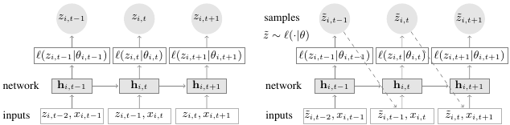

*Source: arXiv:1704.04110; page 3, section 2*

*"At each time step t, the inputs to the network are the covariates* $x_{i,t}$, *the target value at the previous time step* $z_{i,t-1}$, *as well as the previous network output* $h_{i,t-1}$ . *The network output* $h_{i,t} = h(h_{i,t-1}, z_{i,t-1}, x_{i,t}, \Theta$) *is then used to compute the parameters* $\theta_{i,t} = \theta(h_{i,t}, \Theta)$ *of the likelihood* ($z|\theta$), *which is used for training the model parameters. For prediction, the history of the time series* $zi,t$ *is fed in for* $t < t0$ , *then in the prediction range (right) for* $t >= t_0$ *a sample* $\hat{z}_{i,t} \approx (\cdot|\theta_{i,t})$ *is drawn and fed back for the next point until the end of the prediction range* $t = t0 + T$ *generating one sample trace."* Relating this idea to what we might be able to accomplish, effectively we lag our target by 1 observation and feed that into recurrent neural network's encoder stage. After all the values have been observed by the network, the decoder stage begins predicting in the same lagged fashion. This makes sense because our current farm's yield is not impacted by the weather at this particular instant, it's impacted by the weather the farm's surface experienced some time ago; it also explains what kind architecture we can use and how we feed our data into said architecture, but what about handling the multiple different categories?

### Probabilistic Demand Forecasting at Scale

(Back to top)  
*Amazon; Joos-Hendrik Böse, Valentin Flunkert, Jan Gasthaus, Tim Januschowski, Dustin Lange, David Salinas, Sebastian Schelter, Matthias Seeger, Yuyang Wang · [Proceedings of the VLDB Endowment, 2017 - Volume 10, Issue 12](https://doi.org/10.14778/3137765.3137775)*  
The problem discussed here is similar in nature to what was touched upon earlier: multiple products within different categories need to have their demand forecasted for multiple stakeholders of the firm. The question is specifically "what is the probability distribution of the demand of an item for a specific time horizon starting from a date in the future?" which, for our purposes, translates rather well to "what is the probability distribution of the demand of an ingredient, for a specific time horizon, starting from some date in the future?" The way this was tackled was masterful; quoting the paper:  
*"The demand forecasting problem constitutes in predicting the demand for a group of items at a certain range of days in the future, given demand data for all items up to the present, as well as other input data sources. [...] A sensible requirement of a forecasting system is consistency: the predicted distribution of* $Z_{I;(t_L, \delta_1 + \delta_2)}$ *should be the same as that of* $Z_{I;(t_L, \delta_1)} + Z_{I;(t_L + \delta_1, \delta_2)}$. *Moreover, users should be able to query any quantile of the forecast distribution, (e.g., the median or the 90-th percentile) for any combination of lead time and span, as well as any group of items I." Source: DOI 10.14778/3137765.3137775; page 2 (1695), section 2*

Specifically, the approach taken was something that's rather unfeasible for us right now given our... *humble* computing resources compared to what was used in the paper, but it does open up a lot of doors for us: the concept of distributed learning schemes. Quoting the paper again: *"there exists a variety of approaches to tackle the forecasting problem: in classical approaches, a single (local) model per item time series is computed. However, in many cases it might be beneficial to employ global learners that consider groups of items."* Under local learning, a single model per item is parameterised by the network; in our case this would require 1434 different models per farm - a statement which speaks for itself. Under global learning, a single model for all items is parameterised by the network; in our case, this would entail a single neural network for ~20mn rows of data, which will trash our RAM in an instant. However, the paper then continues: *"**Local learning with hierarchical regularization**. We support an extension to local learning which allows models to share statistical strength between items. The idea is to use a regularizer that shrinks the weight vector towards vectors learned at higher levels, incorporating the weights of many items. **Global-local learning.** The features as well as the weight vector which parameterizes the model here consist of a global part and a local part. In the case of the parameter vectors, the global part* $w$ *is shared by all items and local parts* $v_i$ *are specific to individual items $i$."*

Relating this to our current situation, in addition to autoregressing our target variable by a lag of 1 period, we can integrate our knowledge of how our climate behaves: climactic variability is minimal within a geography and therefore, we can assume each farm to already have been clustered. Following through from our discussion of granularity earlier, we can assume each location as a local model while one company is a global model. This way, we train to predict each farm's performance on the basis of its location, monitored and corrected globally on the basis of that farm's company. Practically what this means is we extract our data from the database on the basis of company (`select * from <table> where farming_company = <company>;`) which occurs in the outer loop and feed that dataset into our global network. Once the epoch completes its training, we extract those weights and build $n\_companies$ number of networks in an inner loop that each take in the Pythonic equivalent of (`select * from big_loop where location = <location>;`) in terms of data, and receive the pre-trained global weight tensor. The inner epoch finishes and the loops reset themselves until convergence or an early stopping criterion.

A prominent question at this stage is "do we really need all this computational complexity?" After all, universal function approximation is still linear at heart; wouldn't ARIMAX and its family be equally (if not more) effective? Autoregression literally played one of the biggest roles in the first paper. The truth is that while the AR*X family of simple linear models continues to remain very effective at what they do, they do have a few shortcomings about themselves that needed addressing. Now we get to the real wacky parts.

### Deep State Space Models for Time Series Forecasting

(Back to top)  
*Amazon; Syama Sundar Rangapuram, Matthias Seeger, Jan Gasthaus, Lorenzo Stella, Yuyang Wang, Tim Januschowski · [32nd Conference on Neural Information Processing Systems, 2018](https://papers.nips.cc/paper/2018/file/5cf68969fb67aa6082363a6d4e6468e2-Paper.pdf)*  
Deep Space State Models, apart from sounding really Sci-Fi, are actually very simple: the heart of the model is a regular State Space Model (ARIMA/X, Exponentially Smoothed series, Time Delay Embedding, etc.), but its parameters are provided by a recurrent neural network. State space modelling is widely applied to dynamical systems, where the evolution of said system is controlled by non-observable state variables. The system exhibits observable variables which are determined by said "latent" state variables - the SSM models both of them. While this isn't as straightforward as the other linked papers, it does offer insight into how different combinations of classical and deep models can be combined together into something that Just Works$^{TM}$. The training stages however are slightly more involved:

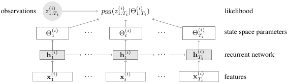

*Source: NeurIPS 2018; page 4, section 4*

*"During training, the inputs to the network are the features* $x_{t}^{(i)}$ *as well as the previous network output* $h_{t-1}$ *at each time step t in the training range* ${1, 2, \dots, T_i}$. *The network output* $h_t = h(h^{(i)}_{t-1}, x^{(i)}_t, \phi)$ *is then used to compute the parameters of the state space model* $\Theta_t$ *after mapping it to the corresponding ranges of the parameters. Given the time series observations* $z^{(i)}_{1:T}$ *in the training range, the likelihood of the state space parameters* $\Phi$ *(which are functions of the shared network parameters* $\phi$*) are computed according to Eq. 4. The shared network parameters* $\Phi$ *are then learned by maximizing the likelihood."* What all of this means for us is that our RNN (or LSTM) will simply be trained against an ARIMAX model, such that its $n$ outputs correspond to the parameters required by the space state model. Practically speaking, this would be slightly difficult to achieve and is also rather hard to keep a track of. There is also another issue that we should have noticed keeps recurring with RNNs or LSTMs for time series forecasting: the problem of extremely long sequences destroying differentiability. There are ways around this, however.

### Deep Transformer Models for Time Series Forecasting: The Influenza Prevalence Case

(Back to top)  
*Google; Neo Wu, Bradley Green, Xue Ben, Shawn O’Banion · [arXiv:2001.08317](https://arxiv.org/abs/2001.08317)*  
This was, perhaps, one of the most influential papers for our decision making process on which model is the most appropriate in terms of computational complexity and required labour. The motivation behind this approach stems from the fact that sequence-aligned models, while natural choices for modelling time series data, are faced with vanishing and exploding gradient problems along with (eventual) limited effectiveness of convolutional filters. More generally said, these methods have limitations in modelling long-term and complex relations in sequential data, and so a different approach is warranted. At the time of this paper, transformers already existed and were known to have overcome a lot of the limitations of recurrent networks, owing to their capability of looking at the entire dataset as a whole. Unlike sequence-aligned models, Transformers do not process data in an ordered sequence, they instead process the entire sequence at once, but with a self-attention mechanism that allows it to learn granular dependencies of the data. It's effectively a combination of an LSTM with an exponential (or weighted) moving average: a winning combination for time series. The transformer itself is rather pale compared to the networks we see today, but for the time it did a phenomenal job - even beating DeepAR! Quoting the paper:

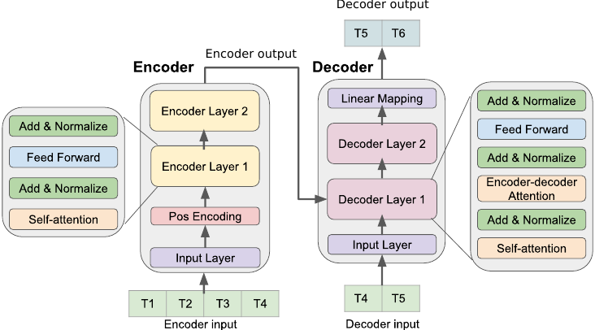

*Source: arXiv:2001.08317; page 2, section 1*

*"**Encoder.** The encoder is composed of an input layer, a positional encoding layer, and a stack of four identical encoder layers. The input layer maps the input time series data to a vector of dimension dmodel through a fully-connected network. This step is essential for the model to employ a multi-head attention mechanism. Positional encoding with sine and cosine functions is used to encode sequential information in the time series data by element-wise addition of the input vector with a positional encoding vector. The resulting vector is fed into four encoder layers. Each encoder layer consists of two sub-layers: a self-attention sub-layer and a fully-connected feed-forward sub-layer. Each sub-layer is followed by a normalization layer. The encoder produces a* $d_{model}$*-dimensional vector to feed to the decoder. **Decoder.** The decoder is also composed of the input layer, four identical decoder layers, and an output layer. The decoder input begins with the last data point of the encoder input. The input layer maps the decoder input to a* $d_{model}$*-dimensional vector. In addition to the two sub-layers in each encoder layer, the decoder inserts a third sub-layer to apply self-attention mechanisms over the encoder output. Finally, there is an output layer that maps the output of last decoder layer to the target time sequence."* The attention mechanism is what allows us to be granular with our data: for our purposes, we could send in an entire location's worth of information as long as it's been positionally encoded, and tell our transformer to pay attention to the last 48 hours of data when predicting the next 24 hours. This kind of model also lends itself extremely well to global learning, while a model like a DSSM would lend itself extremely well to local learning. But of course, the story doesn't stop here, because there are still much harder problems on the horizon. Enter the Temporal Fusion Transformer.

### Detour: The Current State of Our Plan

(Back to top)  
*Rahul Singh*  
We've reached the beans of this entire discussion; the real meat on the bones. Before getting into it, let's address a point that we've been saliently avoiding talking about: the fact that we have categorical data, and `farm_id`s, in our data. The problem we face is twofold: first, we need to predict a year-ahead amount of data using a year-prior amount of data at the hourly scale; secondly, we need to do this for multiple (1,434) farms. A third, rather non-obvious problem, is that we have categorical data to aid us. If we were to use a traditional network architecture such as an LSTM or a regular Transformer, we can eliminate this problem by understanding that we can encode our specific `farm_id` with an embedding layer. This also implies that we can embed different categorical variables at the same time, like `location`. What this would do is it would expand our 10 (or 11) character `farm_id` into an $n$ dimensional-vector that represents that and only that `farm_id` in the form of a lookup table (or Python dictionary). Consider the following image [from this very well written Hacks For AI article](https://hacksforai.blogspot.com/2022/11/how-to-adopt-embeddings-for-categorical-features-part-2.html):

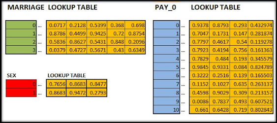

*Source: Hacks For AI; Adopting Embeddings for Categorical Features (Part 2)*

In the image we have 3 categorical features, each with their own $m$ number of levels (or factors). What we do for embedding text is we obtain some seed mathematical representation of it, either through one-hot encoding, or the length of the word, or its frequency (if we're talking about documents), etc., and feed it into an autoencoder style neural network that gives us a latent space representation of that word. In the image, the feature MARRIAGE has 4 levels $0, 1, 2, 3$, each of which can be represented by a vector of values. MARRIAGE therefore is represented by a matrix of $4 \times 5$, where 4 is the number of levels in the feature and 5 is the number of dimensions we have chosen for the vector. During backpropagation, an optimised set of weights for this feature matrix can be learned. After embedding our categorical features, we can simply concatenate their tensors onto our numerical data's tensor and feed the entire chunk into a transformer, starting from the input layer. For a reference idea of how this would work and look, refer to [this great article on Deep Learning for Tabular Data Using Pytorch](https://towardsdatascience.com/deep-learning-for-tabular-data-using-pytorch-1807f2858320):

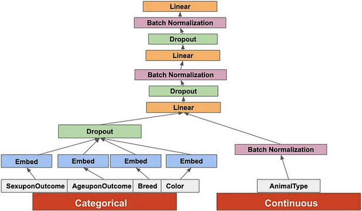

*Source: Aakanksha NS; Deep Learning for Tabular Data using PyTorch*

Now all of this is great so far because not only do we have a way to move past the biggest hurdle staring at us - our categorical data - we also have a network that's just itching to sink its teeth into the vast amounts of data we have to offer it. We can source our data at the corporate level (`select * from <table> where farming_company = <company>;`) looping over the number of companies we have, and feed that data into a transformer after embedding our categorical features such that we only need to build 6 to 7 different models. Weather interactions and farm behaviour within the purview of a single company is preserved. In order for us to be able to predict per farm while also accounting for global time series nuances (as mentioned earlier under *Global Learning*), we simply need to sort our train, validation and test sets the same way such that our predictions line up with that farm ID, for that length of series. We can even use our embedding layer's values to determine which farm has received which predictions; we can even assume manual control of the loop and train on every farm available, but test on each farm one by one printing out the `farm_id` of the current testing farm. However, we also need to keep in mind our GPU constraints: while yes it is a vector processor, it too has only a limited amount of memory that can only hold a certain size of data. In our case, we have only 8GB of VRAM to play with, so any amount of data larger than this could trigger a host of issues that (un)fortunately I have had to deal with each and every one of before (scheduler freezes, page faults, softlocks, complete halts, etc.)

We can do better. While we have dealt with the multivariate nature of our time series already from the days of DeepAR (and also categorical handling), dealing with 1,434 time series that need seeing to is not an easy task by any measure. Additionally, two problems lurk on the horizon, one of which plagues us: one, if we want to query our results similar to what was proposed in *Probabilistic Demand Forecasting At Scale*, we would need to handle multiple moving pieces (or networks) simultaneously; two, some time series will be of different lengths. Imagine a water supply company having to manage thousands of sensors across their operational geography, each reporting their own time series at different times of the day for a different set of hours only; imagine the amount of data being received by NASA from the James Webb - this time it's not a time series of continuous values, it's a time series of very high resolution images! Enter the Temporal Fusion Transformer.

### Temporal Fusion Transformers for Interpretable Multi-horizon Time Series Forecasting

(Back to top)  
*Google; Bryan Lim, Sercan Ö. Arık, Nicolas Loeff, Tomas Pfister · [arXiv:1912.09363](https://arxiv.org/abs/1912.09363)*

What's debatably the most capable time series forecaster so far, the TFT is expressly built for handling temporal complexity of modern, SOTA scales. It's a transformer-type model with attention that combines the best aspects knnown of sequential deep learning, such that it can achieve high performance in multi-step forecasting problems, learn on the fly and provide a very good level of interpretability and introspection. To quote the paper, *"[The TFT] specifically incorporates (1) static covariate encoders which encode context vectors for use in other parts of the network, (2) gating mechanisms throughout and sample-dependent variable selection to minimize the contributions of irrelevant inputs, (3) a sequence-to-sequence layer to locally process known and observed inputs, and (4) a temporal self-attention decoder to learn any long-term dependencies present within the dataset. The use of these specialized components also facilitates interpretability; in particular, we show that TFT enables three valuable interpretability use cases: helping users identify (i) globally-important variables for the prediction problem, (ii) persistent temporal patterns, and (iii) significant events."*

One of the major driving forces behind deciding to use the TFT for our problem here is the fact that we have multiple different time series at play within an entire dataset that has categorical features which also interact with one-another. Sifting through the large levels of interaction is specifically what the TFT is designed to do, and in a very optimised way that we were keen on incorporating: global-local learning, which although most transformers implement owing to their approach-based approaches, the TFT arguably does better due to its internal dynamics of decoding feature interacions. Another strong driving force behind the decision was the inherent feature selection capabiliies of the TFT that allows us to understand which climate measurement the network thinks is most applicable. All of this architecture can be represented by the following image:

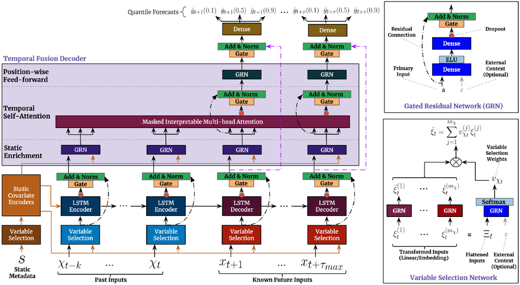

*Source: arXiv:1912.09363; page 6, section 4*

While it looks like simply a larger version of our original idea of incorporating separate categorical and numerical paths for encoding categoricals, the core building block of the TFT is the Gated Residual Network (GRN), which itself is a very, very small 2-layer NN. Each layer is a dense connection but with specific activation functions: an Exponenial Linear Unit (ELU), and a Gated Linear Unit (GLU). The former is a noise-suppressing, symmetric, non-contractive activation function whilst the latter consists of two 1D convolutional layers; input to the GLU is convolved twice, with one convolution "feature map" being passed through a sigmoid in order to identify salient yet effective features. These GLUs are used heavily across the TFT, mostly within GRNs, which themselves are used all over the TFT and especially within the Variable Selection Networks.

Within the VSN, each feature within the current row is passed through a GRN, yielding a latent representation of itself that can further be manipulated. For example, all features are sent in as $\xi$ and are returned as $\tilde \xi$ after the GRN does its work, however each feature map is also equted to the entirety of the current row via $\Xi$ in order to preserve state ($\xi_{t}^{1} \dots \xi_{t}^{m_{\chi}} = \Xi_{t}$). Also important to notice is that static variables are sent in separately and used to *condition* the LSTM, VSN and Static Enrichment layers with non-temporal data, such that its effect over time too is accounted for. The static encoders generate 4 vectors, $\{\vec C_h, \vec C_c, \vec C_s, \vec C_e\}$, where $\vec C_h$ and $\vec C_c$ are used to initialise the LSTM hidden and cell states; $\vec C_s$ is sent into that row's VSN, and $\vec C_e$ is forwarded to static enrichment.

The LSTM is your very standard run-of-the-mill temporal encoder that provides the TFT with a temporal understanding of what data its being given. Following this first massive phase of feature selection, multi-head attention ($Multihead(Q, K, V)$) takes over with one slight difference from the regular multi-head attention: the weights across each head are shared to facilitate introspection. Attention is applied to the data and only future inputs are passed forward into the prediction layers on the right, corresponding to LSTM decoder layers.

The crux of all this is twofold: not only does each instance pass through each of these layers (and therefore, not only does the TFT perform variable selection *for each instance*), but all static, past and future inputs make use of separate variable selection networks. This greatly aids the TFT in understanding the joint impact of static variables with dynamic variables over time; in our case, the interactions between locations (climate), companies (fertilisers and/or crop strategies), and ingredients (raw food sources/materials). The entire feature selection process constitutes the *local learning* section and is the encoder part of the TFT.

The last, most interesting point is that even coupled with all of this math, the TFT has been known to perform very, very well on small sets of data owing to its feature selection capabilities. That alone allows it to discern very salient relationships within the data given to it that other models need explicitly specified. The key points, therefore, for us to take away are these:

1. Inherent global-local learning allows the TFT to discern relationships between features we have a hard time sifting through due to the volume of our data.
2. Involvement of static features with dynamic features in a way that measures their impact over time and across categories (can our company produce differently within a location because of subtle weather differences?).
3. Ability to work well with small amounts of data and generalise to larger amounts *of the same* data allows us to avoid full-size TFT computational demands and test its capabilities on a subsampled dataset that's deemed to be representative of the population at large (within reason).

So given all of this context, pretext and history of multidimensional multivariate momentum, we'll be using the TFT for our work going forward. To phrase this in a slightly more accurate fashion, we're not going to sit through and manually understand the dynamics of each farm because we are lazy. We have universal function approximators, we'll use universal function approximators!

## Further Readings

(Back to top)

- Skander H. [(#89649)](https://stats.stackexchange.com/users/89649/skander-h), Strategies for time series forecasting for 2000 different products?, URL (version: 2019-02-20): https://stats.stackexchange.com/q/389327
- Skander H. [(#89649)](https://stats.stackexchange.com/users/89649/skander-h), How to Handle Many Times Series Simultaneously?, URL (version: 2019-06-10): https://stats.stackexchange.com/q/412355
- Aksakal [(#36041)](https://stats.stackexchange.com/users/36041/aksakal), How to Handle Many Times Series Simultaneously?, URL (version: 2019-06-11): https://stats.stackexchange.com/q/412397
- Hugh Perkins [(#10278)](https://stats.stackexchange.com/users/10278/hugh-perkins), How to train LSTM model on multiple time series data?, URL (version: 2021-12-01): https://stats.stackexchange.com/q/358837
- Kasper Groes Albin Ludvigsen; [TowardsDataScience - PyTorch Transformers for Time Series Forecasting](https://towardsdatascience.com/how-to-make-a-pytorch-transformer-for-time-series-forecasting-69e073d4061e)
- Long-Range Transformers for Dynamic Spatiotemporal Forecasting · Jake Grigsby, Zhe Wang, Yanjun Qi [arXiv:2109.12218](https://arxiv.org/abs/2109.12218)
- Informer: Beyond Efficient Transformer for Long Sequence Time-Series Forecasting · Haoyi Zhou, Shanghang Zhang, Jieqi Peng, Shuai Zhang, Jianxin Li, Hui Xiong, Wancai Zhang [arXiv:2012.07436](https://arxiv.org/abs/2012.07436)
- Entity Embeddings of Categorical Variables · Cheng Guo, Felix Berkhahn [arXiv:1604.06737](https://arxiv.org/abs/1604.06737)
- [PyTorch Forums: Categorical Embeddings](https://discuss.pytorch.org/t/categorical-embeddings-can-i-only-have-1-categorical-column-per-embedding-layer/104681/3)
- [PyTorch Forums: Importance of Embedding for Categorical Variables](https://discuss.pytorch.org/t/can-anybody-explain-the-importance-of-embedding-for-categorical-variables/76236/7)

# Practical Limitations of Forecasting with the Temporal Fusion Transformer

(Back to top)

A few important points to note before we begin: we're not implementing the TFT from scratch in PyTorch (even though that would be quite enjoyable), we're instead using an existing implementation in PyTorch Forecasting, which itself depends on PyTorch Lightning. This is necessary to mention because PyTorch Forecasting, in its version as of the time of this writing, has a few small bugs that cause errors during training and need to be fixed manually. These bugs are not structural, they simply exist because PyTorch, Lightning and Forecasting do not update in synchronicity with each other. What follows is the list of files and associated changes that need to be made in order to get this working:

### 1. PyTorch Forecasting: Encoders Issue (`pytorch_forecasting/data/encoders.py`)

The problem with this file is that [Pytorch Forecasting is affected](https://github.com/jdb78/pytorch-forecasting/issues/1236) by [NumPy's deprecation of `np.float`](https://numpy.org/devdocs/release/1.20.0-notes.html#deprecations), which causes errors most usually encountered from this file. We depend here on this file for our `TimeSeriesDataSet`. This is an issue I've faced before many times in other packages that depend on `np.float`, and thus far the workaround - [even the suggested one](https://github.com/jdb78/pytorch-forecasting/issues/1236#issuecomment-1410101307) - is the obvious route: go into the file and replace `np.float` with `float`. There is also a relevant [pull request (#1257)](https://github.com/jdb78/pytorch-forecasting/pull/1257/files) available that shows what's required to be done with the file, however keep in mind [this important point about GPUs usually working with 32-bit floats](https://github.com/jdb78/pytorch-forecasting/pull/1257#issuecomment-1431203889) and change only the specific occurrences of `np.float`.

### 2. PyTorch Forecasting: Base Model Issue (`pytorch_forecsating/models/base_model.py`)

The problem here actually stems from the return type of the PyTorch-Lightning function `get_init_args()`, which is defined in the file `pytorch_lightning/utilities/parsing.py` at line 140. The current version of the Lightning function (as of the time of this writing) returns two items from its local stack *as comma-separated values*, which we all know by now is [achieved by Python using a tuple](https://flexiple.com/python/python-return-multiple-values/#section2). Contrast this against the `BaseModel` class' `__init__` method contained in this file, specifically its series of operations between lines 259 and 263. The method initialises its class by inspecting the contents of the given dataset, which itself is governed by the PyTorch dataloader, and at line 260 we can see that the return values of `get_init_args()` are stored in the variable `init_args`, which is then iterated over in line 262. The problem here is that the iteration assumes `init_args` is a dictionary when in fact - at some point during Lightning's lifecycle, when the function return values were updated - it's a tuple. This raises an error because tuples do not have any method like `.items()`. The solution implemented here was to simply respectively assign the return values from `get_init_args()` to appropriate variables, giving us this kind of code at line 260 in the PyTorch Forecasting file: `_, init_args = get_init_args(frame)`. The iteration and all its dependencies should proceed normally after this small change.

*The next two points have been written completely in retrospect, after encountering some exceedingly frustrating, seriously cryptic errors (in true Python fashion...) when running inference with the TFT, after fully training a model:*

### 3. PyTorch Forecasting: `NaNLabelEncoder()` Necessity

The first issue faced when trying to run inference after training was that we didn't tell our TFT what strategy to use when an unknown category is encountered. This was accomplishd by including the use of the `NaNLabelEncoder()` within the `TimeSeriesDataSet` initialisation for train data, as discussed [here at SO: PyTorch Forecasting Unknown Category Encountered.](https://stackoverflow.com/questions/71098518/unknown-category-2-encountered-set-add-nan-true-to-allow-unknown-categories) Why was this not in the Forecasting documentation?

### 4. PyTorch Forecasting: Target Presence within Test

A rather interesting second inferential issue was that - for some mysterious reason - instantiating a prediction `TimeSeriesDataSet`, or even just trying to predict with the TFT on unseen data, required the *target feature to exist*. The workaround is placing a target feature in the Pandas `DataFrame` but filling it with zeroes. Note that the dummy target feature was first initialised with regular zeroes, i.e. `0`. This caused a large hue and cry from PyTorch because it demanded float values. The workaround finally used then is initialising the dummy target vector with `0.0`; it's also possible to initialise it with `0` and then cast it to a `float` using `.astype()`. If using the latter option, **be sure to assign the return value of `.astype()` to a dataframe: the function is not an inplace operation!**

There is a corresponding [GitHub issue (PyTorch Forecasting #1264; Colab Notebook also available)](https://github.com/jdb78/pytorch-forecasting/issues/1264) for these issues.

## Data Extraction and Modelling

(Back to top)  
Now with that all of that out of the way, let's discuss how we're going to feed this behemoth of a neural network enough data to keep it satiated. The standard PyTorch approach to feeding a network is through a `DataLoader`, which is simply a Python object that returns a single row from an underlying `Dataset`, which itself is an object that simply implements a `__getitem()` method. This is so that each time the loader is subscripted in a loop like `loader[i] for i in 1..10`, a single "row" from the underlying dataset is retrieved. The concept and utility behind this is absolute astounding because it allows the programmer to implement any kind of behind-the-scenes fetch logic regardless of whether the data is in memory, on disk, or in a database. As long as a single row is provided when the method is called, the model using that data source will happily train itself.

The standard `DataLoader`, as mentioned relies on an underlying `Dataset` which obviously implies the data is batched and ready to be iterated over. The `Dataset` also is required to have a `__len__()` method that informs the dataloader of the length of the underlying dataset. Given this kind of functionality, it seems trivial to structure our dataset and loader using our database: when our dataloder is indexed, our dataset's `__getitem()__` method queries our database for `batch_size` number of rows. In fact, this way the data might never even have to touch our RAM.

But not so fast! Since we're using PyTorch Forecasting's implementation of the TFT, we have a few conveniences and a few hindrances ahead of us: addressing the hindrances, Forecasting and its ecosystem revolves around the `TimeSeriesDataSet` class which works best (and is recommended to use with) a Pandas DataFrame. This is because of the ease and familiarity of the Pandas ecosystem with a lot of use-cases: it's much, much easier to point out what's what using a DataFrame from the front, and also manipulate it from the back. Because of this, our data is forced to enter memory and reside within a DataFrame, though we can reduce this amount tremendously by incorporating a functional programming approach. We are also therefore limited - in terms of how fluid flow out of a bottle is limited by the neck - to approaching Forecasting's ecosystem through the `TimeSeriesDataSet`, which might not suit all of our data ingestion needs.

Hindrances aside, the TSDS does offer us some massive conveniences for handling our data, owing to its Pandas backend: we do not need to manually encode, embed, scale, transform or otherwise preprocess our data at all. We just point out to the TSDS what we want done to what features, and it'll do its job getting it ready for the model we want to use. The TSDS also comes with its own methods for creating its own `DataLoader`, as well as instantiating the model we're using from its metadata! Because of these provisions by the TSDS, we'll be using it to batch our data and get it ready for the model.

The question then is how do we give our data to the TSDS? Since we have the drive speeds and lightweight access to our database, the best option we have for batching data is to iterate over it, as described earlier. The difference is this time instead of having a `DataLoader` iterate over our database for us, we manually pull out what we want from the db and give it to a TSDS, which will reside in memory and feed our model data with its own dataloader. This is where having an index on our tables comes in tremendous help.

## GPU Limitations

(Back to top)  
There are a few very real limitations we need to be aware of before training our model, almost all of which com from experimenting with the TFT multiple times before this final versioni: though a vector processor at heart, our GPU is a rasterisation device and therefore does not excel at general-purpose compute tasks; it's specialty is drawing things on a screen. This means that it can crunch numbers very quickly, but it can't store a large amount of information on itself nor can it crunch numbers *that* quickly. This gives us another problem: how much data can we fit on the thing? Empirically tested again over multiple different experimental rounds, our results - while promising - do not exactly inspire a lot of confidence: as mentioned, we do have a vector processor to play with, but it isn't oriented for GPGP. Adding onto this constraint is the fact that the TFT itself is rather large with a minimum of ~10,000 parameters. This situation greatly narrows down our options, leaving us with potentially only one best solution: we "batch" our data from the database by farm, where each farm should have a maximum expected amount of ~8,780 rows for one ingredient produced, and then give that dataset to the TSDS object which will further batch it onto the GPU from memory. Very, very far from ideal, but we still get to incorporate the TFT for a problem very apt for it, and we play within the bounds set by Forecasting.

The next obvious question is: how do we complete going over all the farms? As it stands, hot-swapping the underlying dataset while a model is running whilst keeping its dataloader in tact - all through Forecasting's API - is very much possible, but also a bit too much. Instead, thankfully, we have an extremely brilliant way out of this: Once the TFT completes training on the current TSDS, we'll leverage the brilliant mechanism offered by Lightning to *save our model* along with all of its parameters so far in a checkpoint file. We will then fetch the next batch of data from the database, provide it to the TSDS constructor and reload the model so that it continue training with the new batch of data. Keep in mind that while this approach is possible, it's extremely far from ideal: the best way to go about this would be to simply create a dataloader that executes an SQL fetch query when indexed, which spits out a `batch_size` number of rows which the model directly ingests.

The other small problem of pulling data from databases in order to feed it to a GPU is usually read/write speed: as mentioned, the computer involved has an Astra KD350X 256GB NVMe drive with read-write speeds of 3.4GB/s (3400MB/s, 425MT/s). For reference, the RAM installed on this machine has a maximum peak rating of 26GB/s (25600MB/s, 3200MT/s). The maximal size of the largest table in the database doesn't even cross 3GB, which literally means our entire dataset can be transfered in a second to the GPU (if the entire amount of data is given complete access to the device without any models or forward/backward pass functions, tensors, program states, memory maps and pages, etc.) The point is that access speeds are not a limiting factor in this scenario.

## GPU Training Speeds

(Back to top)  
This section coincides with part 8 of the associated SQL script.

The (hopefully) final limiting factor to how much data we can give our GPU: besides the fact that we're batching over an entire farm and our dataset consists of multiple farms, each with their own different states of production, we're also limited by the fact that our device is a rasterisation device. In more concrete terms, training the TFT on one farm's performance for 3 quarters of the year, *for one epoch*, takes around 7 minutes. We have 1,434 farms to deal with, which means training over our entire dataset with the ideal amount of 5 epochs would take $1434 \times 7 \times 5 = 50190$ minutes, or $\frac{50190}{60} = 836$ hours, or $\frac{836}{24} = 35$ days.

But all isn't lost, for there is opportunity in every problem: owing to the kind of data we have, we can exploit its repetitive structure over time and create a much smaller, more representative and "generalisable" *subsampled* dataset that we can safely train on whilst still retaining as much variability of state and feature interactivity as possible, in terms of both categorical and numerical features. Once we have enough information for our trained model this way - because essentially what we want to capture are the dynamic complexities over time - we can simply keep bootstrapping the best TFT onto more and more training data, rather than goiong through it all at once. We'll be back here as soon as we're ready to train. For monitoring our GPU, the 3rd party tool [UMR by Tom St. Denis](https://gitlab.freedesktop.org/tomstdenis/umr) was used, which is a common userspace debugging and diagnostic tool for AMD GPUs using the AMDGPU kernel driver via PCI express. For now, it's back to the database.

Sources:

- [PyTorch Forecasting: Demand Forecasting with the Temporal Fusion Transformer](https://pytorch-forecasting.readthedocs.io/en/stable/tutorials/stallion.html#Evaluate-performance)
- PyTorch Forecasting: TemporalFusionTransformer
- [PyTorch Forecasting: TimeSeriesDataSet](https://pytorch-forecasting.readthedocs.io/en/stable/api/pytorch_forecasting.data.timeseries.TimeSeriesDataSet.html#pytorch_forecasting.data.timeseries.TimeSeriesDataSet)
- [PyTorch Forecasting: Passing Data to a Model](https://pytorch-forecasting.readthedocs.io/en/stable/tutorials/building.html#Passing-data-to-a-model)
- [PyTorch Forecasting: TemporalFusionTransformer Source Code](https://pytorch-forecasting.readthedocs.io/en/stable/_modules/pytorch_forecasting/models/temporal_fusion_transformer.html#TemporalFusionTransformer.from_dataset)
- [PyTorch Forums: DataLoader and PostgreSQL an option?](https://discuss.pytorch.org/t/dataloader-and-postgres-or-other-sql-an-option/25927/)
- [SO: PyTorch Lightning Resuming From Checkpoint with New Data](https://stackoverflow.com/a/72168383)
- [Lightning AI Forums: How to resume training?](https://lightning.ai/forums/t/how-to-resume-training/432/7)
- [Stanford: Afshine Amidi and Shervine Amidi; Generating Data in Parallel with PyTorch](https://stanford.edu/~shervine/blog/pytorch-how-to-generate-data-parallel)
- [Lightning AI Forums: Dealing with Large Datasets](https://lightning.ai/forums/t/dealing-with-large-dataset/2070/2)
- Rachit Jain; [AnalyticsVidhya - Saving and Loading Your Model to Resume Training in PyTorch](https://medium.com/analytics-vidhya/saving-and-loading-your-model-to-resume-training-in-pytorch-cb687352fa61)
- Nikos Kafritsas; [TowardsDataScience - Temporal Fusion Transformer: Time Series Forecasting with Deep Learning — Complete Tutorial](https://towardsdatascience.com/temporal-fusion-transformer-time-series-forecasting-with-deep-learning-complete-tutorial-d32c1e51cd91)

# Training the TFT

This section will proceed into actually training the TFT on our beloved little GPU. As stated, our approach is a functional one and intends to extract one farm at a time from our source (subsampled) dataset residing in our PostgreSQL database, feed it into a `TimeSeriesDataSet` object and let that handle giving data to our GPU. Once a dataset is exhausted, i.e. training completes for that farm, we save our best performing model as a Lightning checkpoint, reinstantiate our TSDS, reload the model from said checkpoint and continue training with the new batch of data. This is accomplished through the humble `for` loop.

## Utility Functions: Data Fetch

(Back to top)  
These functions will be the ones we use when querying our database, feeding that data into the `TimeSeriesDataSet` class constructor, and initialising a `DataLoader` from the TSDS. A small point to note is that for some inexplicable reason, Pandas has a hard time inferring what kind of datatypes are being returned when we fetch data from our PostgreSQL connector. Because of this, we need to manually cast our column's data to their appropriate types before returning the dataframe. A lot of the `TemporalFusionTransformer` related code, especially that for the `TimeSeriesDataSet` is adapted right from the Forecasting tutorial available at [PyTorch Forecasting Tutorial: Demand Forecasting with the Temporal Fusion Transformer](https://pytorch-forecasting.readthedocs.io/en/stable/tutorials/stallion.html).

```python
def fetch_train_data(cur, fid, ing, source):
    cur.execute(f"""
    select *
    from {source}
    where farm_id = '{fid}'
    and ingredient_type = '{ing}';
    """)

    tmp_df = pd.DataFrame(
        cur.fetchall(),
        columns = [d[0] for d in cur.description]
    ).astype({
        "quarter"               : "int",
        "month"                 : "int",
        "week"                  : "int",
        "day"                   : "int",
        "dow"                   : "int",
        "hour"                  : "int",
        "time_idx"              : "int",
        "group"                 : "int",
        "farm_id"               : "category",
        "ingredient_type"       : "category",
        "farm_area"             : "float",
        "farming_company"       : "category",
        "deidentified_location" : "category",
        "temp_obs"              : "float",
        "cloudiness"            : "float",
        "wind_direction"        : "float",
        "dew_temp"              : "float",
        "pressure_sea_level"    : "float",
        "precipitation"         : "float",
        "wind_speed"            : "float",
        "yield"                 : "float"
    })

    return tmp_df
```

```python
def get_tsdsets(dframe, s_cats, kn_reals):
    day = 24
    month = 31 * day
    quarter = 3 * month

    # minimum lookback: 2 weeks; maximum lookback: 3 quarters
    # minimum predict: 1 week; maximum predict: 1 quarter
    min_encoder_len = 14 * day
    max_encoder_len = 3 * quarter
    min_predict_len = 7 * day
    max_predict_len = 1 * quarter

    training_cutoff = dframe["time_idx"].max() - max_predict_len
    train_tsd = TimeSeriesDataSet(
        dframe[lambda x: x.time_idx <= training_cutoff],
        time_idx                   = "time_idx",
        target                     = "yield",
        group_ids                  = ["group"],
        min_encoder_length         = min_encoder_len,
        max_encoder_length         = max_encoder_len,
        min_prediction_length      = min_predict_len,
        max_prediction_length      = max_predict_len,
        static_categoricals        = s_cats,
        time_varying_known_reals   = kn_reals,
        time_varying_unknown_reals = ["yield"],
        allow_missing_timesteps    = True,
        target_normalizer          = GroupNormalizer(
            groups = ["group"],
            transformation = "softplus"
        ),
        categorical_encoders       = {
            "group"                : NaNLabelEncoder(add_nan = True),
            "farm_id"              : NaNLabelEncoder(add_nan = True),
            "deidentified_location": NaNLabelEncoder(add_nan = True),
            "ingredient_type"      : NaNLabelEncoder(add_nan = True),
            "farming_company"      : NaNLabelEncoder(add_nan = True)
        }
    )

    valid_tsd = TimeSeriesDataSet.from_dataset(
        train_tsd, dframe, predict = True, stop_randomization = True
    )

    return (train_tsd, valid_tsd)
```

```python
def mkloaders(train_df, valid_df, batch, workers):
    train_dl = train_df.to_dataloader(
        batch_size = batch,
        train = True,
        num_workers = workers,
        pin_memory = True,
    )

    valid_dl = valid_df.to_dataloader(
        batch_size = batch,
        train = False,
        num_workers = workers,
        pin_memory = True,
    )

    return (train_dl, valid_dl)
```

## Utility Functions: Model Initialisation

(Back to top)  
These functions are called to build the TFT from a given source TSDS, as well as initialise a Lightning Trainer object. The Trainer is a wonderful piece of code that seamlessly manages the entire training loop cycle of a PyTorch model. All the Trainer ingests is the model to train and a couple of dataloaders to keep the model training. There is a lot of customisability available through the use of certain flags; all of which can be found [at the documentation page for the Lightning Trainer API](https://pytorch-lightning.readthedocs.io/en/stable/common/trainer.html#methods). For our purposes, here we're telling the trainer that we want it to offload our model to our GPU, that we have 1 GPU available, to summarise our model before training (which we'll see is contained in a giant error-red box), to clip gradients at a value lower than 0.1, and most importantly: to resume training of our model from any given checkpoint path. The `build_tft` function is where we're setting up our Temporal Fusion Transformer on the basis of the TSDS we're building at an earlier stage. Most of the flags for the TFT are set appropriately by the TSDS and then copied over or pointed to. Due to computational complexity, the size of the model is the bare minimum allowed by the Forecasting implementation.

Originally we also included an Early Stopping function `get_earlystop_cb()` which we passed to our trainer to effect early stopping on our model. Since we're training with only 1 epoch per farm, we don't want early stopping because the farms coming in after ES kicks in won't be trained on. The callback itelf was the standard, run of the mill Early Stopping logic, also present within the Forecasting TFT tutorial.

```python
def get_trainer(epochs, save_path = None):
    return pl.Trainer(
        accelerator = 'gpu',
        enable_model_summary = True,
        devices = 1,
        gradient_clip_val = 0.1,
        max_epochs = epochs,
        resume_from_checkpoint = save_path
    )
```

```python
def build_tft(temporal_dframe):
    return TemporalFusionTransformer.from_dataset(
        temporal_dframe,
        attention_head_size = 1,
        dropout = 0.1,
        hidden_size = 8,
        learning_rate = 0.03,
        loss = RMSE(),
        optimizer = "adam",
        output_size = 1
    )
```

## Utility Functions: Model Inspection

```python
def plot_preds(tftrans, valid_dl):
    raw_predictions, x = tftrans.predict(
        valid_dl, mode = "raw", return_x = True
    )

    return best_tft.plot_prediction(
        x, raw_predictions, idx = 0, add_loss_to_title = True
    );
```

```python
def plot_feats(tftrans, valid_dl):
    raw_predictions, x = tftrans.predict(
        valid_dl, mode = "raw", return_x = True
    )
    interpretation = tftrans.interpret_output(
        raw_predictions, reduction = "sum"
    )
    return tftrans.plot_interpretation(interpretation)
```

## Setup: Database Loop

(Back to top)  
This is the penultimate step before we begin looping over our database and training our model. Here we initialise containers for the features we know are categorical and don't vary with time, and the features we know are continuous and that do vary with time. These features will also be known in the future, which means the TFT can depend on the existence of values for these features when predicting for unseen data as well. There are other options available too such as temporally changing unknown continuous features for which values change with time and are not known in the future, and categorical features that also change with time, like branch location or colour of a star.

```python
static_categoricals = [
    "farm_id", "ingredient_type", "farming_company", "deidentified_location"
]

temporal_known_reals = [
    "farm_area", "temp_obs", "cloudiness", "wind_direction", "dew_temp",
    "pressure_sea_level", "precipitation", "wind_speed"
]

source_table = "final_train"

save_path = None
epox = 1

# 26Feb23 - we had a GPU segfault around 1h 18m during training, coinciding
# with ~8 farms fully trained on. The save file here has been changed from
# `None` to point to the last instance of the model we had before the crash.
# We've also increased the epochs to match the last known maximum the model
# was at, because if the number's the same then we can't continue trianing.
save_path = "lightning_logs/version_7/checkpoints/epoch=7-step=6045.ckpt"
epox = 9
```

## TFT Training Loop

(Back to top)  
And this is finally where we set our TFT to train on the data we're giving it. There is a very, very large elephant in the room that needs addressing: earlier we had mentioned that the TFT finishes training on a farm in approximately 7 minutes, which we said was for *one epoch*. Even after subsampling our data, we still are faced with time constraints that cannot be overcome, and so we've chosen exactly 1 epoch to train with. Something should be said here: **This is not the first pass at training the TFT**. There have been at least 8 prior runs at training, each in a different combination in order to test which one will maximise efficacy without taking too long. In more concrete words, training began on the 21st of February; this version was only arrived at after running the TFT for long enough during the previous attempts such that various other methodological and technical errors arose. The other side of the coin here is that a single forward pass through the data, even for just a single epoch, has only so far - from all previous test runs of the model, of which there were quite a few - generated a maximum RMSE of ~2500 with the average being around 150, which is rather acceptable and as well should be, because one of the many advantages of the TFT is that it can discern nuanced behaviour well from small sets of data.

26Feb23 Note: we're continuing after a GPU segfault that occurred at around 1h 18m of training, after completing around 8 farms out of 14 in the first out of 4 ingredients. This is why the output might seem truncated.

```python
# we need to iterate only over those farms that are present for that ingredient
cur.execute(f"select distinct ingredient_type from {source_table};")
ingreds = list(itertools.chain(*cur.fetchall()))

# 26Feb23 - since we had a segfault and we're resuming, we need to be sure we
# aren't resuming training from farm #1 all over again. The farms that have
# already been trained on can be ignored, which we're doing in our modified
# query here. We're not storing a separate variable like `not_list` and keeping
# our forbidden farm IDs in there because formatting lists in the middle of a
# multiline string is slightly out of the question for a list of only 8 farms.
# Maybe if the list grows bigger we'll do that,
for ing in ingreds:
    cur.execute(f"""
        select distinct farm_id
        from {source_table}
        where ingredient_type = '{ing}'
        and farm_id not in (
            'fid_101039', 'fid_101271', 'fid_104740', 'fid_105593',
            'fid_118325', 'fid_119338', 'fid_119518', 'fid_120597'
        );
    """)
    farms = list(itertools.chain(*cur.fetchall()))

    for fid in farms:
        # get the data feed ready
        train_tsds, valid_tsds = get_tsdsets(
            fetch_train_data(cur, fid, ing, source_table),
            static_categoricals, temporal_known_reals
        )
        train_dl, valid_dl = mkloaders(train_tsds, valid_tsds, 16, 8)

        # build the model based off the data feed
        trainer = get_trainer(epox, save_path)
        tftrans = build_tft(train_tsds)

        # train the model (implicit cuda)
        trainer.fit(
            tftrans,
            train_dataloaders = train_dl,
            val_dataloaders = valid_dl
        )

        # save the best performer for the next iteration
        save_path = trainer.checkpoint_callback.best_model_path
        best_tft = tftrans.load_from_checkpoint(save_path)

        # evaluate performance
        plot_preds(tftrans, valid_dl).savefig(f"plots/{ing}_{fid}_preds.jpg")
        for (title, ax) in plot_feats(tftrans, valid_dl).items():
            ax.savefig(f"plots/{ing}_{fid}_{title}.jpg")
        plt.close("all")

        # flavour text; extend epoch size to continue training
        print(f"completed training for farm {fid}.")
        epox += 1

    print(f"\n---------- ingredient {ing} completed. ----------\n")
```

```
GPU available: True (cuda), used: True
TPU available: False, using: 0 TPU cores
IPU available: False, using: 0 IPUs
HPU available: False, using: 0 HPUs
Restoring states from the checkpoint path at lightning_logs/version_7/checkpoints/epoch=7-step=6045.ckpt
LOCAL_RANK: 0 - CUDA_VISIBLE_DEVICES: [0]

   | Name                               | Type                            | Params
----------------------------------------------------------------------------------------
0  | loss                               | RMSE                            | 0
1  | logging_metrics                    | ModuleList                      | 0
2  | input_embeddings                   | MultiEmbedding                  | 8
3  | prescalers                         | ModuleDict                      | 160
4  | static_variable_selection          | VariableSelectionNetwork        | 596
5  | encoder_variable_selection         | VariableSelectionNetwork        | 3.8 K
6  | decoder_variable_selection         | VariableSelectionNetwork        | 3.4 K
7  | static_context_variable_selection  | GatedResidualNetwork            | 304
8  | static_context_initial_hidden_lstm | GatedResidualNetwork            | 304
9  | static_context_initial_cell_lstm   | GatedResidualNetwork            | 304
10 | static_context_enrichment          | GatedResidualNetwork            | 304
11 | lstm_encoder                       | LSTM                            | 576
12 | lstm_decoder                       | LSTM                            | 576
13 | post_lstm_gate_encoder             | GatedLinearUnit                 | 144
14 | post_lstm_add_norm_encoder         | AddNorm                         | 16
15 | static_enrichment                  | GatedResidualNetwork            | 368
16 | multihead_attn                     | InterpretableMultiHeadAttention | 280
17 | post_attn_gate_norm                | GateAddNorm                     | 160
18 | pos_wise_ff                        | GatedResidualNetwork            | 304
19 | pre_output_gate_norm               | GateAddNorm                     | 160
20 | output_layer                       | Linear                          | 9
----------------------------------------------------------------------------------------
11.5 K    Trainable params
0         Non-trainable params
11.5 K    Total params
0.046     Total estimated model params size (MB)
Restored all states from the checkpoint file at lightning_logs/version_7/checkpoints/epoch=7-step=6045.ckpt
```

```
Sanity Checking: 0it [00:00, ?it/s]
```

```
MIOpen(HIP): Warning [SQLiteBase] Missing system database file: gfx1030_14.kdb Performance may degrade. Please follow instructions to install: https://github.com/ROCmSoftwarePlatform/MIOpen#installing-miopen-kernels-package
```

```
Training: 756it [00:00, ?it/s]
```

```
Validation: 0it [00:00, ?it/s]
```

```
`Trainer.fit` stopped: `max_epochs=9` reached.
GPU available: True (cuda), used: True
TPU available: False, using: 0 TPU cores
IPU available: False, using: 0 IPUs
HPU available: False, using: 0 HPUs
Restoring states from the checkpoint path at /home/rsingh/Documents/INSOFE/05Feb23-FinalHack/lightning_logs/version_11/checkpoints/epoch=8-step=6801.ckpt
```

```
completed training for farm fid_120650.
```

```
LOCAL_RANK: 0 - CUDA_VISIBLE_DEVICES: [0]

   | Name                               | Type                            | Params
----------------------------------------------------------------------------------------
0  | loss                               | RMSE                            | 0
1  | logging_metrics                    | ModuleList                      | 0
2  | input_embeddings                   | MultiEmbedding                  | 8
3  | prescalers                         | ModuleDict                      | 160
4  | static_variable_selection          | VariableSelectionNetwork        | 596
5  | encoder_variable_selection         | VariableSelectionNetwork        | 3.8 K
6  | decoder_variable_selection         | VariableSelectionNetwork        | 3.4 K
7  | static_context_variable_selection  | GatedResidualNetwork            | 304
8  | static_context_initial_hidden_lstm | GatedResidualNetwork            | 304
9  | static_context_initial_cell_lstm   | GatedResidualNetwork            | 304
10 | static_context_enrichment          | GatedResidualNetwork            | 304
```

[output cut: 16 more lines]

```
Sanity Checking: 0it [00:00, ?it/s]
```

```
Training: 756it [00:00, ?it/s]
```

```
Validation: 0it [00:00, ?it/s]
```

```
`Trainer.fit` stopped: `max_epochs=10` reached.
GPU available: True (cuda), used: True
TPU available: False, using: 0 TPU cores
IPU available: False, using: 0 IPUs
HPU available: False, using: 0 HPUs
Restoring states from the checkpoint path at /home/rsingh/Documents/INSOFE/05Feb23-FinalHack/lightning_logs/version_12/checkpoints/epoch=9-step=7557.ckpt
```

```
completed training for farm fid_122174.
```

```
LOCAL_RANK: 0 - CUDA_VISIBLE_DEVICES: [0]

   | Name                               | Type                            | Params
----------------------------------------------------------------------------------------
0  | loss                               | RMSE                            | 0
1  | logging_metrics                    | ModuleList                      | 0
2  | input_embeddings                   | MultiEmbedding                  | 8
3  | prescalers                         | ModuleDict                      | 160
4  | static_variable_selection          | VariableSelectionNetwork        | 596
5  | encoder_variable_selection         | VariableSelectionNetwork        | 3.8 K
6  | decoder_variable_selection         | VariableSelectionNetwork        | 3.4 K
7  | static_context_variable_selection  | GatedResidualNetwork            | 304
8  | static_context_initial_hidden_lstm | GatedResidualNetwork            | 304
9  | static_context_initial_cell_lstm   | GatedResidualNetwork            | 304
10 | static_context_enrichment          | GatedResidualNetwork            | 304
```

[output cut: 16 more lines]

```
Sanity Checking: 0it [00:00, ?it/s]
```

```
Training: 756it [00:00, ?it/s]
```

```
Validation: 0it [00:00, ?it/s]
```

```
`Trainer.fit` stopped: `max_epochs=11` reached.
GPU available: True (cuda), used: True
TPU available: False, using: 0 TPU cores
IPU available: False, using: 0 IPUs
HPU available: False, using: 0 HPUs
Restoring states from the checkpoint path at /home/rsingh/Documents/INSOFE/05Feb23-FinalHack/lightning_logs/version_13/checkpoints/epoch=10-step=8313.ckpt
```

```
completed training for farm fid_26064.
```

```
LOCAL_RANK: 0 - CUDA_VISIBLE_DEVICES: [0]

   | Name                               | Type                            | Params
----------------------------------------------------------------------------------------
0  | loss                               | RMSE                            | 0
1  | logging_metrics                    | ModuleList                      | 0
2  | input_embeddings                   | MultiEmbedding                  | 8
3  | prescalers                         | ModuleDict                      | 160
4  | static_variable_selection          | VariableSelectionNetwork        | 596
5  | encoder_variable_selection         | VariableSelectionNetwork        | 3.8 K
6  | decoder_variable_selection         | VariableSelectionNetwork        | 3.4 K
7  | static_context_variable_selection  | GatedResidualNetwork            | 304
8  | static_context_initial_hidden_lstm | GatedResidualNetwork            | 304
9  | static_context_initial_cell_lstm   | GatedResidualNetwork            | 304
10 | static_context_enrichment          | GatedResidualNetwork            | 304
```

[output cut: 16 more lines]

```
Sanity Checking: 0it [00:00, ?it/s]
```

```
Training: 756it [00:00, ?it/s]
```

```
Validation: 0it [00:00, ?it/s]
```

```
`Trainer.fit` stopped: `max_epochs=12` reached.
GPU available: True (cuda), used: True
TPU available: False, using: 0 TPU cores
IPU available: False, using: 0 IPUs
HPU available: False, using: 0 HPUs
Restoring states from the checkpoint path at /home/rsingh/Documents/INSOFE/05Feb23-FinalHack/lightning_logs/version_14/checkpoints/epoch=11-step=9069.ckpt
```

```
completed training for farm fid_28178.
```

```
LOCAL_RANK: 0 - CUDA_VISIBLE_DEVICES: [0]

   | Name                               | Type                            | Params
----------------------------------------------------------------------------------------
0  | loss                               | RMSE                            | 0
1  | logging_metrics                    | ModuleList                      | 0
2  | input_embeddings                   | MultiEmbedding                  | 8
3  | prescalers                         | ModuleDict                      | 160
4  | static_variable_selection          | VariableSelectionNetwork        | 596
5  | encoder_variable_selection         | VariableSelectionNetwork        | 3.8 K
6  | decoder_variable_selection         | VariableSelectionNetwork        | 3.4 K
7  | static_context_variable_selection  | GatedResidualNetwork            | 304
8  | static_context_initial_hidden_lstm | GatedResidualNetwork            | 304
9  | static_context_initial_cell_lstm   | GatedResidualNetwork            | 304
10 | static_context_enrichment          | GatedResidualNetwork            | 304
```

[output cut: 16 more lines]

```
Sanity Checking: 0it [00:00, ?it/s]
```

```
Training: 756it [00:00, ?it/s]
```

```
Validation: 0it [00:00, ?it/s]
```

```
`Trainer.fit` stopped: `max_epochs=13` reached.
GPU available: True (cuda), used: True
TPU available: False, using: 0 TPU cores
IPU available: False, using: 0 IPUs
HPU available: False, using: 0 HPUs
Restoring states from the checkpoint path at /home/rsingh/Documents/INSOFE/05Feb23-FinalHack/lightning_logs/version_15/checkpoints/epoch=12-step=9824.ckpt
```

```
completed training for farm fid_30532.
```

```
LOCAL_RANK: 0 - CUDA_VISIBLE_DEVICES: [0]

   | Name                               | Type                            | Params
----------------------------------------------------------------------------------------
0  | loss                               | RMSE                            | 0
1  | logging_metrics                    | ModuleList                      | 0
2  | input_embeddings                   | MultiEmbedding                  | 8
3  | prescalers                         | ModuleDict                      | 160
4  | static_variable_selection          | VariableSelectionNetwork        | 596
5  | encoder_variable_selection         | VariableSelectionNetwork        | 3.8 K
6  | decoder_variable_selection         | VariableSelectionNetwork        | 3.4 K
7  | static_context_variable_selection  | GatedResidualNetwork            | 304
8  | static_context_initial_hidden_lstm | GatedResidualNetwork            | 304
9  | static_context_initial_cell_lstm   | GatedResidualNetwork            | 304
10 | static_context_enrichment          | GatedResidualNetwork            | 304
```

[output cut: 16 more lines]

```
Sanity Checking: 0it [00:00, ?it/s]
```

```
Training: 755it [00:00, ?it/s]
```

```
Validation: 0it [00:00, ?it/s]
```

```
`Trainer.fit` stopped: `max_epochs=14` reached.
GPU available: True (cuda), used: True
TPU available: False, using: 0 TPU cores
IPU available: False, using: 0 IPUs
HPU available: False, using: 0 HPUs
Restoring states from the checkpoint path at /home/rsingh/Documents/INSOFE/05Feb23-FinalHack/lightning_logs/version_16/checkpoints/epoch=13-step=10580.ckpt
```

```
completed training for farm fid_41680.

---------- ingredient ing_w completed. ----------
```

```
LOCAL_RANK: 0 - CUDA_VISIBLE_DEVICES: [0]

   | Name                               | Type                            | Params
----------------------------------------------------------------------------------------
0  | loss                               | RMSE                            | 0
1  | logging_metrics                    | ModuleList                      | 0
2  | input_embeddings                   | MultiEmbedding                  | 8
3  | prescalers                         | ModuleDict                      | 160
4  | static_variable_selection          | VariableSelectionNetwork        | 596
5  | encoder_variable_selection         | VariableSelectionNetwork        | 3.8 K
6  | decoder_variable_selection         | VariableSelectionNetwork        | 3.4 K
7  | static_context_variable_selection  | GatedResidualNetwork            | 304
8  | static_context_initial_hidden_lstm | GatedResidualNetwork            | 304
9  | static_context_initial_cell_lstm   | GatedResidualNetwork            | 304
10 | static_context_enrichment          | GatedResidualNetwork            | 304
```

[output cut: 16 more lines]

```
Sanity Checking: 0it [00:00, ?it/s]
```

```
Training: 756it [00:00, ?it/s]
```

```
Validation: 0it [00:00, ?it/s]
```

```
`Trainer.fit` stopped: `max_epochs=15` reached.
GPU available: True (cuda), used: True
TPU available: False, using: 0 TPU cores
IPU available: False, using: 0 IPUs
HPU available: False, using: 0 HPUs
Restoring states from the checkpoint path at /home/rsingh/Documents/INSOFE/05Feb23-FinalHack/lightning_logs/version_17/checkpoints/epoch=14-step=11335.ckpt
```

```
completed training for farm fid_103568.
```

```
LOCAL_RANK: 0 - CUDA_VISIBLE_DEVICES: [0]

   | Name                               | Type                            | Params
----------------------------------------------------------------------------------------
0  | loss                               | RMSE                            | 0
1  | logging_metrics                    | ModuleList                      | 0
2  | input_embeddings                   | MultiEmbedding                  | 8
3  | prescalers                         | ModuleDict                      | 160
4  | static_variable_selection          | VariableSelectionNetwork        | 596
5  | encoder_variable_selection         | VariableSelectionNetwork        | 3.8 K
6  | decoder_variable_selection         | VariableSelectionNetwork        | 3.4 K
7  | static_context_variable_selection  | GatedResidualNetwork            | 304
8  | static_context_initial_hidden_lstm | GatedResidualNetwork            | 304
9  | static_context_initial_cell_lstm   | GatedResidualNetwork            | 304
10 | static_context_enrichment          | GatedResidualNetwork            | 304
```

[output cut: 16 more lines]

```
Sanity Checking: 0it [00:00, ?it/s]
```

```
Training: 755it [00:00, ?it/s]
```

```
Validation: 0it [00:00, ?it/s]
```

```
`Trainer.fit` stopped: `max_epochs=16` reached.
GPU available: True (cuda), used: True
TPU available: False, using: 0 TPU cores
IPU available: False, using: 0 IPUs
HPU available: False, using: 0 HPUs
Restoring states from the checkpoint path at /home/rsingh/Documents/INSOFE/05Feb23-FinalHack/lightning_logs/version_18/checkpoints/epoch=15-step=11922.ckpt
```

```
completed training for farm fid_106446.
```

```
LOCAL_RANK: 0 - CUDA_VISIBLE_DEVICES: [0]

   | Name                               | Type                            | Params
----------------------------------------------------------------------------------------
0  | loss                               | RMSE                            | 0
1  | logging_metrics                    | ModuleList                      | 0
2  | input_embeddings                   | MultiEmbedding                  | 8
3  | prescalers                         | ModuleDict                      | 160
4  | static_variable_selection          | VariableSelectionNetwork        | 596
5  | encoder_variable_selection         | VariableSelectionNetwork        | 3.8 K
6  | decoder_variable_selection         | VariableSelectionNetwork        | 3.4 K
7  | static_context_variable_selection  | GatedResidualNetwork            | 304
8  | static_context_initial_hidden_lstm | GatedResidualNetwork            | 304
9  | static_context_initial_cell_lstm   | GatedResidualNetwork            | 304
10 | static_context_enrichment          | GatedResidualNetwork            | 304
```

[output cut: 16 more lines]

```
Sanity Checking: 0it [00:00, ?it/s]
```

```
Training: 587it [00:00, ?it/s]
```

```
Validation: 0it [00:00, ?it/s]
```

```
`Trainer.fit` stopped: `max_epochs=17` reached.
GPU available: True (cuda), used: True
TPU available: False, using: 0 TPU cores
IPU available: False, using: 0 IPUs
HPU available: False, using: 0 HPUs
Restoring states from the checkpoint path at /home/rsingh/Documents/INSOFE/05Feb23-FinalHack/lightning_logs/version_19/checkpoints/epoch=16-step=12487.ckpt
```

```
completed training for farm fid_107841.
```

```
LOCAL_RANK: 0 - CUDA_VISIBLE_DEVICES: [0]

   | Name                               | Type                            | Params
----------------------------------------------------------------------------------------
0  | loss                               | RMSE                            | 0
1  | logging_metrics                    | ModuleList                      | 0
2  | input_embeddings                   | MultiEmbedding                  | 8
3  | prescalers                         | ModuleDict                      | 160
4  | static_variable_selection          | VariableSelectionNetwork        | 596
5  | encoder_variable_selection         | VariableSelectionNetwork        | 3.8 K
6  | decoder_variable_selection         | VariableSelectionNetwork        | 3.4 K
7  | static_context_variable_selection  | GatedResidualNetwork            | 304
8  | static_context_initial_hidden_lstm | GatedResidualNetwork            | 304
9  | static_context_initial_cell_lstm   | GatedResidualNetwork            | 304
10 | static_context_enrichment          | GatedResidualNetwork            | 304
```

[output cut: 16 more lines]

```
Sanity Checking: 0it [00:00, ?it/s]
```

```
Training: 565it [00:00, ?it/s]
```

```
Validation: 0it [00:00, ?it/s]
```

```
`Trainer.fit` stopped: `max_epochs=18` reached.
GPU available: True (cuda), used: True
TPU available: False, using: 0 TPU cores
IPU available: False, using: 0 IPUs
HPU available: False, using: 0 HPUs
Restoring states from the checkpoint path at /home/rsingh/Documents/INSOFE/05Feb23-FinalHack/lightning_logs/version_20/checkpoints/epoch=17-step=13243.ckpt
```

```
completed training for farm fid_111995.
```

```
LOCAL_RANK: 0 - CUDA_VISIBLE_DEVICES: [0]

   | Name                               | Type                            | Params
----------------------------------------------------------------------------------------
0  | loss                               | RMSE                            | 0
1  | logging_metrics                    | ModuleList                      | 0
2  | input_embeddings                   | MultiEmbedding                  | 8
3  | prescalers                         | ModuleDict                      | 160
4  | static_variable_selection          | VariableSelectionNetwork        | 596
5  | encoder_variable_selection         | VariableSelectionNetwork        | 3.8 K
6  | decoder_variable_selection         | VariableSelectionNetwork        | 3.4 K
7  | static_context_variable_selection  | GatedResidualNetwork            | 304
8  | static_context_initial_hidden_lstm | GatedResidualNetwork            | 304
9  | static_context_initial_cell_lstm   | GatedResidualNetwork            | 304
10 | static_context_enrichment          | GatedResidualNetwork            | 304
```

[output cut: 16 more lines]

```
Sanity Checking: 0it [00:00, ?it/s]
```

```
Training: 756it [00:00, ?it/s]
```

```
Validation: 0it [00:00, ?it/s]
```

```
`Trainer.fit` stopped: `max_epochs=19` reached.
GPU available: True (cuda), used: True
TPU available: False, using: 0 TPU cores
IPU available: False, using: 0 IPUs
HPU available: False, using: 0 HPUs
```

```
completed training for farm fid_113277.
```

```
Restoring states from the checkpoint path at /home/rsingh/Documents/INSOFE/05Feb23-FinalHack/lightning_logs/version_21/checkpoints/epoch=18-step=13999.ckpt
LOCAL_RANK: 0 - CUDA_VISIBLE_DEVICES: [0]

   | Name                               | Type                            | Params
----------------------------------------------------------------------------------------
0  | loss                               | RMSE                            | 0
1  | logging_metrics                    | ModuleList                      | 0
2  | input_embeddings                   | MultiEmbedding                  | 8
3  | prescalers                         | ModuleDict                      | 160
4  | static_variable_selection          | VariableSelectionNetwork        | 596
5  | encoder_variable_selection         | VariableSelectionNetwork        | 3.8 K
6  | decoder_variable_selection         | VariableSelectionNetwork        | 3.4 K
7  | static_context_variable_selection  | GatedResidualNetwork            | 304
8  | static_context_initial_hidden_lstm | GatedResidualNetwork            | 304
9  | static_context_initial_cell_lstm   | GatedResidualNetwork            | 304
10 | static_context_enrichment          | GatedResidualNetwork            | 304
11 | lstm_encoder                       | LSTM                            | 576
12 | lstm_decoder                       | LSTM                            | 576
13 | post_lstm_gate_encoder             | GatedLinearUnit                 | 144
14 | post_lstm_add_norm_encoder         | AddNorm                         | 16
15 | static_enrichment                  | GatedResidualNetwork            | 368
16 | multihead_attn                     | InterpretableMultiHeadAttention | 280
17 | post_attn_gate_norm                | GateAddNorm                     | 160
18 | pos_wise_ff                        | GatedResidualNetwork            | 304
19 | pre_output_gate_norm               | GateAddNorm                     | 160
20 | output_layer                       | Linear                          | 9
----------------------------------------------------------------------------------------
11.5 K    Trainable params
0         Non-trainable params
11.5 K    Total params
0.046     Total estimated model params size (MB)
Restored all states from the checkpoint file at /home/rsingh/Documents/INSOFE/05Feb23-FinalHack/lightning_logs/version_21/checkpoints/epoch=18-step=13999.ckpt
```

```
Sanity Checking: 0it [00:00, ?it/s]
```

```
Training: 756it [00:00, ?it/s]
```

```
Validation: 0it [00:00, ?it/s]
```

```
`Trainer.fit` stopped: `max_epochs=20` reached.
GPU available: True (cuda), used: True
TPU available: False, using: 0 TPU cores
IPU available: False, using: 0 IPUs
HPU available: False, using: 0 HPUs
Restoring states from the checkpoint path at /home/rsingh/Documents/INSOFE/05Feb23-FinalHack/lightning_logs/version_22/checkpoints/epoch=19-step=14755.ckpt
```

```
completed training for farm fid_122174.
```

```
LOCAL_RANK: 0 - CUDA_VISIBLE_DEVICES: [0]

   | Name                               | Type                            | Params
----------------------------------------------------------------------------------------
0  | loss                               | RMSE                            | 0
1  | logging_metrics                    | ModuleList                      | 0
2  | input_embeddings                   | MultiEmbedding                  | 8
3  | prescalers                         | ModuleDict                      | 160
4  | static_variable_selection          | VariableSelectionNetwork        | 596
5  | encoder_variable_selection         | VariableSelectionNetwork        | 3.8 K
6  | decoder_variable_selection         | VariableSelectionNetwork        | 3.4 K
7  | static_context_variable_selection  | GatedResidualNetwork            | 304
8  | static_context_initial_hidden_lstm | GatedResidualNetwork            | 304
9  | static_context_initial_cell_lstm   | GatedResidualNetwork            | 304
10 | static_context_enrichment          | GatedResidualNetwork            | 304
```

[output cut: 16 more lines]

```
Sanity Checking: 0it [00:00, ?it/s]
```

```
Training: 756it [00:00, ?it/s]
```

```
Validation: 0it [00:00, ?it/s]
```

```
`Trainer.fit` stopped: `max_epochs=21` reached.
GPU available: True (cuda), used: True
TPU available: False, using: 0 TPU cores
IPU available: False, using: 0 IPUs
HPU available: False, using: 0 HPUs
Restoring states from the checkpoint path at /home/rsingh/Documents/INSOFE/05Feb23-FinalHack/lightning_logs/version_23/checkpoints/epoch=20-step=15511.ckpt
```

```
completed training for farm fid_26064.
```

```
LOCAL_RANK: 0 - CUDA_VISIBLE_DEVICES: [0]

   | Name                               | Type                            | Params
----------------------------------------------------------------------------------------
0  | loss                               | RMSE                            | 0
1  | logging_metrics                    | ModuleList                      | 0
2  | input_embeddings                   | MultiEmbedding                  | 8
3  | prescalers                         | ModuleDict                      | 160
4  | static_variable_selection          | VariableSelectionNetwork        | 596
5  | encoder_variable_selection         | VariableSelectionNetwork        | 3.8 K
6  | decoder_variable_selection         | VariableSelectionNetwork        | 3.4 K
7  | static_context_variable_selection  | GatedResidualNetwork            | 304
8  | static_context_initial_hidden_lstm | GatedResidualNetwork            | 304
9  | static_context_initial_cell_lstm   | GatedResidualNetwork            | 304
10 | static_context_enrichment          | GatedResidualNetwork            | 304
```

[output cut: 16 more lines]

```
Sanity Checking: 0it [00:00, ?it/s]
```

```
Training: 756it [00:00, ?it/s]
```

```
Validation: 0it [00:00, ?it/s]
```

```
`Trainer.fit` stopped: `max_epochs=22` reached.
GPU available: True (cuda), used: True
TPU available: False, using: 0 TPU cores
IPU available: False, using: 0 IPUs
HPU available: False, using: 0 HPUs
Restoring states from the checkpoint path at /home/rsingh/Documents/INSOFE/05Feb23-FinalHack/lightning_logs/version_24/checkpoints/epoch=21-step=16267.ckpt
```

```
completed training for farm fid_28178.
```

```
LOCAL_RANK: 0 - CUDA_VISIBLE_DEVICES: [0]

   | Name                               | Type                            | Params
----------------------------------------------------------------------------------------
0  | loss                               | RMSE                            | 0
1  | logging_metrics                    | ModuleList                      | 0
2  | input_embeddings                   | MultiEmbedding                  | 8
3  | prescalers                         | ModuleDict                      | 160
4  | static_variable_selection          | VariableSelectionNetwork        | 596
5  | encoder_variable_selection         | VariableSelectionNetwork        | 3.8 K
6  | decoder_variable_selection         | VariableSelectionNetwork        | 3.4 K
7  | static_context_variable_selection  | GatedResidualNetwork            | 304
8  | static_context_initial_hidden_lstm | GatedResidualNetwork            | 304
9  | static_context_initial_cell_lstm   | GatedResidualNetwork            | 304
10 | static_context_enrichment          | GatedResidualNetwork            | 304
```

[output cut: 16 more lines]

```
Sanity Checking: 0it [00:00, ?it/s]
```

```
Training: 756it [00:00, ?it/s]
```

```
Validation: 0it [00:00, ?it/s]
```

```
`Trainer.fit` stopped: `max_epochs=23` reached.
GPU available: True (cuda), used: True
TPU available: False, using: 0 TPU cores
IPU available: False, using: 0 IPUs
HPU available: False, using: 0 HPUs
Restoring states from the checkpoint path at /home/rsingh/Documents/INSOFE/05Feb23-FinalHack/lightning_logs/version_25/checkpoints/epoch=22-step=17022.ckpt
```

```
completed training for farm fid_38963.
```

```
LOCAL_RANK: 0 - CUDA_VISIBLE_DEVICES: [0]

   | Name                               | Type                            | Params
----------------------------------------------------------------------------------------
0  | loss                               | RMSE                            | 0
1  | logging_metrics                    | ModuleList                      | 0
2  | input_embeddings                   | MultiEmbedding                  | 8
3  | prescalers                         | ModuleDict                      | 160
4  | static_variable_selection          | VariableSelectionNetwork        | 596
5  | encoder_variable_selection         | VariableSelectionNetwork        | 3.8 K
6  | decoder_variable_selection         | VariableSelectionNetwork        | 3.4 K
7  | static_context_variable_selection  | GatedResidualNetwork            | 304
8  | static_context_initial_hidden_lstm | GatedResidualNetwork            | 304
9  | static_context_initial_cell_lstm   | GatedResidualNetwork            | 304
10 | static_context_enrichment          | GatedResidualNetwork            | 304
```

[output cut: 16 more lines]

```
Sanity Checking: 0it [00:00, ?it/s]
```

```
Training: 755it [00:00, ?it/s]
```

```
Validation: 0it [00:00, ?it/s]
```

```
`Trainer.fit` stopped: `max_epochs=24` reached.
GPU available: True (cuda), used: True
TPU available: False, using: 0 TPU cores
IPU available: False, using: 0 IPUs
HPU available: False, using: 0 HPUs
Restoring states from the checkpoint path at /home/rsingh/Documents/INSOFE/05Feb23-FinalHack/lightning_logs/version_26/checkpoints/epoch=23-step=17754.ckpt
```

```
completed training for farm fid_54695.
```

```
LOCAL_RANK: 0 - CUDA_VISIBLE_DEVICES: [0]

   | Name                               | Type                            | Params
----------------------------------------------------------------------------------------
0  | loss                               | RMSE                            | 0
1  | logging_metrics                    | ModuleList                      | 0
2  | input_embeddings                   | MultiEmbedding                  | 8
3  | prescalers                         | ModuleDict                      | 160
4  | static_variable_selection          | VariableSelectionNetwork        | 596
5  | encoder_variable_selection         | VariableSelectionNetwork        | 3.8 K
6  | decoder_variable_selection         | VariableSelectionNetwork        | 3.4 K
7  | static_context_variable_selection  | GatedResidualNetwork            | 304
8  | static_context_initial_hidden_lstm | GatedResidualNetwork            | 304
9  | static_context_initial_cell_lstm   | GatedResidualNetwork            | 304
10 | static_context_enrichment          | GatedResidualNetwork            | 304
```

[output cut: 16 more lines]

```
Sanity Checking: 0it [00:00, ?it/s]
```

```
Training: 732it [00:00, ?it/s]
```

```
Validation: 0it [00:00, ?it/s]
```

```
`Trainer.fit` stopped: `max_epochs=25` reached.
GPU available: True (cuda), used: True
TPU available: False, using: 0 TPU cores
IPU available: False, using: 0 IPUs
HPU available: False, using: 0 HPUs
Restoring states from the checkpoint path at /home/rsingh/Documents/INSOFE/05Feb23-FinalHack/lightning_logs/version_27/checkpoints/epoch=24-step=18509.ckpt
```

```
completed training for farm fid_62425.
```

```
LOCAL_RANK: 0 - CUDA_VISIBLE_DEVICES: [0]

   | Name                               | Type                            | Params
----------------------------------------------------------------------------------------
0  | loss                               | RMSE                            | 0
1  | logging_metrics                    | ModuleList                      | 0
2  | input_embeddings                   | MultiEmbedding                  | 8
3  | prescalers                         | ModuleDict                      | 160
4  | static_variable_selection          | VariableSelectionNetwork        | 596
5  | encoder_variable_selection         | VariableSelectionNetwork        | 3.8 K
6  | decoder_variable_selection         | VariableSelectionNetwork        | 3.4 K
7  | static_context_variable_selection  | GatedResidualNetwork            | 304
8  | static_context_initial_hidden_lstm | GatedResidualNetwork            | 304
9  | static_context_initial_cell_lstm   | GatedResidualNetwork            | 304
10 | static_context_enrichment          | GatedResidualNetwork            | 304
```

[output cut: 16 more lines]

```
Sanity Checking: 0it [00:00, ?it/s]
```

```
Training: 755it [00:00, ?it/s]
```

```
Validation: 0it [00:00, ?it/s]
```

```
`Trainer.fit` stopped: `max_epochs=26` reached.
GPU available: True (cuda), used: True
TPU available: False, using: 0 TPU cores
IPU available: False, using: 0 IPUs
HPU available: False, using: 0 HPUs
Restoring states from the checkpoint path at /home/rsingh/Documents/INSOFE/05Feb23-FinalHack/lightning_logs/version_28/checkpoints/epoch=25-step=19072.ckpt
```

```
completed training for farm fid_81920.
```

```
LOCAL_RANK: 0 - CUDA_VISIBLE_DEVICES: [0]

   | Name                               | Type                            | Params
----------------------------------------------------------------------------------------
0  | loss                               | RMSE                            | 0
1  | logging_metrics                    | ModuleList                      | 0
2  | input_embeddings                   | MultiEmbedding                  | 8
3  | prescalers                         | ModuleDict                      | 160
4  | static_variable_selection          | VariableSelectionNetwork        | 596
5  | encoder_variable_selection         | VariableSelectionNetwork        | 3.8 K
6  | decoder_variable_selection         | VariableSelectionNetwork        | 3.4 K
7  | static_context_variable_selection  | GatedResidualNetwork            | 304
8  | static_context_initial_hidden_lstm | GatedResidualNetwork            | 304
9  | static_context_initial_cell_lstm   | GatedResidualNetwork            | 304
10 | static_context_enrichment          | GatedResidualNetwork            | 304
```

[output cut: 16 more lines]

```
Sanity Checking: 0it [00:00, ?it/s]
```

```
Training: 563it [00:00, ?it/s]
```

```
Validation: 0it [00:00, ?it/s]
```

```
`Trainer.fit` stopped: `max_epochs=27` reached.
GPU available: True (cuda), used: True
TPU available: False, using: 0 TPU cores
IPU available: False, using: 0 IPUs
HPU available: False, using: 0 HPUs
Restoring states from the checkpoint path at /home/rsingh/Documents/INSOFE/05Feb23-FinalHack/lightning_logs/version_29/checkpoints/epoch=26-step=19828.ckpt
```

```
completed training for farm fid_83104.

---------- ingredient ing_x completed. ----------
```

```
LOCAL_RANK: 0 - CUDA_VISIBLE_DEVICES: [0]

   | Name                               | Type                            | Params
----------------------------------------------------------------------------------------
0  | loss                               | RMSE                            | 0
1  | logging_metrics                    | ModuleList                      | 0
2  | input_embeddings                   | MultiEmbedding                  | 8
3  | prescalers                         | ModuleDict                      | 160
4  | static_variable_selection          | VariableSelectionNetwork        | 596
5  | encoder_variable_selection         | VariableSelectionNetwork        | 3.8 K
6  | decoder_variable_selection         | VariableSelectionNetwork        | 3.4 K
7  | static_context_variable_selection  | GatedResidualNetwork            | 304
8  | static_context_initial_hidden_lstm | GatedResidualNetwork            | 304
9  | static_context_initial_cell_lstm   | GatedResidualNetwork            | 304
10 | static_context_enrichment          | GatedResidualNetwork            | 304
```

[output cut: 16 more lines]

```
Sanity Checking: 0it [00:00, ?it/s]
```

```
Training: 756it [00:00, ?it/s]
```

```
Validation: 0it [00:00, ?it/s]
```

```
`Trainer.fit` stopped: `max_epochs=28` reached.
GPU available: True (cuda), used: True
TPU available: False, using: 0 TPU cores
IPU available: False, using: 0 IPUs
HPU available: False, using: 0 HPUs
Restoring states from the checkpoint path at /home/rsingh/Documents/INSOFE/05Feb23-FinalHack/lightning_logs/version_30/checkpoints/epoch=27-step=20581.ckpt
```

```
completed training for farm fid_106666.
```

```
LOCAL_RANK: 0 - CUDA_VISIBLE_DEVICES: [0]

   | Name                               | Type                            | Params
----------------------------------------------------------------------------------------
0  | loss                               | RMSE                            | 0
1  | logging_metrics                    | ModuleList                      | 0
2  | input_embeddings                   | MultiEmbedding                  | 8
3  | prescalers                         | ModuleDict                      | 160
4  | static_variable_selection          | VariableSelectionNetwork        | 596
5  | encoder_variable_selection         | VariableSelectionNetwork        | 3.8 K
6  | decoder_variable_selection         | VariableSelectionNetwork        | 3.4 K
7  | static_context_variable_selection  | GatedResidualNetwork            | 304
8  | static_context_initial_hidden_lstm | GatedResidualNetwork            | 304
9  | static_context_initial_cell_lstm   | GatedResidualNetwork            | 304
10 | static_context_enrichment          | GatedResidualNetwork            | 304
```

[output cut: 16 more lines]

```
Sanity Checking: 0it [00:00, ?it/s]
```

```
Training: 753it [00:00, ?it/s]
```

```
Validation: 0it [00:00, ?it/s]
```

```
`Trainer.fit` stopped: `max_epochs=29` reached.
GPU available: True (cuda), used: True
TPU available: False, using: 0 TPU cores
IPU available: False, using: 0 IPUs
HPU available: False, using: 0 HPUs
Restoring states from the checkpoint path at /home/rsingh/Documents/INSOFE/05Feb23-FinalHack/lightning_logs/version_31/checkpoints/epoch=28-step=21334.ckpt
```

```
completed training for farm fid_114090.
```

```
LOCAL_RANK: 0 - CUDA_VISIBLE_DEVICES: [0]

   | Name                               | Type                            | Params
----------------------------------------------------------------------------------------
0  | loss                               | RMSE                            | 0
1  | logging_metrics                    | ModuleList                      | 0
2  | input_embeddings                   | MultiEmbedding                  | 8
3  | prescalers                         | ModuleDict                      | 160
4  | static_variable_selection          | VariableSelectionNetwork        | 596
5  | encoder_variable_selection         | VariableSelectionNetwork        | 3.8 K
6  | decoder_variable_selection         | VariableSelectionNetwork        | 3.4 K
7  | static_context_variable_selection  | GatedResidualNetwork            | 304
8  | static_context_initial_hidden_lstm | GatedResidualNetwork            | 304
9  | static_context_initial_cell_lstm   | GatedResidualNetwork            | 304
10 | static_context_enrichment          | GatedResidualNetwork            | 304
```

[output cut: 16 more lines]

```
Sanity Checking: 0it [00:00, ?it/s]
```

```
Training: 753it [00:00, ?it/s]
```

```
Validation: 0it [00:00, ?it/s]
```

```
`Trainer.fit` stopped: `max_epochs=30` reached.
GPU available: True (cuda), used: True
TPU available: False, using: 0 TPU cores
IPU available: False, using: 0 IPUs
HPU available: False, using: 0 HPUs
Restoring states from the checkpoint path at /home/rsingh/Documents/INSOFE/05Feb23-FinalHack/lightning_logs/version_32/checkpoints/epoch=29-step=22090.ckpt
```

```
completed training for farm fid_122174.
```

```
LOCAL_RANK: 0 - CUDA_VISIBLE_DEVICES: [0]

   | Name                               | Type                            | Params
----------------------------------------------------------------------------------------
0  | loss                               | RMSE                            | 0
1  | logging_metrics                    | ModuleList                      | 0
2  | input_embeddings                   | MultiEmbedding                  | 8
3  | prescalers                         | ModuleDict                      | 160
4  | static_variable_selection          | VariableSelectionNetwork        | 596
5  | encoder_variable_selection         | VariableSelectionNetwork        | 3.8 K
6  | decoder_variable_selection         | VariableSelectionNetwork        | 3.4 K
7  | static_context_variable_selection  | GatedResidualNetwork            | 304
8  | static_context_initial_hidden_lstm | GatedResidualNetwork            | 304
9  | static_context_initial_cell_lstm   | GatedResidualNetwork            | 304
10 | static_context_enrichment          | GatedResidualNetwork            | 304
```

[output cut: 16 more lines]

```
Sanity Checking: 0it [00:00, ?it/s]
```

```
Training: 756it [00:00, ?it/s]
```

```
Validation: 0it [00:00, ?it/s]
```

```
`Trainer.fit` stopped: `max_epochs=31` reached.
GPU available: True (cuda), used: True
TPU available: False, using: 0 TPU cores
IPU available: False, using: 0 IPUs
HPU available: False, using: 0 HPUs
Restoring states from the checkpoint path at /home/rsingh/Documents/INSOFE/05Feb23-FinalHack/lightning_logs/version_33/checkpoints/epoch=30-step=22846.ckpt
```

```
completed training for farm fid_26064.
```

```
LOCAL_RANK: 0 - CUDA_VISIBLE_DEVICES: [0]

   | Name                               | Type                            | Params
----------------------------------------------------------------------------------------
0  | loss                               | RMSE                            | 0
1  | logging_metrics                    | ModuleList                      | 0
2  | input_embeddings                   | MultiEmbedding                  | 8
3  | prescalers                         | ModuleDict                      | 160
4  | static_variable_selection          | VariableSelectionNetwork        | 596
5  | encoder_variable_selection         | VariableSelectionNetwork        | 3.8 K
6  | decoder_variable_selection         | VariableSelectionNetwork        | 3.4 K
7  | static_context_variable_selection  | GatedResidualNetwork            | 304
8  | static_context_initial_hidden_lstm | GatedResidualNetwork            | 304
9  | static_context_initial_cell_lstm   | GatedResidualNetwork            | 304
10 | static_context_enrichment          | GatedResidualNetwork            | 304
```

[output cut: 16 more lines]

```
Sanity Checking: 0it [00:00, ?it/s]
```

```
Training: 756it [00:00, ?it/s]
```

```
Validation: 0it [00:00, ?it/s]
```

```
`Trainer.fit` stopped: `max_epochs=32` reached.
GPU available: True (cuda), used: True
TPU available: False, using: 0 TPU cores
IPU available: False, using: 0 IPUs
HPU available: False, using: 0 HPUs
Restoring states from the checkpoint path at /home/rsingh/Documents/INSOFE/05Feb23-FinalHack/lightning_logs/version_34/checkpoints/epoch=31-step=23602.ckpt
```

```
completed training for farm fid_32599.
```

```
LOCAL_RANK: 0 - CUDA_VISIBLE_DEVICES: [0]

   | Name                               | Type                            | Params
----------------------------------------------------------------------------------------
0  | loss                               | RMSE                            | 0
1  | logging_metrics                    | ModuleList                      | 0
2  | input_embeddings                   | MultiEmbedding                  | 8
3  | prescalers                         | ModuleDict                      | 160
4  | static_variable_selection          | VariableSelectionNetwork        | 596
5  | encoder_variable_selection         | VariableSelectionNetwork        | 3.8 K
6  | decoder_variable_selection         | VariableSelectionNetwork        | 3.4 K
7  | static_context_variable_selection  | GatedResidualNetwork            | 304
8  | static_context_initial_hidden_lstm | GatedResidualNetwork            | 304
9  | static_context_initial_cell_lstm   | GatedResidualNetwork            | 304
10 | static_context_enrichment          | GatedResidualNetwork            | 304
```

[output cut: 16 more lines]

```
Sanity Checking: 0it [00:00, ?it/s]
```

```
Training: 756it [00:00, ?it/s]
```

```
Validation: 0it [00:00, ?it/s]
```

```
`Trainer.fit` stopped: `max_epochs=33` reached.
```

```
completed training for farm fid_35923.
```

```
GPU available: True (cuda), used: True
TPU available: False, using: 0 TPU cores
IPU available: False, using: 0 IPUs
HPU available: False, using: 0 HPUs
Restoring states from the checkpoint path at /home/rsingh/Documents/INSOFE/05Feb23-FinalHack/lightning_logs/version_35/checkpoints/epoch=32-step=24338.ckpt
LOCAL_RANK: 0 - CUDA_VISIBLE_DEVICES: [0]

   | Name                               | Type                            | Params
----------------------------------------------------------------------------------------
0  | loss                               | RMSE                            | 0
1  | logging_metrics                    | ModuleList                      | 0
2  | input_embeddings                   | MultiEmbedding                  | 8
3  | prescalers                         | ModuleDict                      | 160
4  | static_variable_selection          | VariableSelectionNetwork        | 596
5  | encoder_variable_selection         | VariableSelectionNetwork        | 3.8 K
6  | decoder_variable_selection         | VariableSelectionNetwork        | 3.4 K
7  | static_context_variable_selection  | GatedResidualNetwork            | 304
8  | static_context_initial_hidden_lstm | GatedResidualNetwork            | 304
9  | static_context_initial_cell_lstm   | GatedResidualNetwork            | 304
10 | static_context_enrichment          | GatedResidualNetwork            | 304
11 | lstm_encoder                       | LSTM                            | 576
12 | lstm_decoder                       | LSTM                            | 576
13 | post_lstm_gate_encoder             | GatedLinearUnit                 | 144
14 | post_lstm_add_norm_encoder         | AddNorm                         | 16
15 | static_enrichment                  | GatedResidualNetwork            | 368
16 | multihead_attn                     | InterpretableMultiHeadAttention | 280
17 | post_attn_gate_norm                | GateAddNorm                     | 160
18 | pos_wise_ff                        | GatedResidualNetwork            | 304
19 | pre_output_gate_norm               | GateAddNorm                     | 160
20 | output_layer                       | Linear                          | 9
----------------------------------------------------------------------------------------
11.5 K    Trainable params
0         Non-trainable params
11.5 K    Total params
0.046     Total estimated model params size (MB)
Restored all states from the checkpoint file at /home/rsingh/Documents/INSOFE/05Feb23-FinalHack/lightning_logs/version_35/checkpoints/epoch=32-step=24338.ckpt
```

```
Sanity Checking: 0it [00:00, ?it/s]
```

```
Training: 736it [00:00, ?it/s]
```

```
Validation: 0it [00:00, ?it/s]
```

```
`Trainer.fit` stopped: `max_epochs=34` reached.
GPU available: True (cuda), used: True
TPU available: False, using: 0 TPU cores
IPU available: False, using: 0 IPUs
HPU available: False, using: 0 HPUs
Restoring states from the checkpoint path at /home/rsingh/Documents/INSOFE/05Feb23-FinalHack/lightning_logs/version_36/checkpoints/epoch=33-step=25092.ckpt
```

```
completed training for farm fid_36575.
```

```
LOCAL_RANK: 0 - CUDA_VISIBLE_DEVICES: [0]

   | Name                               | Type                            | Params
----------------------------------------------------------------------------------------
0  | loss                               | RMSE                            | 0
1  | logging_metrics                    | ModuleList                      | 0
2  | input_embeddings                   | MultiEmbedding                  | 8
3  | prescalers                         | ModuleDict                      | 160
4  | static_variable_selection          | VariableSelectionNetwork        | 596
5  | encoder_variable_selection         | VariableSelectionNetwork        | 3.8 K
6  | decoder_variable_selection         | VariableSelectionNetwork        | 3.4 K
7  | static_context_variable_selection  | GatedResidualNetwork            | 304
8  | static_context_initial_hidden_lstm | GatedResidualNetwork            | 304
9  | static_context_initial_cell_lstm   | GatedResidualNetwork            | 304
10 | static_context_enrichment          | GatedResidualNetwork            | 304
```

[output cut: 16 more lines]

```
Sanity Checking: 0it [00:00, ?it/s]
```

```
Training: 754it [00:00, ?it/s]
```

```
Validation: 0it [00:00, ?it/s]
```

```
`Trainer.fit` stopped: `max_epochs=35` reached.
GPU available: True (cuda), used: True
TPU available: False, using: 0 TPU cores
IPU available: False, using: 0 IPUs
HPU available: False, using: 0 HPUs
Restoring states from the checkpoint path at /home/rsingh/Documents/INSOFE/05Feb23-FinalHack/lightning_logs/version_37/checkpoints/epoch=34-step=25846.ckpt
```

```
completed training for farm fid_50234.
```

```
LOCAL_RANK: 0 - CUDA_VISIBLE_DEVICES: [0]

   | Name                               | Type                            | Params
----------------------------------------------------------------------------------------
0  | loss                               | RMSE                            | 0
1  | logging_metrics                    | ModuleList                      | 0
2  | input_embeddings                   | MultiEmbedding                  | 8
3  | prescalers                         | ModuleDict                      | 160
4  | static_variable_selection          | VariableSelectionNetwork        | 596
5  | encoder_variable_selection         | VariableSelectionNetwork        | 3.8 K
6  | decoder_variable_selection         | VariableSelectionNetwork        | 3.4 K
7  | static_context_variable_selection  | GatedResidualNetwork            | 304
8  | static_context_initial_hidden_lstm | GatedResidualNetwork            | 304
9  | static_context_initial_cell_lstm   | GatedResidualNetwork            | 304
10 | static_context_enrichment          | GatedResidualNetwork            | 304
```

[output cut: 16 more lines]

```
Sanity Checking: 0it [00:00, ?it/s]
```

```
Training: 754it [00:00, ?it/s]
```

```
Validation: 0it [00:00, ?it/s]
```

```
`Trainer.fit` stopped: `max_epochs=36` reached.
GPU available: True (cuda), used: True
TPU available: False, using: 0 TPU cores
IPU available: False, using: 0 IPUs
HPU available: False, using: 0 HPUs
Restoring states from the checkpoint path at /home/rsingh/Documents/INSOFE/05Feb23-FinalHack/lightning_logs/version_38/checkpoints/epoch=35-step=26602.ckpt
```

```
completed training for farm fid_54620.
```

```
LOCAL_RANK: 0 - CUDA_VISIBLE_DEVICES: [0]

   | Name                               | Type                            | Params
----------------------------------------------------------------------------------------
0  | loss                               | RMSE                            | 0
1  | logging_metrics                    | ModuleList                      | 0
2  | input_embeddings                   | MultiEmbedding                  | 8
3  | prescalers                         | ModuleDict                      | 160
4  | static_variable_selection          | VariableSelectionNetwork        | 596
5  | encoder_variable_selection         | VariableSelectionNetwork        | 3.8 K
6  | decoder_variable_selection         | VariableSelectionNetwork        | 3.4 K
7  | static_context_variable_selection  | GatedResidualNetwork            | 304
8  | static_context_initial_hidden_lstm | GatedResidualNetwork            | 304
9  | static_context_initial_cell_lstm   | GatedResidualNetwork            | 304
10 | static_context_enrichment          | GatedResidualNetwork            | 304
```

[output cut: 16 more lines]

```
Sanity Checking: 0it [00:00, ?it/s]
```

```
Training: 756it [00:00, ?it/s]
```

```
Validation: 0it [00:00, ?it/s]
```

```
`Trainer.fit` stopped: `max_epochs=37` reached.
GPU available: True (cuda), used: True
TPU available: False, using: 0 TPU cores
IPU available: False, using: 0 IPUs
HPU available: False, using: 0 HPUs
Restoring states from the checkpoint path at /home/rsingh/Documents/INSOFE/05Feb23-FinalHack/lightning_logs/version_39/checkpoints/epoch=36-step=27358.ckpt
```

```
completed training for farm fid_60148.
```

```
LOCAL_RANK: 0 - CUDA_VISIBLE_DEVICES: [0]

   | Name                               | Type                            | Params
----------------------------------------------------------------------------------------
0  | loss                               | RMSE                            | 0
1  | logging_metrics                    | ModuleList                      | 0
2  | input_embeddings                   | MultiEmbedding                  | 8
3  | prescalers                         | ModuleDict                      | 160
4  | static_variable_selection          | VariableSelectionNetwork        | 596
5  | encoder_variable_selection         | VariableSelectionNetwork        | 3.8 K
6  | decoder_variable_selection         | VariableSelectionNetwork        | 3.4 K
7  | static_context_variable_selection  | GatedResidualNetwork            | 304
8  | static_context_initial_hidden_lstm | GatedResidualNetwork            | 304
9  | static_context_initial_cell_lstm   | GatedResidualNetwork            | 304
10 | static_context_enrichment          | GatedResidualNetwork            | 304
```

[output cut: 16 more lines]

```
Sanity Checking: 0it [00:00, ?it/s]
```

```
Training: 756it [00:00, ?it/s]
```

```
Validation: 0it [00:00, ?it/s]
```

```
`Trainer.fit` stopped: `max_epochs=38` reached.
GPU available: True (cuda), used: True
TPU available: False, using: 0 TPU cores
IPU available: False, using: 0 IPUs
HPU available: False, using: 0 HPUs
Restoring states from the checkpoint path at /home/rsingh/Documents/INSOFE/05Feb23-FinalHack/lightning_logs/version_40/checkpoints/epoch=37-step=28113.ckpt
```

```
completed training for farm fid_71961.
```

```
LOCAL_RANK: 0 - CUDA_VISIBLE_DEVICES: [0]

   | Name                               | Type                            | Params
----------------------------------------------------------------------------------------
0  | loss                               | RMSE                            | 0
1  | logging_metrics                    | ModuleList                      | 0
2  | input_embeddings                   | MultiEmbedding                  | 8
3  | prescalers                         | ModuleDict                      | 160
4  | static_variable_selection          | VariableSelectionNetwork        | 596
5  | encoder_variable_selection         | VariableSelectionNetwork        | 3.8 K
6  | decoder_variable_selection         | VariableSelectionNetwork        | 3.4 K
7  | static_context_variable_selection  | GatedResidualNetwork            | 304
8  | static_context_initial_hidden_lstm | GatedResidualNetwork            | 304
9  | static_context_initial_cell_lstm   | GatedResidualNetwork            | 304
10 | static_context_enrichment          | GatedResidualNetwork            | 304
```

[output cut: 16 more lines]

```
Sanity Checking: 0it [00:00, ?it/s]
```

```
Training: 755it [00:00, ?it/s]
```

```
Validation: 0it [00:00, ?it/s]
```

```
`Trainer.fit` stopped: `max_epochs=39` reached.
GPU available: True (cuda), used: True
TPU available: False, using: 0 TPU cores
IPU available: False, using: 0 IPUs
HPU available: False, using: 0 HPUs
Restoring states from the checkpoint path at /home/rsingh/Documents/INSOFE/05Feb23-FinalHack/lightning_logs/version_41/checkpoints/epoch=38-step=28868.ckpt
```

```
completed training for farm fid_72922.
```

```
LOCAL_RANK: 0 - CUDA_VISIBLE_DEVICES: [0]

   | Name                               | Type                            | Params
----------------------------------------------------------------------------------------
0  | loss                               | RMSE                            | 0
1  | logging_metrics                    | ModuleList                      | 0
2  | input_embeddings                   | MultiEmbedding                  | 8
3  | prescalers                         | ModuleDict                      | 160
4  | static_variable_selection          | VariableSelectionNetwork        | 596
5  | encoder_variable_selection         | VariableSelectionNetwork        | 3.8 K
6  | decoder_variable_selection         | VariableSelectionNetwork        | 3.4 K
7  | static_context_variable_selection  | GatedResidualNetwork            | 304
8  | static_context_initial_hidden_lstm | GatedResidualNetwork            | 304
9  | static_context_initial_cell_lstm   | GatedResidualNetwork            | 304
10 | static_context_enrichment          | GatedResidualNetwork            | 304
```

[output cut: 16 more lines]

```
Sanity Checking: 0it [00:00, ?it/s]
```

```
Training: 755it [00:00, ?it/s]
```

```
Validation: 0it [00:00, ?it/s]
```

```
`Trainer.fit` stopped: `max_epochs=40` reached.
GPU available: True (cuda), used: True
TPU available: False, using: 0 TPU cores
IPU available: False, using: 0 IPUs
HPU available: False, using: 0 HPUs
Restoring states from the checkpoint path at /home/rsingh/Documents/INSOFE/05Feb23-FinalHack/lightning_logs/version_42/checkpoints/epoch=39-step=29621.ckpt
```

```
completed training for farm fid_73600.
```

```
LOCAL_RANK: 0 - CUDA_VISIBLE_DEVICES: [0]

   | Name                               | Type                            | Params
----------------------------------------------------------------------------------------
0  | loss                               | RMSE                            | 0
1  | logging_metrics                    | ModuleList                      | 0
2  | input_embeddings                   | MultiEmbedding                  | 8
3  | prescalers                         | ModuleDict                      | 160
4  | static_variable_selection          | VariableSelectionNetwork        | 596
5  | encoder_variable_selection         | VariableSelectionNetwork        | 3.8 K
6  | decoder_variable_selection         | VariableSelectionNetwork        | 3.4 K
7  | static_context_variable_selection  | GatedResidualNetwork            | 304
8  | static_context_initial_hidden_lstm | GatedResidualNetwork            | 304
9  | static_context_initial_cell_lstm   | GatedResidualNetwork            | 304
10 | static_context_enrichment          | GatedResidualNetwork            | 304
```

[output cut: 16 more lines]

```
Sanity Checking: 0it [00:00, ?it/s]
```

```
Training: 753it [00:00, ?it/s]
```

```
Validation: 0it [00:00, ?it/s]
```

```
`Trainer.fit` stopped: `max_epochs=41` reached.
GPU available: True (cuda), used: True
TPU available: False, using: 0 TPU cores
IPU available: False, using: 0 IPUs
HPU available: False, using: 0 HPUs
Restoring states from the checkpoint path at /home/rsingh/Documents/INSOFE/05Feb23-FinalHack/lightning_logs/version_43/checkpoints/epoch=40-step=30377.ckpt
```

```
completed training for farm fid_77830.

---------- ingredient ing_y completed. ----------
```

```
LOCAL_RANK: 0 - CUDA_VISIBLE_DEVICES: [0]

   | Name                               | Type                            | Params
----------------------------------------------------------------------------------------
0  | loss                               | RMSE                            | 0
1  | logging_metrics                    | ModuleList                      | 0
2  | input_embeddings                   | MultiEmbedding                  | 8
3  | prescalers                         | ModuleDict                      | 160
4  | static_variable_selection          | VariableSelectionNetwork        | 596
5  | encoder_variable_selection         | VariableSelectionNetwork        | 3.8 K
6  | decoder_variable_selection         | VariableSelectionNetwork        | 3.4 K
7  | static_context_variable_selection  | GatedResidualNetwork            | 304
8  | static_context_initial_hidden_lstm | GatedResidualNetwork            | 304
9  | static_context_initial_cell_lstm   | GatedResidualNetwork            | 304
10 | static_context_enrichment          | GatedResidualNetwork            | 304
```

[output cut: 16 more lines]

```
Sanity Checking: 0it [00:00, ?it/s]
```

```
Training: 756it [00:00, ?it/s]
```

```
Validation: 0it [00:00, ?it/s]
```

```
`Trainer.fit` stopped: `max_epochs=42` reached.
GPU available: True (cuda), used: True
TPU available: False, using: 0 TPU cores
IPU available: False, using: 0 IPUs
HPU available: False, using: 0 HPUs
Restoring states from the checkpoint path at /home/rsingh/Documents/INSOFE/05Feb23-FinalHack/lightning_logs/version_44/checkpoints/epoch=41-step=31132.ckpt
```

```
completed training for farm fid_107259.
```

```
LOCAL_RANK: 0 - CUDA_VISIBLE_DEVICES: [0]

   | Name                               | Type                            | Params
----------------------------------------------------------------------------------------
0  | loss                               | RMSE                            | 0
1  | logging_metrics                    | ModuleList                      | 0
2  | input_embeddings                   | MultiEmbedding                  | 8
3  | prescalers                         | ModuleDict                      | 160
4  | static_variable_selection          | VariableSelectionNetwork        | 596
5  | encoder_variable_selection         | VariableSelectionNetwork        | 3.8 K
6  | decoder_variable_selection         | VariableSelectionNetwork        | 3.4 K
7  | static_context_variable_selection  | GatedResidualNetwork            | 304
8  | static_context_initial_hidden_lstm | GatedResidualNetwork            | 304
9  | static_context_initial_cell_lstm   | GatedResidualNetwork            | 304
10 | static_context_enrichment          | GatedResidualNetwork            | 304
```

[output cut: 16 more lines]

```
Sanity Checking: 0it [00:00, ?it/s]
```

```
Training: 755it [00:00, ?it/s]
```

```
Validation: 0it [00:00, ?it/s]
```

```
`Trainer.fit` stopped: `max_epochs=43` reached.
GPU available: True (cuda), used: True
TPU available: False, using: 0 TPU cores
IPU available: False, using: 0 IPUs
HPU available: False, using: 0 HPUs
Restoring states from the checkpoint path at /home/rsingh/Documents/INSOFE/05Feb23-FinalHack/lightning_logs/version_45/checkpoints/epoch=42-step=31888.ckpt
```

```
completed training for farm fid_110680.
```

```
LOCAL_RANK: 0 - CUDA_VISIBLE_DEVICES: [0]

   | Name                               | Type                            | Params
----------------------------------------------------------------------------------------
0  | loss                               | RMSE                            | 0
1  | logging_metrics                    | ModuleList                      | 0
2  | input_embeddings                   | MultiEmbedding                  | 8
3  | prescalers                         | ModuleDict                      | 160
4  | static_variable_selection          | VariableSelectionNetwork        | 596
5  | encoder_variable_selection         | VariableSelectionNetwork        | 3.8 K
6  | decoder_variable_selection         | VariableSelectionNetwork        | 3.4 K
7  | static_context_variable_selection  | GatedResidualNetwork            | 304
8  | static_context_initial_hidden_lstm | GatedResidualNetwork            | 304
9  | static_context_initial_cell_lstm   | GatedResidualNetwork            | 304
10 | static_context_enrichment          | GatedResidualNetwork            | 304
```

[output cut: 16 more lines]

```
Sanity Checking: 0it [00:00, ?it/s]
```

```
Training: 756it [00:00, ?it/s]
```

```
Validation: 0it [00:00, ?it/s]
```

```
`Trainer.fit` stopped: `max_epochs=44` reached.
GPU available: True (cuda), used: True
TPU available: False, using: 0 TPU cores
IPU available: False, using: 0 IPUs
HPU available: False, using: 0 HPUs
Restoring states from the checkpoint path at /home/rsingh/Documents/INSOFE/05Feb23-FinalHack/lightning_logs/version_46/checkpoints/epoch=43-step=32643.ckpt
```

```
completed training for farm fid_116209.
```

```
LOCAL_RANK: 0 - CUDA_VISIBLE_DEVICES: [0]

   | Name                               | Type                            | Params
----------------------------------------------------------------------------------------
0  | loss                               | RMSE                            | 0
1  | logging_metrics                    | ModuleList                      | 0
2  | input_embeddings                   | MultiEmbedding                  | 8
3  | prescalers                         | ModuleDict                      | 160
4  | static_variable_selection          | VariableSelectionNetwork        | 596
5  | encoder_variable_selection         | VariableSelectionNetwork        | 3.8 K
6  | decoder_variable_selection         | VariableSelectionNetwork        | 3.4 K
7  | static_context_variable_selection  | GatedResidualNetwork            | 304
8  | static_context_initial_hidden_lstm | GatedResidualNetwork            | 304
9  | static_context_initial_cell_lstm   | GatedResidualNetwork            | 304
10 | static_context_enrichment          | GatedResidualNetwork            | 304
```

[output cut: 16 more lines]

```
Sanity Checking: 0it [00:00, ?it/s]
```

```
Training: 755it [00:00, ?it/s]
```

```
Validation: 0it [00:00, ?it/s]
```

```
`Trainer.fit` stopped: `max_epochs=45` reached.
GPU available: True (cuda), used: True
TPU available: False, using: 0 TPU cores
IPU available: False, using: 0 IPUs
HPU available: False, using: 0 HPUs
Restoring states from the checkpoint path at /home/rsingh/Documents/INSOFE/05Feb23-FinalHack/lightning_logs/version_47/checkpoints/epoch=44-step=33398.ckpt
```

```
completed training for farm fid_121305.
```

```
LOCAL_RANK: 0 - CUDA_VISIBLE_DEVICES: [0]

   | Name                               | Type                            | Params
----------------------------------------------------------------------------------------
0  | loss                               | RMSE                            | 0
1  | logging_metrics                    | ModuleList                      | 0
2  | input_embeddings                   | MultiEmbedding                  | 8
3  | prescalers                         | ModuleDict                      | 160
4  | static_variable_selection          | VariableSelectionNetwork        | 596
5  | encoder_variable_selection         | VariableSelectionNetwork        | 3.8 K
6  | decoder_variable_selection         | VariableSelectionNetwork        | 3.4 K
7  | static_context_variable_selection  | GatedResidualNetwork            | 304
8  | static_context_initial_hidden_lstm | GatedResidualNetwork            | 304
9  | static_context_initial_cell_lstm   | GatedResidualNetwork            | 304
10 | static_context_enrichment          | GatedResidualNetwork            | 304
```

[output cut: 16 more lines]

```
Sanity Checking: 0it [00:00, ?it/s]
```

```
Training: 755it [00:00, ?it/s]
```

```
Validation: 0it [00:00, ?it/s]
```

```
`Trainer.fit` stopped: `max_epochs=46` reached.
GPU available: True (cuda), used: True
TPU available: False, using: 0 TPU cores
IPU available: False, using: 0 IPUs
HPU available: False, using: 0 HPUs
Restoring states from the checkpoint path at /home/rsingh/Documents/INSOFE/05Feb23-FinalHack/lightning_logs/version_48/checkpoints/epoch=45-step=34033.ckpt
```

```
completed training for farm fid_13316.
```

```
LOCAL_RANK: 0 - CUDA_VISIBLE_DEVICES: [0]

   | Name                               | Type                            | Params
----------------------------------------------------------------------------------------
0  | loss                               | RMSE                            | 0
1  | logging_metrics                    | ModuleList                      | 0
2  | input_embeddings                   | MultiEmbedding                  | 8
3  | prescalers                         | ModuleDict                      | 160
4  | static_variable_selection          | VariableSelectionNetwork        | 596
5  | encoder_variable_selection         | VariableSelectionNetwork        | 3.8 K
6  | decoder_variable_selection         | VariableSelectionNetwork        | 3.4 K
7  | static_context_variable_selection  | GatedResidualNetwork            | 304
8  | static_context_initial_hidden_lstm | GatedResidualNetwork            | 304
9  | static_context_initial_cell_lstm   | GatedResidualNetwork            | 304
10 | static_context_enrichment          | GatedResidualNetwork            | 304
```

[output cut: 16 more lines]

```
Sanity Checking: 0it [00:00, ?it/s]
```

[output not shown]

```
Validation: 0it [00:00, ?it/s]
```

```
`Trainer.fit` stopped: `max_epochs=47` reached.
GPU available: True (cuda), used: True
TPU available: False, using: 0 TPU cores
IPU available: False, using: 0 IPUs
HPU available: False, using: 0 HPUs
```

```
completed training for farm fid_27582.
```

[output not shown]

```
Sanity Checking: 0it [00:00, ?it/s]
```

```
Training: 755it [00:00, ?it/s]
```

```
Validation: 0it [00:00, ?it/s]
```

```
`Trainer.fit` stopped: `max_epochs=48` reached.
GPU available: True (cuda), used: True
TPU available: False, using: 0 TPU cores
IPU available: False, using: 0 IPUs
HPU available: False, using: 0 HPUs
Restoring states from the checkpoint path at /home/rsingh/Documents/INSOFE/05Feb23-FinalHack/lightning_logs/version_50/checkpoints/epoch=47-step=35543.ckpt
```

```
completed training for farm fid_35152.
```

```
LOCAL_RANK: 0 - CUDA_VISIBLE_DEVICES: [0]

   | Name                               | Type                            | Params
----------------------------------------------------------------------------------------
0  | loss                               | RMSE                            | 0
1  | logging_metrics                    | ModuleList                      | 0
2  | input_embeddings                   | MultiEmbedding                  | 8
3  | prescalers                         | ModuleDict                      | 160
4  | static_variable_selection          | VariableSelectionNetwork        | 596
5  | encoder_variable_selection         | VariableSelectionNetwork        | 3.8 K
6  | decoder_variable_selection         | VariableSelectionNetwork        | 3.4 K
7  | static_context_variable_selection  | GatedResidualNetwork            | 304
8  | static_context_initial_hidden_lstm | GatedResidualNetwork            | 304
9  | static_context_initial_cell_lstm   | GatedResidualNetwork            | 304
10 | static_context_enrichment          | GatedResidualNetwork            | 304
```

[output cut: 16 more lines]

```
Sanity Checking: 0it [00:00, ?it/s]
```

```
Training: 755it [00:00, ?it/s]
```

```
Validation: 0it [00:00, ?it/s]
```

```
`Trainer.fit` stopped: `max_epochs=49` reached.
GPU available: True (cuda), used: True
TPU available: False, using: 0 TPU cores
IPU available: False, using: 0 IPUs
HPU available: False, using: 0 HPUs
Restoring states from the checkpoint path at /home/rsingh/Documents/INSOFE/05Feb23-FinalHack/lightning_logs/version_51/checkpoints/epoch=48-step=36299.ckpt
```

```
completed training for farm fid_48766.
```

```
LOCAL_RANK: 0 - CUDA_VISIBLE_DEVICES: [0]

   | Name                               | Type                            | Params
----------------------------------------------------------------------------------------
0  | loss                               | RMSE                            | 0
1  | logging_metrics                    | ModuleList                      | 0
2  | input_embeddings                   | MultiEmbedding                  | 8
3  | prescalers                         | ModuleDict                      | 160
4  | static_variable_selection          | VariableSelectionNetwork        | 596
5  | encoder_variable_selection         | VariableSelectionNetwork        | 3.8 K
6  | decoder_variable_selection         | VariableSelectionNetwork        | 3.4 K
7  | static_context_variable_selection  | GatedResidualNetwork            | 304
8  | static_context_initial_hidden_lstm | GatedResidualNetwork            | 304
9  | static_context_initial_cell_lstm   | GatedResidualNetwork            | 304
10 | static_context_enrichment          | GatedResidualNetwork            | 304
```

[output cut: 16 more lines]

```
Sanity Checking: 0it [00:00, ?it/s]
```

```
Training: 756it [00:00, ?it/s]
```

```
Validation: 0it [00:00, ?it/s]
```

```
`Trainer.fit` stopped: `max_epochs=50` reached.
GPU available: True (cuda), used: True
TPU available: False, using: 0 TPU cores
IPU available: False, using: 0 IPUs
HPU available: False, using: 0 HPUs
Restoring states from the checkpoint path at /home/rsingh/Documents/INSOFE/05Feb23-FinalHack/lightning_logs/version_52/checkpoints/epoch=49-step=37055.ckpt
```

```
completed training for farm fid_49675.
```

```
LOCAL_RANK: 0 - CUDA_VISIBLE_DEVICES: [0]

   | Name                               | Type                            | Params
----------------------------------------------------------------------------------------
0  | loss                               | RMSE                            | 0
1  | logging_metrics                    | ModuleList                      | 0
2  | input_embeddings                   | MultiEmbedding                  | 8
3  | prescalers                         | ModuleDict                      | 160
4  | static_variable_selection          | VariableSelectionNetwork        | 596
5  | encoder_variable_selection         | VariableSelectionNetwork        | 3.8 K
6  | decoder_variable_selection         | VariableSelectionNetwork        | 3.4 K
7  | static_context_variable_selection  | GatedResidualNetwork            | 304
8  | static_context_initial_hidden_lstm | GatedResidualNetwork            | 304
9  | static_context_initial_cell_lstm   | GatedResidualNetwork            | 304
10 | static_context_enrichment          | GatedResidualNetwork            | 304
```

[output cut: 16 more lines]

```
Sanity Checking: 0it [00:00, ?it/s]
```

```
Training: 756it [00:00, ?it/s]
```

```
Validation: 0it [00:00, ?it/s]
```

```
`Trainer.fit` stopped: `max_epochs=51` reached.
GPU available: True (cuda), used: True
TPU available: False, using: 0 TPU cores
IPU available: False, using: 0 IPUs
HPU available: False, using: 0 HPUs
Restoring states from the checkpoint path at /home/rsingh/Documents/INSOFE/05Feb23-FinalHack/lightning_logs/version_53/checkpoints/epoch=50-step=37811.ckpt
```

```
completed training for farm fid_51573.
```

```
LOCAL_RANK: 0 - CUDA_VISIBLE_DEVICES: [0]

   | Name                               | Type                            | Params
----------------------------------------------------------------------------------------
0  | loss                               | RMSE                            | 0
1  | logging_metrics                    | ModuleList                      | 0
2  | input_embeddings                   | MultiEmbedding                  | 8
3  | prescalers                         | ModuleDict                      | 160
4  | static_variable_selection          | VariableSelectionNetwork        | 596
5  | encoder_variable_selection         | VariableSelectionNetwork        | 3.8 K
6  | decoder_variable_selection         | VariableSelectionNetwork        | 3.4 K
7  | static_context_variable_selection  | GatedResidualNetwork            | 304
8  | static_context_initial_hidden_lstm | GatedResidualNetwork            | 304
9  | static_context_initial_cell_lstm   | GatedResidualNetwork            | 304
10 | static_context_enrichment          | GatedResidualNetwork            | 304
```

[output cut: 16 more lines]

```
Sanity Checking: 0it [00:00, ?it/s]
```

```
Training: 756it [00:00, ?it/s]
```

```
Validation: 0it [00:00, ?it/s]
```

```
`Trainer.fit` stopped: `max_epochs=52` reached.
GPU available: True (cuda), used: True
TPU available: False, using: 0 TPU cores
IPU available: False, using: 0 IPUs
HPU available: False, using: 0 HPUs
Restoring states from the checkpoint path at /home/rsingh/Documents/INSOFE/05Feb23-FinalHack/lightning_logs/version_54/checkpoints/epoch=51-step=38566.ckpt
```

```
completed training for farm fid_66062.
```

```
LOCAL_RANK: 0 - CUDA_VISIBLE_DEVICES: [0]

   | Name                               | Type                            | Params
----------------------------------------------------------------------------------------
0  | loss                               | RMSE                            | 0
1  | logging_metrics                    | ModuleList                      | 0
2  | input_embeddings                   | MultiEmbedding                  | 8
3  | prescalers                         | ModuleDict                      | 160
4  | static_variable_selection          | VariableSelectionNetwork        | 596
5  | encoder_variable_selection         | VariableSelectionNetwork        | 3.8 K
6  | decoder_variable_selection         | VariableSelectionNetwork        | 3.4 K
7  | static_context_variable_selection  | GatedResidualNetwork            | 304
8  | static_context_initial_hidden_lstm | GatedResidualNetwork            | 304
9  | static_context_initial_cell_lstm   | GatedResidualNetwork            | 304
10 | static_context_enrichment          | GatedResidualNetwork            | 304
```

[output cut: 16 more lines]

```
Sanity Checking: 0it [00:00, ?it/s]
```

```
Training: 755it [00:00, ?it/s]
```

```
Validation: 0it [00:00, ?it/s]
```

```
`Trainer.fit` stopped: `max_epochs=53` reached.
GPU available: True (cuda), used: True
TPU available: False, using: 0 TPU cores
IPU available: False, using: 0 IPUs
HPU available: False, using: 0 HPUs
Restoring states from the checkpoint path at /home/rsingh/Documents/INSOFE/05Feb23-FinalHack/lightning_logs/version_55/checkpoints/epoch=52-step=39321.ckpt
```

```
completed training for farm fid_68761.
```

```
LOCAL_RANK: 0 - CUDA_VISIBLE_DEVICES: [0]

   | Name                               | Type                            | Params
----------------------------------------------------------------------------------------
0  | loss                               | RMSE                            | 0
1  | logging_metrics                    | ModuleList                      | 0
2  | input_embeddings                   | MultiEmbedding                  | 8
3  | prescalers                         | ModuleDict                      | 160
4  | static_variable_selection          | VariableSelectionNetwork        | 596
5  | encoder_variable_selection         | VariableSelectionNetwork        | 3.8 K
6  | decoder_variable_selection         | VariableSelectionNetwork        | 3.4 K
7  | static_context_variable_selection  | GatedResidualNetwork            | 304
8  | static_context_initial_hidden_lstm | GatedResidualNetwork            | 304
9  | static_context_initial_cell_lstm   | GatedResidualNetwork            | 304
10 | static_context_enrichment          | GatedResidualNetwork            | 304
```

[output cut: 16 more lines]

```
Sanity Checking: 0it [00:00, ?it/s]
```

```
Training: 755it [00:00, ?it/s]
```

```
Validation: 0it [00:00, ?it/s]
```

```
`Trainer.fit` stopped: `max_epochs=54` reached.
GPU available: True (cuda), used: True
TPU available: False, using: 0 TPU cores
IPU available: False, using: 0 IPUs
HPU available: False, using: 0 HPUs
Restoring states from the checkpoint path at /home/rsingh/Documents/INSOFE/05Feb23-FinalHack/lightning_logs/version_56/checkpoints/epoch=53-step=40076.ckpt
```

```
completed training for farm fid_73431.
```

```
LOCAL_RANK: 0 - CUDA_VISIBLE_DEVICES: [0]

   | Name                               | Type                            | Params
----------------------------------------------------------------------------------------
0  | loss                               | RMSE                            | 0
1  | logging_metrics                    | ModuleList                      | 0
2  | input_embeddings                   | MultiEmbedding                  | 8
3  | prescalers                         | ModuleDict                      | 160
4  | static_variable_selection          | VariableSelectionNetwork        | 596
5  | encoder_variable_selection         | VariableSelectionNetwork        | 3.8 K
6  | decoder_variable_selection         | VariableSelectionNetwork        | 3.4 K
7  | static_context_variable_selection  | GatedResidualNetwork            | 304
8  | static_context_initial_hidden_lstm | GatedResidualNetwork            | 304
9  | static_context_initial_cell_lstm   | GatedResidualNetwork            | 304
10 | static_context_enrichment          | GatedResidualNetwork            | 304
```

[output cut: 16 more lines]

```
Sanity Checking: 0it [00:00, ?it/s]
```

```
Training: 755it [00:00, ?it/s]
```

```
Validation: 0it [00:00, ?it/s]
```

```
`Trainer.fit` stopped: `max_epochs=55` reached.
```

```
completed training for farm fid_92956.

---------- ingredient ing_z completed. ----------
```

# Forecasting with the TFT

(Back to top)  
The way we go about using the big mean TFT we trained is similar: we pull out the data we want to predict on, in this case each farm from the predict dataset, structure a `TimeSeriesDataSet` around it by bootstrapping the initialiser with our existing TSDS, initialise its dataloader and feed it to the Lightning Trainer. We need to keep in mind however that we intend on predicting for one quarter at a time within the confines of a single farm (producing a single ingredient, i.e. maximum length of 8,760 rows), so either we inform our dataloader to spit out data in batches of 4 over the entire year, or we structure our own dataloader and attempt to use that. As discussed however, the format of the data for Forecasting models matters, so we should be better off using the TSDS.

**In order for running inference with the TFT to work, it's crucial that points 3 and 4 here have been taken into consideration.** Most importantly, categorical features that are *known* to have factors that the model might not have been exposed to during training need to have corresponding `NaNLabelEncoder()` functions assigned to them.

## Utility Function: Test Data Fetch

(Back to top)  
Why didn't we club this with our previous fetch function? Because the prediction set doesn't have the target column and therefore we would have had to use some specialised logic to get that sorted out which could affect function execution times even though the query is the same. Offloading the query into the calling function (or cell) gets very messy and unreadable and is prone to errors if we want to update something in our query. The tradeoff of a function like this taking up extra stack space is acceptable given the conveniences we get from not only having the function, but also having two separate ones that *explicitly* force the programmer to state their intention: am I fetching train or test?

```python
def fetch_test_data(cur, fid, ing, source):
    cur.execute(f"""
    select *
    from {source}
    where farm_id = '{fid}'
    and ingredient_type = '{ing}';
    """)

    tmp_df = pd.DataFrame(
        cur.fetchall(),
        columns = [d[0] for d in cur.description]
    ).astype({
        "quarter"               : "int",
        "month"                 : "int",
        "week"                  : "int",
        "day"                   : "int",
        "dow"                   : "int",
        "hour"                  : "int",
        "time_idx"              : "int",
        "group"                 : "int",
        "farm_id"               : "category",
        "id"                    : "int",
        "ingredient_type"       : "category",
        "farm_area"             : "float",
        "farming_company"       : "category",
        "deidentified_location" : "category",
        "temp_obs"              : "float",
        "cloudiness"            : "float",
        "wind_direction"        : "float",
        "dew_temp"              : "float",
        "pressure_sea_level"    : "float",
        "precipitation"         : "float",
        "wind_speed"            : "float"
    })

    return tmp_df
```

What we're going to do here is try to predict for one farm first. If everything goes well, we'll automate the process and iterate over every farm in `test` in a fashion not dissimilar to what we've already done for `train`. Again, owing to PyTorch's capabilities of saving models, we simply need to load our model from its checkpoint (after instantiating all associated objects) and give it some data to run its forward pass on. Simple, right?

```python
tmp_df = fetch_test_data(cur, "fid_100053", "ing_w", "final_test")
tmp_df
```

|  | quarter | month | week | day | dow | hour | time_idx | group | farm_id | id | ... | farm_area | farming_company | deidentified_location | temp_obs | cloudiness | wind_direction | dew_temp | pressure_sea_level | precipitation | wind_speed |
| --- | --- | --- | --- | --- | --- | --- | --- | --- | --- | --- | --- | --- | --- | --- | --- | --- | --- | --- | --- | --- | --- |
| 0 | 1 | 1 | 52 | 1 | 0 | 0 | 1 | 1 | fid_100053 | 8412446 | ... | 2043.866 | Del Monte Foods | location 5290 | 8.900000 | 8.0 | 190.00000 | -5.60000 | 1015.30000 | 0.687394 | 8.200000 |
| 1 | 1 | 1 | 52 | 1 | 0 | 1 | 2 | 1 | fid_100053 | 8412720 | ... | 2043.866 | Del Monte Foods | location 5290 | 8.300000 | 8.0 | 210.00000 | -4.40000 | 1014.90000 | -1.000000 | 8.800000 |
| 2 | 1 | 1 | 52 | 1 | 0 | 2 | 3 | 1 | fid_100053 | 8412994 | ... | 2043.866 | Del Monte Foods | location 5290 | 8.900000 | 8.0 | 210.00000 | -5.60000 | 1014.50000 | -1.000000 | 7.200000 |
| 3 | 1 | 1 | 52 | 1 | 0 | 3 | 4 | 1 | fid_100053 | 8413268 | ... | 2043.866 | Del Monte Foods | location 5290 | 8.300000 | 8.0 | 200.00000 | -5.00000 | 1014.50000 | 0.000000 | 6.200000 |
| 4 | 1 | 1 | 52 | 1 | 0 | 4 | 5 | 1 | fid_100053 | 8413542 | ... | 2043.866 | Del Monte Foods | location 5290 | 7.800000 | 8.0 | 210.00000 | -5.00000 | 1015.00000 | 0.000000 | 5.700000 |
| ... | ... | ... | ... | ... | ... | ... | ... | ... | ... | ... | ... | ... | ... | ... | ... | ... | ... | ... | ... | ... | ... |
| 8755 | 4 | 12 | 52 | 31 | 0 | 20 | 8756 | 1 | fid_100053 | 10811316 | ... | 2043.866 | Del Monte Foods | location 5290 | -6.100000 | 8.0 | 330.00000 | -17.20000 | 1028.50000 | 0.000000 | 8.200000 |
| 8756 | 4 | 12 | 52 | 31 | 0 | 21 | 8757 | 1 | fid_100053 | 10811590 | ... | 2043.866 | Del Monte Foods | location 5290 | -6.700000 | 8.0 | 340.00000 | -15.00000 | 1028.70000 | 0.000000 | 7.200000 |
| 8757 | 4 | 12 | 52 | 31 | 0 | 22 | 8758 | 1 | fid_100053 | 10811864 | ... | 2043.866 | Del Monte Foods | location 5290 | -7.200000 | 8.0 | 320.00000 | -14.40000 | 1028.90000 | 0.000000 | 4.600000 |
| 8758 | 4 | 12 | 52 | 31 | 0 | 23 | 8759 | 1 | fid_100053 | 10812138 | ... | 2043.866 | Del Monte Foods | location 5290 | -6.700000 | 8.0 | 330.00000 | -16.10000 | 1029.30000 | 0.000000 | 6.700000 |
| 8759 | 1 | 1 | 2 | 13 | 5 | 5 | 8760 | 1 | fid_100053 | 41513255 | ... | 2043.866 | Del Monte Foods | location 5290 | 15.763344 | 3.0 | 173.64848 | 7.72746 | 1015.63544 | 1.102006 | 3.422358 |

8760 rows × 21 columns

Since we have an `id` column in our `test` data that corresponds uniquely to each datapoint in the file, we need to store that so we can reindex and align our predictions properly. All we need to do now is prepare a small batch of test data (i.e. 1 quarter of data), create a TSDS with a dataloader for it, load up the model from the checkpoint and send the data in for prediction!

```python
fid_100053_id = tmp_df.pop("id")
fid_100053_id
```

```
0        8412446
1        8412720
2        8412994
3        8413268
4        8413542
          ...
8755    10811316
8756    10811590
8757    10811864
8758    10812138
8759    41513255
Name: id, Length: 8760, dtype: int64
```

```python
# very, very important that this is a float value, lest we want PyTorch Core
# issues regarding tensor data types when running inference.
tmp_df["yield"] = 0.0

day = 24
month = 31 * day
quarter = 3 * month
max_predict_len = 1 * quarter

# also important that we use the exact same lengths we gave when training
# because we have leap years and different quarters within a dataset (i.e. one
# farm can have quarters like 1 -> 2 -> 3 -> 4 -> 1). This also helps when
# comparing prediction length and dataset length. See debug notebook for more.
train_cut = tmp_df["time_idx"].max() - max_predict_len
pred_df = tmp_df[lambda x: x.time_idx >= train_cut]
print(pred_df.dtypes)
pred_df
```

```
quarter                     int64
month                       int64
week                        int64
day                         int64
dow                         int64
hour                        int64
time_idx                    int64
group                       int64
farm_id                  category
ingredient_type          category
farm_area                 float64
farming_company          category
deidentified_location    category
temp_obs                  float64
cloudiness                float64
wind_direction            float64
dew_temp                  float64
pressure_sea_level        float64
precipitation             float64
wind_speed                float64
yield                     float64
dtype: object
```

|  | quarter | month | week | day | dow | hour | time_idx | group | farm_id | ingredient_type | ... | farming_company | deidentified_location | temp_obs | cloudiness | wind_direction | dew_temp | pressure_sea_level | precipitation | wind_speed | yield |
| --- | --- | --- | --- | --- | --- | --- | --- | --- | --- | --- | --- | --- | --- | --- | --- | --- | --- | --- | --- | --- | --- |
| 6527 | 3 | 9 | 39 | 30 | 6 | 0 | 6528 | 1 | fid_100053 | ing_w | ... | Del Monte Foods | location 5290 | 20.600000 | 2.0 | 150.00000 | 10.60000 | 1017.60000 | 0.000000 | 2.100000 | 0.0 |
| 6528 | 3 | 9 | 39 | 30 | 6 | 1 | 6529 | 1 | fid_100053 | ing_w | ... | Del Monte Foods | location 5290 | 18.900000 | 2.0 | 200.00000 | 11.70000 | 1018.30000 | 0.000000 | 3.600000 | 0.0 |
| 6529 | 3 | 9 | 39 | 30 | 6 | 2 | 6530 | 1 | fid_100053 | ing_w | ... | Del Monte Foods | location 5290 | 17.800000 | 2.0 | 210.00000 | 11.10000 | 1018.40000 | 0.000000 | 2.100000 | 0.0 |
| 6530 | 3 | 9 | 39 | 30 | 6 | 3 | 6531 | 1 | fid_100053 | ing_w | ... | Del Monte Foods | location 5290 | 17.800000 | 4.0 | 220.00000 | 11.10000 | 1018.50000 | 0.000000 | 1.500000 | 0.0 |
| 6531 | 3 | 9 | 39 | 30 | 6 | 4 | 6532 | 1 | fid_100053 | ing_w | ... | Del Monte Foods | location 5290 | 17.800000 | 4.0 | 230.00000 | 12.80000 | 1018.40000 | 0.000000 | 2.100000 | 0.0 |
| ... | ... | ... | ... | ... | ... | ... | ... | ... | ... | ... | ... | ... | ... | ... | ... | ... | ... | ... | ... | ... | ... |
| 8755 | 4 | 12 | 52 | 31 | 0 | 20 | 8756 | 1 | fid_100053 | ing_w | ... | Del Monte Foods | location 5290 | -6.100000 | 8.0 | 330.00000 | -17.20000 | 1028.50000 | 0.000000 | 8.200000 | 0.0 |
| 8756 | 4 | 12 | 52 | 31 | 0 | 21 | 8757 | 1 | fid_100053 | ing_w | ... | Del Monte Foods | location 5290 | -6.700000 | 8.0 | 340.00000 | -15.00000 | 1028.70000 | 0.000000 | 7.200000 | 0.0 |
| 8757 | 4 | 12 | 52 | 31 | 0 | 22 | 8758 | 1 | fid_100053 | ing_w | ... | Del Monte Foods | location 5290 | -7.200000 | 8.0 | 320.00000 | -14.40000 | 1028.90000 | 0.000000 | 4.600000 | 0.0 |
| 8758 | 4 | 12 | 52 | 31 | 0 | 23 | 8759 | 1 | fid_100053 | ing_w | ... | Del Monte Foods | location 5290 | -6.700000 | 8.0 | 330.00000 | -16.10000 | 1029.30000 | 0.000000 | 6.700000 | 0.0 |
| 8759 | 1 | 1 | 2 | 13 | 5 | 5 | 8760 | 1 | fid_100053 | ing_w | ... | Del Monte Foods | location 5290 | 15.763344 | 3.0 | 173.64848 | 7.72746 | 1015.63544 | 1.102006 | 3.422358 | 0.0 |

2233 rows × 21 columns

```python
fid_100053_q1_preds = best_tft.predict(pred_df)
print(fid_100053_q1_preds)
len(fid_100053_q1_preds[0])
```

```
---------------------------------------------------------------------------
AssertionError                            Traceback (most recent call last)
Cell In[15], line 1
----> 1 fid_100053_q1_preds = best_tft.predict(pred_df)
      2 print(fid_100053_q1_preds)
      3 len(fid_100053_q1_preds[0])

File ~/mambaforge/lib/python3.10/site-packages/pytorch_forecasting/models/base_model.py:1138, in BaseModel.predict(self, data, mode, return_index, return_decoder_lengths, batch_size, num_workers, fast_dev_run, show_progress_bar, return_x, mode_kwargs, **kwargs)
   1136 # convert to dataloader
   1137 if isinstance(data, pd.DataFrame):
-> 1138     data = TimeSeriesDataSet.from_parameters(self.dataset_parameters, data, predict=True)
   1139 if isinstance(data, TimeSeriesDataSet):
   1140     dataloader = data.to_dataloader(batch_size=batch_size, train=False, num_workers=num_workers)

File ~/mambaforge/lib/python3.10/site-packages/pytorch_forecasting/data/timeseries.py:1201, in TimeSeriesDataSet.from_parameters(cls, parameters, data, stop_randomization, predict, **update_kwargs)
   1198     parameters["randomize_length"] = None
   1199 parameters.update(update_kwargs)
-> 1201 new = cls(data, **parameters)
   1202 return new

File ~/mambaforge/lib/python3.10/site-packages/pytorch_forecasting/data/timeseries.py:481, in TimeSeriesDataSet.__init__(self, data, time_idx, target, group_ids, weight, max_encoder_length, min_encoder_length, min_prediction_idx, min_prediction_length, max_prediction_length, static_categoricals, sta…
    478     assert target not in self.scalers, "Target normalizer is separate and not in scalers."
    480 # create index
--> 481 self.index = self._construct_index(data, predict_mode=self.predict_mode)
    483 # convert to torch tensor for high performance data loading later
    484 self.data = self._data_to_tensors(data)

File ~/mambaforge/lib/python3.10/site-packages/pytorch_forecasting/data/timeseries.py:1291, in TimeSeriesDataSet._construct_index(self, data, predict_mode)
   1281         missing_groups[id] = self.transform_values(name, missing_groups[id], inverse=True, group_id=True)
   1282     warnings.warn(
   1283         "Min encoder length and/or min_prediction_idx and/or min prediction length and/or lags are "
   1284         "too large for "
   (...)
   1288         UserWarning,
   1289     )
   1290 assert (
-> 1291     len(df_index) > 0
   1292 ), "filters should not remove entries all entries - check encoder/decoder lengths and lags"
   1294 return df_index

AssertionError: filters should not remove entries all entries - check encoder/decoder lengths and lags
```

```python
print("Max", train_tsds.max_encoder_length)
print("Min", train_tsds.min_encoder_length)
```

```
Max 6696
Min 336
```

```python
print("Max", train_tsds.max_prediction_length)
print("Min", train_tsds.min_prediction_length)
```

```
Max 2232
Min 168
```

```python
tmp_df[:max_predict_len]
```

|  | quarter | month | week | day | dow | hour | time_idx | group | farm_id | ingredient_type | ... | farming_company | deidentified_location | temp_obs | cloudiness | wind_direction | dew_temp | pressure_sea_level | precipitation | wind_speed | yield |
| --- | --- | --- | --- | --- | --- | --- | --- | --- | --- | --- | --- | --- | --- | --- | --- | --- | --- | --- | --- | --- | --- |
| 0 | 1 | 1 | 52 | 1 | 0 | 0 | 1 | 1 | fid_100053 | ing_w | ... | Del Monte Foods | location 5290 | 8.9 | 8.0 | 190.0 | -5.6 | 1015.3 | 0.687394 | 8.2 | 0.0 |
| 1 | 1 | 1 | 52 | 1 | 0 | 1 | 2 | 1 | fid_100053 | ing_w | ... | Del Monte Foods | location 5290 | 8.3 | 8.0 | 210.0 | -4.4 | 1014.9 | -1.000000 | 8.8 | 0.0 |
| 2 | 1 | 1 | 52 | 1 | 0 | 2 | 3 | 1 | fid_100053 | ing_w | ... | Del Monte Foods | location 5290 | 8.9 | 8.0 | 210.0 | -5.6 | 1014.5 | -1.000000 | 7.2 | 0.0 |
| 3 | 1 | 1 | 52 | 1 | 0 | 3 | 4 | 1 | fid_100053 | ing_w | ... | Del Monte Foods | location 5290 | 8.3 | 8.0 | 200.0 | -5.0 | 1014.5 | 0.000000 | 6.2 | 0.0 |
| 4 | 1 | 1 | 52 | 1 | 0 | 4 | 5 | 1 | fid_100053 | ing_w | ... | Del Monte Foods | location 5290 | 7.8 | 8.0 | 210.0 | -5.0 | 1015.0 | 0.000000 | 5.7 | 0.0 |
| ... | ... | ... | ... | ... | ... | ... | ... | ... | ... | ... | ... | ... | ... | ... | ... | ... | ... | ... | ... | ... | ... |
| 2227 | 2 | 4 | 14 | 3 | 1 | 20 | 2228 | 1 | fid_100053 | ing_w | ... | Del Monte Foods | location 5290 | 18.9 | 8.0 | 170.0 | 9.4 | 1012.8 | 0.000000 | 4.1 | 0.0 |
| 2228 | 2 | 4 | 14 | 3 | 1 | 21 | 2229 | 1 | fid_100053 | ing_w | ... | Del Monte Foods | location 5290 | 18.9 | 8.0 | 170.0 | 8.3 | 1012.2 | 0.000000 | 7.2 | 0.0 |
| 2229 | 2 | 4 | 14 | 3 | 1 | 22 | 2230 | 1 | fid_100053 | ing_w | ... | Del Monte Foods | location 5290 | 18.3 | 8.0 | 170.0 | 7.8 | 1011.8 | 0.000000 | 6.2 | 0.0 |
| 2230 | 2 | 4 | 14 | 3 | 1 | 23 | 2231 | 1 | fid_100053 | ing_w | ... | Del Monte Foods | location 5290 | 17.8 | 8.0 | 150.0 | 4.4 | 1010.5 | 0.000000 | 6.7 | 0.0 |
| 2231 | 2 | 4 | 14 | 4 | 2 | 0 | 2232 | 1 | fid_100053 | ing_w | ... | Del Monte Foods | location 5290 | 16.1 | 8.0 | 160.0 | 7.8 | 1010.1 | -1.000000 | 4.1 | 0.0 |

2232 rows × 21 columns

```python
len(best_tft.predict(tmp_df[:max_predict_len+336])[0])
```

```
2232
```

And there we go. With just a little but of source code scouring and debugging, we got our predictions!

```python
tmp_df[:max_predict_len+336]
```

|  | quarter | month | week | day | dow | hour | time_idx | group | farm_id | ingredient_type | ... | farming_company | deidentified_location | temp_obs | cloudiness | wind_direction | dew_temp | pressure_sea_level | precipitation | wind_speed | yield |
| --- | --- | --- | --- | --- | --- | --- | --- | --- | --- | --- | --- | --- | --- | --- | --- | --- | --- | --- | --- | --- | --- |
| 0 | 1 | 1 | 52 | 1 | 0 | 0 | 1 | 1 | fid_100053 | ing_w | ... | Del Monte Foods | location 5290 | 8.9 | 8.0 | 190.0 | -5.6 | 1015.3 | 0.687394 | 8.2 | 0.0 |
| 1 | 1 | 1 | 52 | 1 | 0 | 1 | 2 | 1 | fid_100053 | ing_w | ... | Del Monte Foods | location 5290 | 8.3 | 8.0 | 210.0 | -4.4 | 1014.9 | -1.000000 | 8.8 | 0.0 |
| 2 | 1 | 1 | 52 | 1 | 0 | 2 | 3 | 1 | fid_100053 | ing_w | ... | Del Monte Foods | location 5290 | 8.9 | 8.0 | 210.0 | -5.6 | 1014.5 | -1.000000 | 7.2 | 0.0 |
| 3 | 1 | 1 | 52 | 1 | 0 | 3 | 4 | 1 | fid_100053 | ing_w | ... | Del Monte Foods | location 5290 | 8.3 | 8.0 | 200.0 | -5.0 | 1014.5 | 0.000000 | 6.2 | 0.0 |
| 4 | 1 | 1 | 52 | 1 | 0 | 4 | 5 | 1 | fid_100053 | ing_w | ... | Del Monte Foods | location 5290 | 7.8 | 8.0 | 210.0 | -5.0 | 1015.0 | 0.000000 | 5.7 | 0.0 |
| ... | ... | ... | ... | ... | ... | ... | ... | ... | ... | ... | ... | ... | ... | ... | ... | ... | ... | ... | ... | ... | ... |
| 2563 | 2 | 4 | 16 | 17 | 1 | 20 | 2564 | 1 | fid_100053 | ing_w | ... | Del Monte Foods | location 5290 | 19.4 | 8.0 | 350.0 | 12.8 | 1017.0 | 0.000000 | 4.1 | 0.0 |
| 2564 | 2 | 4 | 16 | 17 | 1 | 21 | 2565 | 1 | fid_100053 | ing_w | ... | Del Monte Foods | location 5290 | 20.0 | 6.0 | 350.0 | 13.9 | 1017.1 | 0.000000 | 3.6 | 0.0 |
| 2565 | 2 | 4 | 16 | 17 | 1 | 22 | 2566 | 1 | fid_100053 | ing_w | ... | Del Monte Foods | location 5290 | 21.1 | 6.0 | 320.0 | 13.3 | 1017.2 | 0.000000 | 4.1 | 0.0 |
| 2566 | 2 | 4 | 16 | 17 | 1 | 23 | 2567 | 1 | fid_100053 | ing_w | ... | Del Monte Foods | location 5290 | 21.7 | 6.0 | 310.0 | 9.4 | 1017.6 | 0.000000 | 3.6 | 0.0 |
| 2567 | 2 | 4 | 16 | 18 | 2 | 0 | 2568 | 1 | fid_100053 | ing_w | ... | Del Monte Foods | location 5290 | 20.6 | 4.0 | 0.0 | 13.3 | 1018.2 | 0.000000 | 0.0 | 0.0 |

2568 rows × 21 columns

...why exactly are we supposed to be predicting for a number of rows that's indivisible by $365 \times 24 = 8760$? It's not even a leap year thing because we're off by $\frac{336}{24} = 14$ days or 2 exact weeks. What gives?

**27Feb23 Post Script:** it eluded us at the time, but the reason we're off by two weeks is most likely because of our minimum encoder length specification of two weeks. We're asking our model to encode at minimum two weeks, maximum 9 months, so for somehow - for some reason - it's taken a total duration of $(24_h \times 14_d) + (24_h \times 31_d \times 9_m) = 336 + 6696 = 7032$ for encoding and $(24_h \times 14_d) + (24_h \times 31_d \times 3_m) = 336 + 2232 = 2568$ for decoding. A potential solution here is setting our minimum encoding length of 0 so that we get exact cuts of 9 months of training and 3 months of validation/prediction.

## Prediction Loop

(Back to top)  
The objective now is to receive a prediction for each row of our test dataset, which consists of exactly one full year of data ($365 \times 24 = 8760$ rows) for all the farm's we've seen so far. Our model is going to predict one quarter at a time (2568 rows, or $\frac{2568}{24} = 107$) days at a time, and so we need $\frac{8760}{2568} = 3.411$ batches of predictions for one farm, which should look strange. Additionally, our model is going to give us predictions of length 2232, which is exactly 93 days, or 1 quarter, or 3 exact months assuming $3 \times 31$ days in a month. How are we going to reconcile these two? We're going to do it in the most straightforward way possible (for now):

1. pull a farm's data from the database into a Pandas `DataFrame` and append a dummy `yield` column onto it, filled with `0.0`.
2. store our `id` column separately because we'll need that to identify which row associates with which prediction.
3. send in batches of 2,568 rows at a time for prediction, collecting 2,232 rows in return. This is done for 3 iterations because 3.411 is not a whole number.

What about the final 1,056 rows? We'll just reverse-slice the `DataFrame` starting from the last index and moving backwards until we have 2568 rows to send in. We can't pad everything with zeroes because our model is extremely [type-safe](https://en.wikipedia.org/wiki/Type_safety) and will happily return errors if our categorical features are not categories, amongst other problems. In more concrete terms, we can calculate a final reverse index split of -2064, because since we're sending in batches of 2568 but getting out batches of 2232, we need a way to have only 8760 with the least amount of temporal overlap. We simply multiply our output size by the number of iterations we send in batches of 2568, and subtract the *number of outputs* we have so far from the number we need (8760). In other words:

$batch\_in = 2568, batch\_out = 2232, input\_size = 8760$  
$\implies \frac{8760}{2568} = 3.411 iters$  
$\implies (batch\_out \times \lfloor 3.411 \rfloor) - input\_size = final\_select$  
$\implies (2232 \times 3) - 8760 = 2064$

The same approach will work for our differently sized farm tables if we just change the input size (aka the size of the dataframe coming in from the database, in number of rows). The following is a MCVE of what we want to accomplish (in C; the Python implementation is left as an exercise to the reader :). ):

```
uint16_t batch_in = 2568;
uint16_t batch_out = 2232;
uint16_t sizes[6] = {8760, 17520, 26280, 35040, 43800, 52560};

for (uint8_t i = 0; i < 6; i++) {
        uint16_t input_df_size = sizes[i];
        uint8_t iters = (int)(input_df_size / batch_in);
        uint32_t final_select = (batch_out * iters) - input_df_size;
        printf("input_df_size = %d\tfinal_select = %d\n", input_df_size, -final_select);
}
return 0;
```

```
$> ./sizes
input_df_size = 8760    final_select = 2064
input_df_size = 17520   final_select = 4128
input_df_size = 26280   final_select = 3960
input_df_size = 35040   final_select = 6024
input_df_size = 43800   final_select = 5856
input_df_size = 52560   final_select = 7920
```

Note that there are around ~15 farms that have duplicate entries, i.e. they have $8760 \times 2 = 17,520$ rows. No data is different within their rows, they simply have different IDs and can't be grouped together. We'll handle them separately. Finally, this approach is seriously far from ideal: with a little more careful planning, it's easily possible to align our training, validation and prediction time slices and datasets so that we don't need to juggle all of this. Unfortunately, time is short, so we're going to wing it.

```python
dup_farm_list = (
    "fid_54932", "fid_68792", "fid_81333", "fid_18990", "fid_71910",
    "fid_40459", "fid_29387", "fid_97094", "fid_53126", "fid_59158",
    "fid_122174", "fid_26064", "fid_73431", "fid_68761", "fid_63700"
)

cur.execute(f"select distinct ingredient_type from final_test;")
ingreds = list(itertools.chain(*cur.fetchall()))

source_table = "final_train"
save_path = "lightning_logs/version_57/checkpoints/epoch=54-step=40831.ckpt"
preds_dict = {}
```

```python
trainer = get_trainer(epox, save_path)
tftrans = build_tft(
    get_tsdsets(
        fetch_train_data(cur, "fid_92956", "ing_z", source_table),
        static_categoricals, temporal_known_reals
    )[0]
)

best_tft = tftrans.load_from_checkpoint(save_path)
```

```
GPU available: True (cuda), used: True
TPU available: False, using: 0 TPU cores
IPU available: False, using: 0 IPUs
HPU available: False, using: 0 HPUs
```

```python
for ing in ingreds:
    cur.execute(f"""
        select distinct farm_id
        from final_test
        where farm_id not in {dup_farm_list}
        and ingredient_type = '{ing}';
    """)
    test_farms = list(itertools.chain(*cur.fetchall()))

    for fid in test_farms:
        tmp_df = fetch_test_data(cur, fid, ing, "final_test")
        tmp_df["yield"] = 0.0
        fid_id = tmp_df.pop("id").to_list()
        preds_list = []

        for split in range(0, 8670, 2568):
            start = split
            end = split + 2568
            effective_data = tmp_df[start:end]

            if effective_data.shape[0] < 2568:
                effective_data = tmp_df[-2568:]
                preds = best_tft.predict(effective_data)[0].flatten().tolist()
                preds = preds[-2064:]

            else:
                preds = best_tft.predict(effective_data).flatten().tolist()

            preds_list.extend(preds)

        assert len(preds_list) == len(fid_id), f"""
            preds len != fid_id len for {fid} at split {split}.
            preds len = {len(preds_list)}, fid len = {len(fid_id)}
            """
        preds_dict |= dict(zip(fid_id, preds_list))

    print(f"predictions for all of {ing} done.")
```

```
predictions for all of ing_w done.
predictions for all of ing_x done.
predictions for all of ing_y done.
predictions for all of ing_z done.
```

```python
len(preds_dict)
```

```
20445840
```

We match exactly with the length of `final_test` queried from SQL (taken from the PSQL command line prompt):

```
rs111_finalhack=# select count(*) from final_test where farm_id not in (
    'fid_54932', 'fid_68792', 'fid_81333', 'fid_18990', 'fid_71910',
    'fid_40459', 'fid_29387', 'fid_97094', 'fid_53126', 'fid_59158',
    'fid_122174', 'fid_26064', 'fid_73431', 'fid_68761', 'fid_63700'
);

count
----------
20445840
(1 row)
```

Which is what we want to see! At this stage we're at a system net total RAM usage of ~17GB. Clearly we were very abusive with the amount of resources we have when running inference; the whole process could have been much more lightweight had we adopted a functional approach. But time is short, and we could - daresay - *afford* the RAM, so we did (never again, though). All we need to do now is save these predictions to a CSV, then get predictions for the farms in `dup_farm_list`.

```python
# trying to view the prediction dictionary using something of the sort:
# `pd.DataFrame([preds_dict])` will require way too much memory, so we're just
# going to try to functionally save it as a CSV straight away.

pd.DataFrame.from_dict(
    data = preds_dict,
    orient = "index",
    columns = ["yield"]
).to_csv("test/preds_v1.csv")
```

## De-duplicating Test Farms

(Back to top)  
This section coincides with the prologue section of the associated SQL script.

Now that most of our regular farms are taken care of, let's move onto dealing with ones in `dup_farm_list`. Going through their information in the database shows that they have duplicated rows with exactly the same values, but different IDs for every single row. For instance, the first two rows of one of the farms have the exact same climate measurements and timestamps, but the `id` value is different. This makes grouping and ordering them a little tricky, which in turn makes getting our `time_idx` correct even tricker. For a glimpse at what we're dealing with (formatting for aesthetics sake):

```
rs111_finalhack=# select * from test_impute where farm_id in (
    'fid_54932', 'fid_68792', 'fid_81333', 'fid_18990', 'fid_71910',
    'fid_40459', 'fid_29387', 'fid_97094', 'fid_53126', 'fid_59158',
    'fid_122174', 'fid_26064', 'fid_73431', 'fid_68761', 'fid_63700'
) limit 6;
```

| date | farm_id | ingredient | id | ... | temp | cloud | wdir | dewpt | pressure | precip | wspd |
| --- | --- | --- | --- | --- | --- | --- | --- | --- | --- | --- | --- |
| 2017-01-01 00:00:00 | fid_122174 | ing_w | 26740355 | ... | -5.6 | 4 | 230 | -10.6 | 1010.0 | 0.233 | 3.6 |
| 2017-01-01 00:00:00 | fid_122174 | ing_w | 26740471 | ... | -5.6 | 4 | 230 | -10.6 | 1010.0 | 0.233 | 3.6 |
| 2017-01-01 01:00:00 | fid_122174 | ing_w | 26740664 | ... | -6.1 | 4 | 190 | -10.6 | 1009.7 | 0.000 | 3.1 |
| 2017-01-01 01:00:00 | fid_122174 | ing_w | 26740780 | ... | -6.1 | 4 | 190 | -10.6 | 1009.7 | 0.000 | 3.1 |
| 2017-01-01 02:00:00 | fid_122174 | ing_w | 26740973 | ... | -5.0 | 4 | 210 | -10.0 | 1009.4 | 0.000 | 4.1 |
| 2017-01-01 02:00:00 | fid_122174 | ing_w | 26741089 | ... | -5.0 | 4 | 210 | -10.0 | 1009.4 | 0.000 | 4.1 |

```
(6 rows)
```

So what can we do here? Well, if all the values are precisely the same across duplicated rows, we should be getting the same prediction for both rows. In other words, if our model is working correctly, our problem should take care of itself. However, the problem of different `id`s for each row makes sorting this batch, either in Python or SQL, rather difficult since it would involve some pretty hefty windowing functions. This is an issue because when we're assigning our `time_idx` to these farms' rows, we need to do so in a way that matches the actual timestamp. If we want to separate our two overlapping series by ordering them separately, such that we have two proper sets of series stacked one on top of the other where the first one goes from 00:00:00 to 23:00:00, followed by the second one restarting from 00:00:00 and ending at its own 23:00:00, we need some unique way to do it; some way to ensure we get something like:

| date | farm_id | ingredient | id | ... | temp | cloud | wdir | dewpt | pressure | precip | wspd |
| --- | --- | --- | --- | --- | --- | --- | --- | --- | --- | --- | --- |
| 2017-01-01 00:00:00 | fid_122174 | ing_w | 26740355 | ... | -5.6 | 4 | 230 | -10.6 | 1010.0 | 0.233 | 3.6 |
| 2017-01-01 01:00:00 | fid_122174 | ing_w | 26740780 | ... | -6.1 | 4 | 190 | -10.6 | 1009.7 | 0.000 | 3.1 |
| 2017-01-01 02:00:00 | fid_122174 | ing_w | 26740973 | ... | -5.0 | 4 | 210 | -10.0 | 1009.4 | 0.000 | 4.1 |
| 2017-01-01 00:00:00 | fid_122174 | ing_w | 26740471 | ... | -5.6 | 4 | 230 | -10.6 | 1010.0 | 0.233 | 3.6 |
| 2017-01-01 01:00:00 | fid_122174 | ing_w | 26740664 | ... | -6.1 | 4 | 190 | -10.6 | 1009.7 | 0.000 | 3.1 |
| 2017-01-01 02:00:00 | fid_122174 | ing_w | 26741089 | ... | -5.0 | 4 | 210 | -10.0 | 1009.4 | 0.000 | 4.1 |

Looking closely, we should notice that we already had to solve this kind of problem once before: when coming up with `time_idx`. What we need is a column vector that assigns a unique within-repetition (aka within-group) number to each repeating timestamp, but a repeating number to each without-group timestamp. In more concrete terms, we can do something like this:

```
rs111_finalhack=# select
    "date", farm_id, row_number() over(partition by "date") as "group_idx", id,
    temp_obs, cloudiness, wind_direction, dew_temp, pressure_sea_level,
    precipitation, wind_speed
from test_impute
where farm_id = 'fid_122174';
```

| date | farm_id | group_idx | id | ... | temp | cloud | wdir | dewpt | pressure | precip | wspd |
| --- | --- | --- | --- | --- | --- | --- | --- | --- | --- | --- | --- |
| 2017-01-01 00:00:00 | fid_122174 | 1 | 26740355 | ... | -5.6 | 4 | 230 | -10.6 | 1010.0 | 0.233 | 3.6 |
| 2017-01-01 00:00:00 | fid_122174 | 2 | 26740471 | ... | -5.6 | 4 | 230 | -10.6 | 1010.0 | 0.233 | 3.6 |
| 2017-01-01 01:00:00 | fid_122174 | 1 | 26740664 | ... | -6.1 | 4 | 190 | -10.6 | 1009.7 | 0.000 | 3.1 |
| 2017-01-01 01:00:00 | fid_122174 | 2 | 26740780 | ... | -6.1 | 4 | 190 | -10.6 | 1009.7 | 0.000 | 3.1 |
| 2017-01-01 02:00:00 | fid_122174 | 1 | 26740973 | ... | -5.0 | 4 | 210 | -10.0 | 1009.4 | 0.000 | 4.1 |
| 2017-01-01 02:00:00 | fid_122174 | 2 | 26741089 | ... | -5.0 | 4 | 210 | -10.0 | 1009.4 | 0.000 | 4.1 |

Which means now if we want a kind of "tiled" sort, we can get one and we no longer need to worry about duplicated entries: one time series of 8760 rows will be a complete one without any overlapping timestamps. We can then proceed as *almost* usual because we still need to repeat predicting for one farm *n_repetitions* times. We can do this by simply getting the number of distinct `group_idx`s we have for that farm and iterating over them in a 3rd nested loop. This also avoids us having to rewrite our reverse-indexing logic we used in the first run of predictions by shifting the burden of data organisation to the database.

Now the question is: how do we actually execute this sort? Do we create a new database table with our organised information and an index for fast retrieval, or do we create a view within the database without an index, or do we initialise a Psycopg2 transaction and use a temporary table with an index? The first option consumes disk space, the second option could be slow, the third option would require us to very carefully execute our instructions lest we want to `rollback` in the middle of the loop. As it stands, the database backup archive is already 12.8GB in size with every table and view we have so far, including table indices. **Post-script:** after trying different methods, it appears the most effective solution is creating another table in database along with an index. As mentioned earlier, the associated SQL script and rationale is fully documented in the accompanying SQL file for this project.

```python
def fetch_dd_test(cur, ing, fid, gdx, source):
    cur.execute(f"""
    select *
    from {source}
    where ingredient_type = '{ing}'
    and farm_id = '{fid}'
    and group_idx = '{gdx}';
    """)

    tmp_df = pd.DataFrame(
        cur.fetchall(),
        columns = [d[0] for d in cur.description]
    ).astype({
        "quarter"               : "int",
        "month"                 : "int",
        "week"                  : "int",
        "day"                   : "int",
        "dow"                   : "int",
        "hour"                  : "int",
        "time_idx"              : "int",
        "group"                 : "int",
        "group_idx"             : "int",
        "farm_id"               : "category",
        "id"                    : "int",
        "ingredient_type"       : "category",
        "farm_area"             : "float",
        "farming_company"       : "category",
        "deidentified_location" : "category",
        "temp_obs"              : "float",
        "cloudiness"            : "float",
        "wind_direction"        : "float",
        "dew_temp"              : "float",
        "pressure_sea_level"    : "float",
        "precipitation"         : "float",
        "wind_speed"            : "float"
    })

    return tmp_df
```

Before we get into it just a small note on a few changes we've had to make to the structure of the loop: first, the `assert` now needs to be a part of the `gdx` loop to ensure coherence with the expected length of the number of predictions for that farm's group; and second, we've added in some verbosity because it's very easy to get caught up in where exactly we are currently or are failing in this thing. Finally, just like before, our memory footprint could have been greatly reduced by a functional programming approach.

```python
preds_dict = {}

for ing in ingreds:
    cur.execute(f"""
        select distinct farm_id
        from dedup_test
        where ingredient_type = '{ing}';
    """)
    dd_farms = list(itertools.chain(*cur.fetchall()))
    print(f"farms for {ing}: {dd_farms}")

    for fid in dd_farms:
        cur.execute(f"""
            select distinct group_idx
            from dedup_test
            where ingredient_type = '{ing}'
            and farm_id = '{fid}';
        """)
        dd_groups = list(itertools.chain(*cur.fetchall()))
        print(f"\ngroups for {fid} in {ing}: {dd_groups}")

        for gdx in dd_groups:
            print(f"forward pass for group {gdx} of {fid} in {ing}")
            tmp_df = fetch_dd_test(cur, ing, fid, gdx, "dedup_test")
            tmp_df["yield"] = 0.0
            fid_id = tmp_df.pop("id").to_list()
            tmp_df.pop("group_idx")
            preds_list = []

            for split in range(0, 8670, 2568):
                start = split
                end = split + 2568
                effective_data = tmp_df[start:end]

                if effective_data.shape[0] < 2568:
                    effective_data = tmp_df[-2568:]
                    preds = best_tft.predict(effective_data)[0]
                    preds = preds.flatten().tolist()[-2064:]

                else:
                    preds = best_tft.predict(effective_data).flatten().tolist()

                preds_list.extend(preds)

            assert len(preds_list) == len(fid_id), f"""
                preds length != fid_id length for {fid}, ing {ing} at split
                {split}, group {gdx}. preds len = {len(preds_list)} while
                fid len = {len(fid_id)}.
                """
            preds_dict |= dict(zip(fid_id, preds_list))

    print(f"\npredictions for dedups of {ing} done.\n")
```

```
farms for ing_w: ['fid_122174', 'fid_18990', 'fid_26064', 'fid_29387', 'fid_40459', 'fid_53126', 'fid_54932', 'fid_59158', 'fid_63700', 'fid_68761', 'fid_68792', 'fid_71910', 'fid_73431', 'fid_81333', 'fid_97094']

groups for fid_122174 in ing_w: [1, 2]
forward pass for group 1 of fid_122174 in ing_w
forward pass for group 2 of fid_122174 in ing_w

groups for fid_18990 in ing_w: [1, 2]
forward pass for group 1 of fid_18990 in ing_w
forward pass for group 2 of fid_18990 in ing_w

groups for fid_26064 in ing_w: [1, 2]
forward pass for group 1 of fid_26064 in ing_w
forward pass for group 2 of fid_26064 in ing_w

groups for fid_29387 in ing_w: [1, 2]
forward pass for group 1 of fid_29387 in ing_w
forward pass for group 2 of fid_29387 in ing_w

groups for fid_40459 in ing_w: [1, 2]
forward pass for group 1 of fid_40459 in ing_w
forward pass for group 2 of fid_40459 in ing_w

groups for fid_53126 in ing_w: [1, 2]
forward pass for group 1 of fid_53126 in ing_w
forward pass for group 2 of fid_53126 in ing_w

groups for fid_54932 in ing_w: [1, 2]
forward pass for group 1 of fid_54932 in ing_w
forward pass for group 2 of fid_54932 in ing_w

groups for fid_59158 in ing_w: [1, 2]
forward pass for group 1 of fid_59158 in ing_w
forward pass for group 2 of fid_59158 in ing_w

groups for fid_63700 in ing_w: [1, 2]
forward pass for group 1 of fid_63700 in ing_w
forward pass for group 2 of fid_63700 in ing_w

groups for fid_68761 in ing_w: [1, 2]
forward pass for group 1 of fid_68761 in ing_w
```

[output cut: 64 more lines]

```

predictions for dedups of ing_y done.

farms for ing_z: ['fid_73431', 'fid_63700', 'fid_68761']

groups for fid_73431 in ing_z: [1]
forward pass for group 1 of fid_73431 in ing_z

groups for fid_63700 in ing_z: [1]
forward pass for group 1 of fid_63700 in ing_z

groups for fid_68761 in ing_z: [1]
forward pass for group 1 of fid_68761 in ing_z

predictions for dedups of ing_z done.
```

```python
len(preds_dict)
```

```
402960
```

We have a match with the number of unique IDs we ought to have:

```
rs111_finalhack=# select count(distinct id) from dedup_test;

count
----------
402960
(1 row)
```

Again, trying to view the prediction dictionary with something of the sort `pd.DataFrame([preds_dict])` will require a decent amount of memory, so we're going to save it as a CSV straight away.

```python
pd.DataFrame.from_dict(
    data = preds_dict,
    orient = "index",
    columns = ["yield"]
).to_csv("test/preds_v2.csv")
```

## Final Predictions Merge

(Back to top)  
Before we conclude, there is one thing left for us to do: we need to merge both our prediction CSVs into one giant file. We'll do that using possibly one of the best tools for the job: AWK, because there's really no reason for us to be doing this kind of operation in Python. The shell can handle this just fine, and it's also quicker than importing everything into Python and performing it in memory. We'll be using AWK the same way as recommended [here on SO (Concatenate N number of CSV Files into one)](https://unix.stackexchange.com/a/653660) and [here on Baeldung (CSV file merging)](https://www.baeldung.com/linux/csv-file-merging#using-the-awk-command). In short:

```
$> awk '(NR == 1) || (FNR > 1)' preds_v1.csv preds_v2.csv > preds_final.csv
```

Where the logical operators ensure that our headers are not duplicated. And with this final operation, our project is officially fully complete.

# Concluding Thoughts

(Back to top)  
Going through each of the saved plots we have of train-vs-validation (in `./plots/*`) here would take an enormous amount of time, so instead we'll summarise our findings: the TFT's multifaceted gateway architecture and powerful feature selection routines proved to be quite effective in terms of detecting salient behaviour amongst the farms it trained on. In almost every case, seasonality and trend were preserved quite well during validation, with the forecasted patterns fitting in nicely with the established prior series. In some situations it's also very evident that the TFT's noise suppression mechanisms did their job, suppressing spurious spikes and noisy swings in the time series to yield a concise, tight and dense set of forecasts.

Even in terms of feature importances, the TFT recognised that some locations work together and was able to use the same feature repeatedly for that location, whilst using different features for other locations. Obviously, the weather feature we all expected to influence farm yields the most was also weighted the highest by the TFT: temperature. However, it's very clear that the model's performance is nowhere near as adequate as it can be, which is simply an artefact of the design of our training methodology. But when this is viewed with respect to the rather severe hardware limitations we had, it definitely holds its worth!

Not only was such an enormous model capable of being trained on a humble rasterisation device, it also took an amount of time per epoch that other models of this size and complexity simply wouldn't be able to match. Working through the mathematics of the TFT is also rather straightforward, which is a great nod towards the amount of thought that went into designing the architecture. Additionally, what's important to note here is with just a single training epoch per farm on extremely limited accelerator hardware (in the grand scheme of general-purpose compute), the TFT was able to identify nuances in the data given to it that otherwise would definitely have been missed by other models like DeepAR or DSSMs. As the icing on the cake, all of this was learned from a heavily restricted amount of data to maximise training variance on whatever constrained hardware we had. That alone is possibly the biggest redeeming factor for choosing to use a TFT for this kind of problem: quite certainly, given more time, if we refine our approach we would have a model capable of chewing through this vast amount of data with ease.

So was this project a success? Personally, I would say definitely so; and I would go a step further to say that this is something I would 100% love to do again!

# Future Scope and Recommendations

(Back to top)

Of course, while this entire experience has been quite an interesting and enjoyable one, we would be remiss if we didn't summarise what we identified as pain points that, with a little work, can be subdued in the future. For starters, and quite possibly the biggest bottleneck we faced - even with regards to forecasting - is the approach we took of feeding data into our model. Given the time constraints of the project, using the `TimeSeriesDataSet` was the most convenient approach (and was quite an effective one given the capabilities of the TSDS). However, the utility of that class' API is, at the time of this writing, rather questionable in the face of large volumes of data that cannot fit in memory or need to be handled in a fashion other than batching. The second recommended course of action would be performing a little bit of extra EDA, with the intention of diving into the data a little more than we did here.

## Iterable Streaming Dataset

(Back to top)  
The current idea of using a TSDS for the model, as enabling as it is, is also rather equally limiting owing to the assumption that the current workflow suits all. Of course this wasn't the intention of Forecasting, for the whole point is to remain extensible; nevertheless, the documentation itself states that Forecasting by default expects the use of the TSDS. For proof of concept, let's think about what's happening when our TSDS is exhausted: we're saving our model, loading in a new Pandas DataFrame, giving it to the TSDS constructor and then reloading the model and continuing training. As mentioned, the most ideal approach would be to stream data directly in from the database as and when it's required by the GPU in `batch_size` chunks. PyTorch Lightning enables us to do so using the very powerful and versatile `IterableDataset` class.

Unlike batch-style `Dataset`s that implement `__getitem()__`, producing a single row on demand from a pre-defined amount of data they hold, `IterableDataset`s represent a stream of data that can be as long as necessary. This object implements `__iter()__` and `__next()__` methods that yield `batch_size` number of rows when called. This approach alone makes it infinitely easier to cycle through our database fetching `batch_size` rows to feed into the GPU; we can even do this with a server-side cursor such that there is minimal amount of data touching memory. Consider the following class, where we use exactly that method (the server-side database cursor):

- `self.cur.itersize` limits our "window": it says how many rows to load into the client (Python) from the server at a time. Psycopg2 will fetch `itersize` rows to the client at a time. Once the for loop exhausts that batch, it will fetch the next one.
- `limit 10`, which we had earlier, says "collect only 10 rows from the query". When our `itersize` is less than `limit`, we'll be loading the client with 5 batches of rows at a time. Once the `for` loop yielding those number of rows in the batch exhausts itself, the next 5 are loaded into the client from the server and yielded for reading.
- `islice(iter_load, 15)` takes an iterable object and returns a segment from it, between the elements defined by the start and end arguments given to the function. The default single-integer style function call we're using here signifies the phrase "`end` at 15 iterations." We're saying "cycle through our dataloader giving us 15 rows", which means first the query is executed server side and 10 rows are prepared, then 5 rows are loaded into the client for viewing, and because we've requested 15 we'll get the first 5. After those 5 are returned, the next 5 from the server are loaded into the client and shown to us. After that, nothing happens because the query is done. For real kicks, try `islice(iter_load, 5, 10)`: we'll get only the hours from 5 to 9.

All of that was before we added in `cycle_query(self)` and pointed our `__iter__()` function to `cycle_query()` instead of to `query_db()`. What `cycle()` does is it creates an infinite iterator, so when we reach the end of an epoch we loop back around to the start. This guarantees consistent batch sizes and avoids having to implement any file-end logic. In other words, while without `cycle` we would end fetching rows after the 10th one was returned, with `cycle` we simply loop back around and start collecting the 10 rows from the beginning all over again. Now, the number of times we do this is governed purely by `islice()`, which means we just set the number of rows to be fetched equal to the amount of data that can be held in our GPU, and we're in business! The only thing in our way then is initialising the TFT and transforming our data into tensors and/or categorical embeddings, which - given enough time - is a walk in the park with PyTorch!

Sources:

- [PyTorch Lightning: Managing Data](https://pytorch-lightning.readthedocs.io/en/stable/guides/data.html)
- [PyTorch: IterableDataset](https://pytorch.org/docs/stable/data.html#torch.utils.data.IterableDataset)
- [SO: Psycopg2 Uses Up Memory on a Large SELECT Query](https://stackoverflow.com/a/48735163)
- James McCaffrey; [VisualStudioMagazine: How to Create a Streaming DataLoader for PyTorch](https://visualstudiomagazine.com/articles/2021/04/01/pytorch-streaming.aspx)
- David MacLeod; [Medium: How to Build a Streaming Dataloader with PyTorch](https://medium.com/speechmatics/how-to-build-a-streaming-dataloader-with-pytorch-a66dd891d9dd)

```python
class FarmIterable(torch.utils.data.IterableDataset):
    def __init__(self, pq_connector, table, batch):
        self.con = pq_connector
        self.cur = self.con.cursor(name = "batch_cursor")
        self.cur.itersize = batch
        self.table = table

    def query_db(self):
        # try without limit
        cur.execute(f"""
            select
                "quarter"::int, "month"::int, "week"::int, "day"::int,
                "dow"::int, "hour"::int, "time_idx", "group", "farm_id",
                "ingredient_type", "farm_area", "deidentified_location",
                "temp_obs", "cloudiness", "wind_direction", "dew_temp",
                "pressure_sea_level", "precipitation", "wind_speed",
                "yield"
            from {self.table};
        """)
        for row in cur:
            yield row

    def cycle_query(self):
        return cycle(self.query_db())

    def __iter__(self):
        return self.cycle_query()


farm_train_dl = torch.utils.data.DataLoader(
    FarmIterable(pq, "final_train", 5), batch_size = None
)
farm_valid_dl = torch.utils.data.DataLoader(
    FarmIterable(pq, "final_train", 5), batch_size = None
)
```

```python
for batch in islice(farm_valid_dl, 15):
    print(np.array(batch))
```

```
['1' '1' '53' '1' '5' '0' '1' '1' 'fid_100053' 'ing_w' '2043.866'
 'location 5290' '10.0' '8.0' '350.0' '2.2' '1021.1' '0.18510975' '4.1'
 '37.04']
['1' '1' '53' '1' '5' '1' '2' '1' 'fid_100053' 'ing_w' '2043.866'
 'location 5290' '9.4' '8.0' '350.0' '2.8' '1021.5' '0.0' '6.2' '37.12']
['1' '1' '53' '1' '5' '2' '3' '1' 'fid_100053' 'ing_w' '2043.866'
 'location 5290' '8.9' '8.0' '10.0' '2.2' '1021.7' '0.0' '4.6' '37.78']
['1' '1' '53' '1' '5' '3' '4' '1' 'fid_100053' 'ing_w' '2043.866'
 'location 5290' '7.8' '8.0' '350.0' '1.1' '1021.7' '0.0' '7.7' '36.15']
['1' '1' '53' '1' '5' '4' '5' '1' 'fid_100053' 'ing_w' '2043.866'
 'location 5290' '7.8' '8.0' '340.0' '0.6' '1021.8' '0.0' '4.1' '38.66']
['1' '1' '53' '1' '5' '5' '6' '1' 'fid_100053' 'ing_w' '2043.866'
 'location 5290' '7.2' '8.0' '350.0' '0.0' '1021.5' '0.0' '5.1' '39.84']
['1' '1' '53' '1' '5' '6' '7' '1' 'fid_100053' 'ing_w' '2043.866'
 'location 5290' '6.7' '8.0' '340.0' '0.0' '1021.1' '0.0' '3.6' '39.54']
['1' '1' '53' '1' '5' '7' '8' '1' 'fid_100053' 'ing_w' '2043.866'
 'location 5290' '5.6' '8.0' '350.0' '0.0' '1020.8' '0.0' '3.1' '39.52']
['1' '1' '53' '1' '5' '8' '9' '1' 'fid_100053' 'ing_w' '2043.866'
 'location 5290' '5.6' '8.0' '340.0' '0.0' '1021.1' '0.0' '3.6' '39.31']
['1' '1' '53' '1' '5' '9' '10' '1' 'fid_100053' 'ing_w' '2043.866'
 'location 5290' '5.6' '6.0' '320.0' '-1.1' '1020.7' '0.0' '3.1' '42.28']
['1' '1' '53' '1' '5' '10' '11' '1' 'fid_100053' 'ing_w' '2043.866'
 'location 5290' '5.6' '6.0' '320.0' '-1.1' '1020.5' '0.0' '3.6' '37.53']
['1' '1' '53' '1' '5' '11' '12' '1' 'fid_100053' 'ing_w' '2043.866'
 'location 5290' '5.6' '6.0' '320.0' '-1.7' '1020.7' '0.0' '4.6' '37.57']
['1' '1' '53' '1' '5' '12' '13' '1' 'fid_100053' 'ing_w' '2043.866'
 'location 5290' '5.0' '8.0' '330.0' '-2.2' '1021.0' '0.0' '3.1' '37.05']
['1' '1' '53' '1' '5' '13' '14' '1' 'fid_100053' 'ing_w' '2043.866'
 'location 5290' '5.0' '8.0' '330.0' '-1.7' '1021.0' '0.0' '4.1' '35.2']
['1' '1' '53' '1' '5' '14' '15' '1' 'fid_100053' 'ing_w' '2043.866'
 'location 5290' '5.0' '8.0' '320.0' '-1.7' '1021.4' '0.0' '3.1' '33.38']
```